# iTwiner regularizer

Carolina Peixoto

```r
load("C:/Users/Joana/Desktop/carol/R/prev/results1_2010.RData")
set.seed(params$seed)
```

# 1 Install packages

## 1.1 Required libraries

```r
library(funModeling)
library(tidyverse)
library(Hmisc)
library(biomaRt)
library(survminer)
library(glmnet)
library(glmSparseNet)
library(PRROC)
library(propagate)
library(lsa)
library(edgeR)
library(limma)
library(Glimma)
library(gplots)
library(DESeq2)
library(RColorBrewer)
library(GEOquery)
library(tibble)
library ( DESeq2 )
library(NMF)
library(ISLR)
library(tree)
library(readxl)
library(caret)

library(rpart)
library(rpart.plot)
library(futile.logger)
library(ggpubr)
library(rstatix)
library(writexl)
```

# 2 Data

## 2.1 RnaSeq

- RNAseq data from CRC patients provided by Hospital de Santa Maria (Lisbon)

```r
# rnaseq1 <- read_excel("C:/Users/Joana/Desktop/carol/R/data/rnaseq_LCosta.xlsx")
# rnaseq1 <- as.data.frame(rnaseq1)
#
# ensembl = useEnsembl(biomart="ensembl", dataset="hsapiens_gene_ensembl")
# hgnc_swissprot <- getBM(attributes=c('ensembl_gene_id','hgnc_symbol'),filters = 'ensembl_gene_id', values = rnaseq1$...1, mart = ensembl)
# hgnc_swissprot[1:3,1:2]
#
# hgnc_swissprot <- hgnc_swissprot[!duplicated(hgnc_swissprot$ensembl_gene_id), ]
#
#
# rnaseq1 <- rnaseq1[rnaseq1$...1 %in%
#                               hgnc_swissprot$ensembl_gene_id,]
#
# rnaseq1$genes <- hgnc_swissprot$hgnc_symbol
# rnaseq1 <- rnaseq1[!duplicated(rnaseq1$genes), ]
# which(is.na(rnaseq1[,101]))
# # rnaseq <- rnaseq[-38532,]
# rownames(rnaseq1) <- rnaseq1$genes
# rnaseq1 <- rnaseq1[,-c(1,101)]
# rnaseq1 <- t(rnaseq1)
# which(colnames(rnaseq1)=="")
# rnaseq1 <- rnaseq1[,-1599]
# rnaseq1 <- as.data.frame(rnaseq1)
# rnaseq1$row <- rownames(rnaseq1)
# dim(rnaseq1) # 99 39475
#
#
# rnaseq2 <- read_excel("C:/Users/Joana/Desktop/carol/R/data/rnaseq_illumina.xlsx")
# rnaseq2 <- as.data.frame(rnaseq2)
#
# ensembl = useEnsembl(biomart="ensembl", dataset="hsapiens_gene_ensembl")
# hgnc_swissprot <- getBM(attributes=c('ensembl_gene_id','hgnc_symbol'),filters = 'ensembl_gene_id', values = rnaseq2$...1, mart = ensembl)
# hgnc_swissprot[1:3,1:2]
#
# hgnc_swissprot <- hgnc_swissprot[!duplicated(hgnc_swissprot$ensembl_gene_id), ]
#
#
# rnaseq2 <- rnaseq2[rnaseq2$...1 %in%
#                               hgnc_swissprot$ensembl_gene_id,]
#
# rnaseq2$genes <- hgnc_swissprot$hgnc_symbol
# rnaseq2 <- rnaseq2[!duplicated(rnaseq2$genes), ]
# which(is.na(rnaseq2[,88]))
# # rnaseq <- rnaseq[-38532,]
# rownames(rnaseq2) <- rnaseq2$genes
# rnaseq2 <- rnaseq2[,-c(1,88)]
# rnaseq2 <- t(rnaseq2)
# which(colnames(rnaseq2)=="")
# rnaseq2 <- rnaseq2[,-1599]
# rnaseq2 <- as.data.frame(rnaseq2)
# rnaseq2$row <- rownames(rnaseq2)
# dim(rnaseq2) # 86 39475
```

```r
# rnaseq <- rbind(rnaseq1,rnaseq2)
# rnaseq1 <- rnaseq[!duplicated(rnaseq$row),]
# rnaseq1 <- rnaseq1[,-39475]
# rnaseq1 <- rnaseq1[ order(row.names(rnaseq1)), ]
```

## 2.2 Clinic

- clinical data from CRC patients provided by Hospital de Santa Maria (Lisbon)

```r
# DATASET1 <- read_excel("data/DATASET1NEW_illumina.xlsx")
# DATASET1 <- DATASET1[ order(DATASET1$ID), ]
# rownames(DATASET1) <- DATASET1$ID
#
# rnaseq1 <- as.data.frame(rnaseq1[rownames(rnaseq1) %in%
#                          rownames(DATASET1),])
#
# DATASET1 <- as.data.frame(DATASET1[rownames(DATASET1) %in%
#                          rownames(rnaseq1),])
#
#
# clinic1 <- DATASET1[,-c(1,8,9)]
# rownames(clinic1) <- DATASET1$ID
```

- Divide data into 3 smaller datasets

```r
# set.seed(2010)
# # imbalanced data
# prop.table(table(DATASET1$class))
#
# df_p <- DATASET1[which(DATASET1$class == "P"),]
# df_pm <- DATASET1[which(DATASET1$class == "Pm"),]
# ### setting negative counts to be same as positive counts - so that the data is balanced
# nsample <- params$nsample
# pick_negative <- sample(df_p$ID, nsample)
# df_p1f <- df_p[df_p$ID %in% pick_negative, ]
# df_p2 <- subset(df_p,!(ID %in% pick_negative))
#
# nsample <- 25
# pick_negative <- sample(df_p2$ID, nsample)
# df_p2f <- df_p2[df_p2$ID %in% pick_negative, ]
# df_p3f <- subset(df_p2,!(ID %in% pick_negative))
#
#
# df1 <- rbind(df_p1f,df_pm)
# df2 <- rbind(df_p2f,df_pm)
# df3 <- rbind(df_p3f,df_pm)
#
# dim(df1)
# dim(df2)
# dim(df3)
# table(df1$class)
# table(df2$class)
# table(df3$class)
#
#
# clinic1_bal <- df1[,-c(1,8,9)]
# datasurv1 <- as.data.frame(df1[,8:9])
# rownames(clinic1_bal) <- df1$ID
# rownames(datasurv1) <- df1$ID
#
# clinic2_bal <- df2[,-c(1,8,9)]
# datasurv2 <- as.data.frame(df2[,8:9])
# rownames(clinic2_bal) <- df2$ID
# rownames(datasurv2) <- df2$ID
#
# clinic3_bal <- df3[,-c(1,8,9)]
# datasurv3 <- as.data.frame(df3[,8:9])
# rownames(clinic3_bal) <- df3$ID
# rownames(datasurv3) <- df3$ID
```

# 3 Analysis

- Run following code for each dataset used (df1,df2,df3)

## 3.1 DATASET 1

- Here we give the example for dataset 1 (to test other datasets replace x to the following dfx, datasetx_bal, and clinicx_bal) ps: don’t forget to change save.image(“~resultsx_2010.RData”) to save the data of each dataset

```r
DATASET1_bal <- df1
DATASET1 <- DATASET1_bal
clinic1 <- clinic1_bal
```

```r
primM <- DATASET1 %>%
  filter(str_detect(class, "m"))
rownames(primM) <- primM$ID
primN <- DATASET1 %>%
  filter(!str_detect(class, "Pm"))
rownames(primN) <- primN$ID

clinic_prim <- DATASET1

rnaprimM <- rnaseq1[rownames(rnaseq1) %in%
                         rownames(primM),]

rnaprimN <- rnaseq1[rownames(rnaseq1) %in%
                         rownames(primN),]

rnaprim <- rbind(rnaprimM,rnaprimN)
```

- removing variables with sd=0

```r
xmet <- rnaprimM [,sapply(seq(ncol(rnaprimM)), function(ix) {sd(rnaprimM[,ix])}) != 0]
xnon <- rnaprimN[,sapply(seq(ncol(rnaprimN)), function(ix) {sd(rnaprimN[,ix])}) != 0]

xmet_less <- xmet[,which(colnames(xmet) %in% colnames(xnon))]
xnon_less <- xnon[,which(colnames(xnon) %in% colnames(xmet))]

# normalizing data
xmet_norm <- scale(log2(xmet_less+1))
xnon_norm <- scale(log2(xnon_less+1))

xdataT <- rbind(xmet_less,xnon_less)
xdataT <- xdataT[ order(row.names(xdataT)), ]


rm(xmet,xmet_less,xnon,xnon_less,rnaprimM,rnaprimN)
```

- weight vector that penalizes genes with greater distances between Pm and P correlation matrices - iTWINER

```r
# #xmet_cor <- Matrix(cor(xmet_norm), sparse = TRUE)
# xmet_cor <- cor(xmet_norm)
# #xmet_cor <- as.data.frame(xmet_cor)
# xnon_cor <- cor(xnon_norm)
# #xnon_cor <- as.data.frame(xnon_cor)
```

```r
# # angular distance
# ang_weight <- vector()
# for (i in 1:dim(xmet_cor)[2]){
# ang_weight[i] <- acos(cosine(xmet_cor[,i],xnon_cor[,i]))/pi
# }
#
# ## normalized weights
#
# weights <- ang_weight / max(ang_weight)
# hist(weights,main="w")
#
#
# pen_weight1 <- 1 / weights
# hist(pen_weight1, main="1 / w")
#
# rm(xmet_cor,xnon_cor)
```

### 3.1.1 Exploratory analysis

- All dataset 1

```r
clinical <- as.data.frame(clinic1_bal)


basic_eda <- function(clinical)
{
  glimpse(clinical)
  #df_Status(clinical)
  freq(clinical)
  profiling_num(clinical)
  plot_num(clinical)
  describe(clinic1)
}
basic_eda(clinical)
```

```
## Rows: 60
## Columns: 6
## $ class     <chr> "P", "P", "P", "P", "P", "P", "P", "P", "P", "P", "P", "P", ~
## $ organ     <chr> "rectum", "colon", "rectum", "colon", "colon", "colon", "col~
## $ Sex       <chr> "m", "f", "m", "f", "f", "m", "f", "m", "m", "f", "f", "f", ~
## $ Age       <dbl> 78, 74, 65, 79, 74, 52, 57, 63, 86, 69, 40, 65, 60, 65, 84, ~
## $ Stage     <chr> "III", "II", "II", "III", "II", "III", "III", "II", "II", "I~
## $ sidedness <chr> "rectum", "right", "rectum", "left", "left", "left", "right"~
```

```
##   class frequency percentage cumulative_perc
## 1     P        30         50              50
## 2    Pm        30         50             100
```

```
##    organ frequency percentage cumulative_perc
## 1  colon        53      88.33           88.33
## 2 rectum         7      11.67          100.00
```

```
##   Sex frequency percentage cumulative_perc
## 1   f        37      61.67           61.67
## 2   m        23      38.33          100.00
```

```
##   Stage frequency percentage cumulative_perc
## 1    II        32      53.33           53.33
## 2   III        28      46.67          100.00
```

```
##   sidedness frequency percentage cumulative_perc
## 1      left        26      43.33           43.33
## 2     right        23      38.33           81.66
## 3    rectum         7      11.67           93.33
## 4      <NA>         4       6.67          100.00
```

```
## clinic1
##
##  6  Variables      60  Observations
## --------------------------------------------------------------------------------
## class
##        n  missing distinct
##       60        0        2
##
## Value        P  Pm
## Frequency   30  30
## Proportion 0.5 0.5
## --------------------------------------------------------------------------------
## organ
##        n  missing distinct
##       60        0        2
##
## Value       colon rectum
## Frequency      53      7
## Proportion  0.883  0.117
## --------------------------------------------------------------------------------
## Sex
##        n  missing distinct
##       60        0        2
##
## Value          f     m
## Frequency     37    23
## Proportion 0.617 0.383
## --------------------------------------------------------------------------------
## Age
##        n  missing distinct     Info     Mean      Gmd      .05      .10
##       47       13       27    0.998    68.55    14.37     48.5     54.8
##      .25      .50      .75      .90      .95
##     60.0     69.0     78.5     85.0     86.0
##
## lowest : 37 40 47 52 53, highest: 84 85 86 87 91
## --------------------------------------------------------------------------------
## Stage
##        n  missing distinct
##       60        0        2
##
## Value         II   III
## Frequency     32    28
## Proportion 0.533 0.467
## --------------------------------------------------------------------------------
## sidedness
##        n  missing distinct
##       56        4        3
##
## Value        left rectum  right
## Frequency      26      7     23
## Proportion  0.464  0.125  0.411
## --------------------------------------------------------------------------------
```

```r
a <- na.omit(clinical$Age)
mean(a)
```

```
## [1] 68.55319
```

- Only patients that do not metastasize

```r
clinical_p <- clinic1_bal %>%
  filter(!str_detect(class, "Pm"))


basic_eda <- function(clinical_p)
{
  glimpse(clinical_p)
  #df_Status(clinical_p)
  freq(clinical_p)
  profiling_num(clinical_p)
  plot_num(clinical_p)
  describe(clinical_p)
}
basic_eda(clinical_p)
```

```
## Rows: 30
## Columns: 6
## $ class     <chr> "P", "P", "P", "P", "P", "P", "P", "P", "P", "P", "P", "P", ~
## $ organ     <chr> "rectum", "colon", "rectum", "colon", "colon", "colon", "col~
## $ Sex       <chr> "m", "f", "m", "f", "f", "m", "f", "m", "m", "f", "f", "f", ~
## $ Age       <dbl> 78, 74, 65, 79, 74, 52, 57, 63, 86, 69, 40, 65, 60, 65, 84, ~
## $ Stage     <chr> "III", "II", "II", "III", "II", "III", "III", "II", "II", "I~
## $ sidedness <chr> "rectum", "right", "rectum", "left", "left", "left", "right"~
```

```
##   class frequency percentage cumulative_perc
## 1     P        30        100             100
```

```
##    organ frequency percentage cumulative_perc
## 1  colon        28      93.33           93.33
## 2 rectum         2       6.67          100.00
```

```
##   Sex frequency percentage cumulative_perc
## 1   f        20      66.67           66.67
## 2   m        10      33.33          100.00
```

```
##   Stage frequency percentage cumulative_perc
## 1    II        22      73.33           73.33
## 2   III         8      26.67          100.00
```

```
##   sidedness frequency percentage cumulative_perc
## 1     right        14      46.67           46.67
## 2      left        13      43.33           90.00
## 3    rectum         2       6.67           96.67
## 4      <NA>         1       3.33          100.00
```

```
## clinical_p
##
##  6  Variables      30  Observations
## --------------------------------------------------------------------------------
## class
##        n  missing distinct    value
##       30        0        1        P
##
## Value       P
## Frequency  30
## Proportion  1
## --------------------------------------------------------------------------------
## organ
##        n  missing distinct
##       30        0        2
##
## Value       colon rectum
## Frequency      28      2
## Proportion  0.933  0.067
## --------------------------------------------------------------------------------
## Sex
##        n  missing distinct
##       30        0        2
##
## Value          f     m
## Frequency     20    10
## Proportion 0.667 0.333
## --------------------------------------------------------------------------------
## Age
##        n  missing distinct     Info     Mean      Gmd      .05      .10
##       21        9       15    0.995    68.29    15.46       47       52
##      .25      .50      .75      .90      .95
##       60       65       79       84       86
##
## lowest : 40 47 52 57 60, highest: 79 83 84 86 91
##
## Value         40    47    52    57    60    63    65    69    74    78    79
## Frequency      1     1     1     1     2     2     3     1     2     1     2
## Proportion 0.048 0.048 0.048 0.048 0.095 0.095 0.143 0.048 0.095 0.048 0.095
##
## Value         83    84    86    91
## Frequency      1     1     1     1
## Proportion 0.048 0.048 0.048 0.048
## --------------------------------------------------------------------------------
## Stage
##        n  missing distinct
##       30        0        2
##
## Value         II   III
## Frequency     22     8
## Proportion 0.733 0.267
## --------------------------------------------------------------------------------
## sidedness
##        n  missing distinct
##       29        1        3
##
## Value        left rectum  right
## Frequency      13      2     14
## Proportion  0.448  0.069  0.483
## --------------------------------------------------------------------------------
```

```r
a <- na.omit(clinical_p$Age)
mean(a)
```

```
## [1] 68.28571
```

- Only patients that do metastasize

```r
clinical_Pm <- clinic1_bal%>%
  filter(str_detect(class, "Pm"))


basic_eda <- function(clinical_Pm)
{
  glimpse(clinical_Pm)
  #df_Status(clinical_Pm)
  freq(clinical_Pm)
  profiling_num(clinical_Pm)
  plot_num(clinical_Pm)
  describe(clinical_Pm)
}
basic_eda(clinical_Pm)
```

```
## Rows: 30
## Columns: 6
## $ class     <chr> "Pm", "Pm", "Pm", "Pm", "Pm", "Pm", "Pm", "Pm", "Pm", "Pm", ~
## $ organ     <chr> "rectum", "colon", "rectum", "colon", "colon", "colon", "rec~
## $ Sex       <chr> "f", "f", "f", "m", "f", "f", "m", "f", "f", "m", "m", "f", ~
## $ Age       <dbl> 58, 85, 62, 67, 75, 69, 58, 57, 72, 65, 61, 78, 81, 57, 74, ~
## $ Stage     <chr> "II", "II", "III", "III", "III", "II", "II", "III", "II", "I~
## $ sidedness <chr> "left", "right", "rectum", "rectum", "left", "left", "rectum~
```

```
##   class frequency percentage cumulative_perc
## 1    Pm        30        100             100
```

```
##    organ frequency percentage cumulative_perc
## 1  colon        25      83.33           83.33
## 2 rectum         5      16.67          100.00
```

```
##   Sex frequency percentage cumulative_perc
## 1   f        17      56.67           56.67
## 2   m        13      43.33          100.00
```

```
##   Stage frequency percentage cumulative_perc
## 1   III        20      66.67           66.67
## 2    II        10      33.33          100.00
```

```
##   sidedness frequency percentage cumulative_perc
## 1      left        13      43.33           43.33
## 2     right         9      30.00           73.33
## 3    rectum         5      16.67           90.00
## 4      <NA>         3      10.00          100.00
```

```
## clinical_Pm
##
##  6  Variables      30  Observations
## --------------------------------------------------------------------------------
## class
##        n  missing distinct    value
##       30        0        1       Pm
##
## Value      Pm
## Frequency  30
## Proportion  1
## --------------------------------------------------------------------------------
## organ
##        n  missing distinct
##       30        0        2
##
## Value       colon rectum
## Frequency      25      5
## Proportion  0.833  0.167
## --------------------------------------------------------------------------------
## Sex
##        n  missing distinct
##       30        0        2
##
## Value          f     m
## Frequency     17    13
## Proportion 0.567 0.433
## --------------------------------------------------------------------------------
## Age
##        n  missing distinct     Info     Mean      Gmd      .05      .10
##       26        4       18    0.997    68.77    13.91    53.75    56.50
##      .25      .50      .75      .90      .95
##    58.75    69.00    77.25    85.00    85.75
##
## lowest : 37 53 56 57 58, highest: 78 81 85 86 87
##
## Value         37    53    56    57    58    61    62    65    67    69    72
## Frequency      1     1     1     2     2     1     1     1     1     3     2
## Proportion 0.038 0.038 0.038 0.077 0.077 0.038 0.038 0.038 0.038 0.115 0.077
##
## Value         74    75    78    81    85    86    87
## Frequency      2     1     1     2     2     1     1
## Proportion 0.077 0.038 0.038 0.077 0.077 0.038 0.038
## --------------------------------------------------------------------------------
## Stage
##        n  missing distinct
##       30        0        2
##
## Value         II   III
## Frequency     10    20
## Proportion 0.333 0.667
## --------------------------------------------------------------------------------
## sidedness
##        n  missing distinct
##       27        3        3
##
## Value        left rectum  right
## Frequency      13      5      9
## Proportion  0.481  0.185  0.333
## --------------------------------------------------------------------------------
```

```r
a <- na.omit(clinical_Pm$Age)
mean(a)
```

```
## [1] 68.76923
```

- Statistic differences between patients groups regarding several variables

```r
clinical_factor <- clinic1_bal
clinical_factor <- clinical_factor %>%
  mutate_if(sapply(clinical_factor, is.character), as.factor)
#clinical_factor <- na.omit(clinical_factor)

ggplot(data = clinical_factor) +
  geom_bar(mapping = aes(x = class, fill =  organ), position = "fill") + scale_fill_manual(values=c("#ADD8E6", "#4682B4"))
```

[output not shown]

```r
ggplot(data = clinical_factor) +
  geom_bar(mapping = aes(x = class, fill =  Sex), position = "fill") + scale_fill_manual(values=c("#ADD8E6", "#4682B4"))
```

[output not shown]

```r
clinical_factor1 <- clinical_factor %>%
  filter(!str_detect(sidedness, "rectum"))

ggplot(data = clinical_factor1) +
  geom_bar(mapping = aes(x = class, fill =  sidedness), position = "fill") + scale_fill_manual(values=c("#ADD8E6", "#4682B4"))
```

[output not shown]

```r
ggplot(data = clinical_factor) +
  geom_bar(mapping = aes(x = class, fill =  Stage), position = "fill") + scale_fill_manual(values=c("#ADD8E6", "#4682B4", "#000080"))
```

[output not shown]

```r
clinical_factor %>%
  ggplot( aes(x=Age, fill=class)) +
    geom_histogram( color="#e9ecef", alpha=0.6, position = 'identity') +
    scale_fill_manual(values=c("#69b3a2", "#404080"))
    labs(fill="")
```

[output not shown]

```
## $fill
## [1] ""
##
## attr(,"class")
## [1] "labels"
```

```r
stat_data_organ <- table(clinical_factor$class,clinical_factor$organ)
#fazer plot(...)
fisher.test(stat_data_organ)
```

```
##
##  Fisher's Exact Test for Count Data
##
## data:  stat_data_organ
## p-value = 0.4238
## alternative hypothesis: true odds ratio is not equal to 1
## 95 percent confidence interval:
##   0.4061343 31.3554016
## sample estimates:
## odds ratio
##   2.754099
```

```r
stat_data_sex <- table(clinical_factor$class,clinical_factor$Sex)
fisher.test(stat_data_sex)
```

```
##
##  Fisher's Exact Test for Count Data
##
## data:  stat_data_sex
## p-value = 0.5959
## alternative hypothesis: true odds ratio is not equal to 1
## 95 percent confidence interval:
##  0.4748001 4.9821718
## sample estimates:
## odds ratio
##   1.518518
```

```r
stat_data_stage <- table(clinical_factor$class,clinical_factor$Stage)
fisher.test(stat_data_stage)
```

```
##
##  Fisher's Exact Test for Count Data
##
## data:  stat_data_stage
## p-value = 0.004025
## alternative hypothesis: true odds ratio is not equal to 1
## 95 percent confidence interval:
##   1.603346 19.445739
## sample estimates:
## odds ratio
##   5.327244
```

```r
stat_data_side <- table(clinical_factor$class,clinical_factor$sidedness)
fisher.test(stat_data_side)
```

```
##
##  Fisher's Exact Test for Count Data
##
## data:  stat_data_side
## p-value = 0.3185
## alternative hypothesis: two.sided
```

```r
hist(clinical_factor$Age[clinical_factor$class=="P"])
```

[output not shown]

```r
hist(clinical_factor$Age[clinical_factor$class=="Pm"])
```

[output not shown]

```r
tapply(clinical_factor$Age,clinical_factor$class, summary)
```

```
## $P
##    Min. 1st Qu.  Median    Mean 3rd Qu.    Max.    NA's
##   40.00   60.00   65.00   68.29   79.00   91.00       9
##
## $Pm
##    Min. 1st Qu.  Median    Mean 3rd Qu.    Max.    NA's
##   37.00   58.75   69.00   68.77   77.25   87.00       4
```

```r
t.test(Age ~ class, clinical_factor)
```

```
##
##  Welch Two Sample t-test
##
## data:  Age by class
## t = -0.12846, df = 41.11, p-value = 0.8984
## alternative hypothesis: true difference in means between group P and group Pm is not equal to 0
## 95 percent confidence interval:
##  -8.084572  7.117539
## sample estimates:
##  mean in group P mean in group Pm
##         68.28571         68.76923
```

### 3.1.2 Survival analysis

#### 3.1.2.1 Stage

```r
data <- merge(datasurv1, clinical, by="row.names")

fit <- survfit(Surv(time, Status) ~ Stage, data = data)
print(fit)
```

```
## Call: survfit(formula = Surv(time, Status) ~ Stage, data = data)
##
##            n events median 0.95LCL 0.95UCL
## Stage=II  32      7     NA    1635      NA
## Stage=III 28     17   1157     797      NA
```

```r
# Summary of survival curves
summary(fit)
```

```
## Call: survfit(formula = Surv(time, Status) ~ Stage, data = data)
##
##                 Stage=II
##  time n.risk n.event survival std.err lower 95% CI upper 95% CI
##   173     32       1    0.969  0.0308        0.910        1.000
##   400     30       1    0.936  0.0435        0.855        1.000
##  1357     16       1    0.878  0.0698        0.751        1.000
##  1428     14       1    0.815  0.0886        0.659        1.000
##  1461     13       1    0.753  0.1016        0.578        0.980
##  1635     11       1    0.684  0.1131        0.495        0.946
##  2011     10       1    0.616  0.1207        0.419        0.904
##
##                 Stage=III
##  time n.risk n.event survival std.err lower 95% CI upper 95% CI
##   216     28       1    0.964  0.0351        0.898        1.000
```

[output cut: 16 more lines]

```r
# Access to the sort summary table
summary(fit)$table
```

```
##           records n.max n.start events    rmean se(rmean) median 0.95LCL
## Stage=II       32    32      32      7 3111.160  332.7298     NA    1635
## Stage=III      28    28      28     17 2088.959  321.2685   1157     797
##           0.95UCL
## Stage=II       NA
## Stage=III      NA
```

```r
ggsurvplot(fit, data = data, pval = TRUE)
```

[output not shown]

```r
# the log/rank test
surv.stage <- survdiff(Surv(time,Status) ~ Stage, data = data)
surv.stage
```

```
## Call:
## survdiff(formula = Surv(time, Status) ~ Stage, data = data)
##
##            N Observed Expected (O-E)^2/E (O-E)^2/V
## Stage=II  32        7     13.3      3.01       6.8
## Stage=III 28       17     10.7      3.76       6.8
##
##  Chisq= 6.8  on 1 degrees of freedom, p= 0.009
```

#### 3.1.2.2 Class - PM vs. P

```r
fit <- survfit(Surv(time, Status) ~ class, data = data)
print(fit)
```

```
## Call: survfit(formula = Surv(time, Status) ~ class, data = data)
##
##           n events median 0.95LCL 0.95UCL
## class=P  30      2     NA    3667      NA
## class=Pm 30     22   1107     682    2011
```

```r
# Summary of survival curves
summary(fit)
```

```
## Call: survfit(formula = Surv(time, Status) ~ class, data = data)
##
##                 class=P
##  time n.risk n.event survival std.err lower 95% CI upper 95% CI
##  1461     13       1    0.923  0.0739        0.789            1
##  3667      5       1    0.738  0.1754        0.464            1
##
##                 class=Pm
##  time n.risk n.event survival std.err lower 95% CI upper 95% CI
##   173     30       1    0.967  0.0328        0.905        1.000
##   216     29       1    0.933  0.0455        0.848        1.000
##   386     28       1    0.900  0.0548        0.799        1.000
##   400     27       1    0.867  0.0621        0.753        0.997
##   420     26       1    0.833  0.0680        0.710        0.978
##   500     25       1    0.800  0.0730        0.669        0.957
```

[output cut: 16 more lines]

```r
# Access to the sort summary table
summary(fit)$table
```

```
##          records n.max n.start events    rmean se(rmean) median 0.95LCL 0.95UCL
## class=P       30    30      30      2 3887.215  212.9214     NA    3667      NA
## class=Pm      30    30      30     22 1716.567  276.5550   1107     682    2011
```

```r
ggsurvplot(fit, data = data, pval = TRUE)
```

[output not shown]

```r
# the log/rank test
surv.stage <- survdiff(Surv(time,Status) ~ class, data = data)
surv.stage
```

```
## Call:
## survdiff(formula = Surv(time, Status) ~ class, data = data)
##
##           N Observed Expected (O-E)^2/E (O-E)^2/V
## class=P  30        2       13      9.32      20.5
## class=Pm 30       22       11     11.05      20.5
##
##  Chisq= 20.5  on 1 degrees of freedom, p= 6e-06
```

#### 3.1.2.3 Sidedness

```r
newdata <- data[-which(data$sidedness == "rectum"),]
fit <- survfit(Surv(time, Status) ~ sidedness, data = newdata)
print(fit)
```

```
## Call: survfit(formula = Surv(time, Status) ~ sidedness, data = newdata)
##
##    4 observations deleted due to missingness
##                  n events median 0.95LCL 0.95UCL
## sidedness=left  26      8     NA    1835      NA
## sidedness=right 23      9   1635    1461      NA
```

```r
# Summary of survival curves
summary(fit)
```

```
## Call: survfit(formula = Surv(time, Status) ~ sidedness, data = newdata)
##
## 4 observations deleted due to missingness
##                 sidedness=left
##  time n.risk n.event survival std.err lower 95% CI upper 95% CI
##   400     25       1    0.960  0.0392        0.886        1.000
##   520     24       1    0.920  0.0543        0.820        1.000
##   632     23       1    0.880  0.0650        0.761        1.000
##   682     22       1    0.840  0.0733        0.708        0.997
##   807     20       1    0.798  0.0808        0.654        0.973
##  1107     15       1    0.745  0.0913        0.586        0.947
##  1428     13       1    0.688  0.1006        0.516        0.916
##  1835     10       1    0.619  0.1116        0.434        0.881
##
##                 sidedness=right
##  time n.risk n.event survival std.err lower 95% CI upper 95% CI
##   173     23       1    0.957  0.0425        0.877        1.000
##   420     22       1    0.913  0.0588        0.805        1.000
##   500     21       1    0.870  0.0702        0.742        1.000
##   797     16       1    0.815  0.0843        0.666        0.998
##   857     15       1    0.761  0.0946        0.596        0.971
##  1157     12       1    0.697  0.1058        0.518        0.939
##  1461      7       1    0.598  0.1294        0.391        0.914
##  1635      6       1    0.498  0.1411        0.286        0.868
##  2011      5       1    0.399  0.1438        0.197        0.808
```

```r
# Access to the sort summary table
summary(fit)$table
```

```
##                 records n.max n.start events    rmean se(rmean) median 0.95LCL
## sidedness=left       26    26      26      8 2985.803  345.9387     NA    1835
## sidedness=right      23    23      23      9 2391.543  414.8524   1635    1461
##                 0.95UCL
## sidedness=left       NA
## sidedness=right      NA
```

```r
ggsurvplot(fit, data = newdata, pval = TRUE)
```

[output not shown]

```r
# the log/rank test
surv.stage <- survdiff(Surv(time,Status) ~ sidedness, data = newdata)
surv.stage
```

```
## Call:
## survdiff(formula = Surv(time, Status) ~ sidedness, data = newdata)
##
## n=49, 4 observations deleted due to missingness.
##
##                  N Observed Expected (O-E)^2/E (O-E)^2/V
## sidedness=left  26        8      9.7     0.299     0.702
## sidedness=right 23        9      7.3     0.398     0.702
##
##  Chisq= 0.7  on 1 degrees of freedom, p= 0.4
```

### 3.1.3 DEGs

```r
xdata <- rnaseq1[ order(row.names(rnaseq1)), ]
rownames(DATASET1_bal) <- DATASET1_bal$ID
ydata <- as.data.frame(DATASET1_bal[ order(row.names(DATASET1_bal)), ])
rownames(ydata) <- ydata$ID

xdata <- xdata[rownames(xdata) %in%
                         rownames(ydata),]
ydata <- as.data.frame(ydata[rownames(ydata) %in%
                         rownames(xdata),])

# keep features with standard deviation > 0
xdata <- xdata[,sapply(seq(ncol(xdata)), function(ix) {sd(xdata[,ix])}) != 0]
xdata <- t(xdata)

group <- as.factor(ydata$class)
class <- as.data.frame(ydata$class)
```

```r
edgeR.DGElist <- DGEList(counts=xdata, group = group)

# remove genes that do not have one count per million in at least 5 samples
keep <- rowSums(cpm(edgeR.DGElist) >= 1) >= 5
edgeR.DGElist <- edgeR.DGElist[keep ,]

# specify the design setup

design <- model.matrix(~group)

# estimate the dispersion for all read counts across all samples
edgeR.DGElist <- estimateDisp(edgeR.DGElist, design)

# fit the negative binomial model
edger_fit <- glmFit(edgeR.DGElist, design )

# perform the testing for every gene using the neg. binomial model
edger_lrt <- glmLRT(edger_fit)
summary(decideTests(edger_lrt))
```

```
##        groupPm
## Down      7944
## NotSig   10916
## Up        1589
```

```r
# extract results from edger _lrt$ table plus adjusted p- values
DGE.results_edgeR <- topTags(edger_lrt, n = Inf , sort.by = "PValue" , adjust.method = "BH" )

topTags(DGE.results_edgeR) #table with the top10 DEGs
```

```
## Coefficient:  groupPm
##               logFC     logCPM       LR       PValue          FDR
## LRP4      -2.569312  4.9195654 38.64129 5.093015e-10 1.041471e-05
## AXIN2     -1.932022  6.2429524 35.94787 2.026676e-09 1.847888e-05
## MIR3197    4.046824 -2.1741728 35.38116 2.710970e-09 1.847888e-05
## TFF2       3.209515  2.0356193 34.71053 3.825576e-09 1.955730e-05
## RNU7-77P   3.584652 -2.1579934 33.58504 6.821530e-09 2.339502e-05
## GBP4      -2.447218  4.2258158 33.23732 8.157008e-09 2.339502e-05
## RNU6-83P   3.279494 -0.6616794 33.10829 8.716611e-09 2.339502e-05
## IDO1      -3.193236  2.8868167 33.01341 9.152535e-09 2.339502e-05
## RNU6-769P  3.525962 -1.7899718 31.68738 1.810956e-08 3.760618e-05
## LGR6      -1.911118  2.0345325 31.65751 1.839023e-08 3.760618e-05
```

```r
genes_deg <- DGE.results_edgeR$table
genes_deg <- genes_deg[which(genes_deg$FDR < 0.05),]
dim(genes_deg)#genes found to be differentially expressed
```

```
## [1] 9533    5
```

```r
genes_deg$row <- row.names(genes_deg)
write_xlsx(genes_deg,"genes_deg_d1.xlsx")

top100_deg <- rownames(genes_deg[1:100,])
# highly expressed genes
high <- genes_deg[genes_deg$logFC > 0,]
dim(high)
```

```
## [1] 1589    6
```

```r
top100_high <- rownames(high[1:100,])

#low expressed genes
low <- genes_deg[genes_deg$logFC < 0,]
dim(low)
```

```
## [1] 7944    6
```

```r
top100_low <- rownames(low[1:100,])
```

### 3.1.4 Classification

- In this work we tested 3 different types of classification: 1) Classification without regularization based on DEGs; 2) Classification with regularization (EN and iTwiner); 3) Classification without regularization based on genes selected by regularized logistic regression;

```r
xdata.raw <- xdataT

# keep features with standard deviation > 0
xdata <- xdata.raw[,sapply(seq(ncol(xdata.raw)), function(ix) {sd(xdata.raw[,ix])}) != 0]

ydata.raw <- as.data.frame(clinic1$class)
ydata.raw$row <- DATASET1$ID

# ydata.raw$class <- c(rep(0,28),rep(1,34))

ydata.raw$`clinic1$class`[ydata.raw$`clinic1$class` == "P"] <- 0
ydata.raw$`clinic1$class`[ydata.raw$`clinic1$class` == "Pm"] <- 1
rownames(ydata.raw) <- DATASET1$ID

xdata <- xdata[rownames(xdata) %in%
                         rownames(ydata.raw),]

ydata.raw <- as.data.frame(ydata.raw[rownames(ydata.raw) %in%
                         rownames(xdata),])

xdata <- xdata[ order(row.names(xdata)), ]

ydata.raw <- ydata.raw[ order(row.names(ydata.raw)), ]



ydata <- as.data.frame(ydata.raw[,1:2])
ydata$`clinic1$class` <- as.numeric(ydata$`clinic1$class`)
```

#### 3.1.4.1 1) Classification without regularization based on DEGs

Five classifiers were used: Decision trees, linear and radial support vector machines, logistic regression and random forest

- Lets pick up the 50 deferentially expressed genes with lowest pvalue found above

```r
xdata <- xdataT[,top100_deg[1:50]]

nomesgenes <- colnames(xdata)
colnames(xdata) <- paste0("Var", 1:50)
colnames(ydata) <- c("class","row")
xdata$type <- as.factor(ydata$class)

#xdata <- xdata[colMeans(xdata == 0) <= 0.6] #delete genes that have null values in at least 60% of the samples
```

- Test the different classifiers 100 times to obtain median values for the measures of model performance such as accuracy, misclassification, sensitivity and specificity, among others

```r
times_boot <- 100

acc <- matrix(0,5,times_boot)
kappa<- matrix(0,5,times_boot)
sensitivity<- matrix(0,5,times_boot)
specificity <- matrix(0,5,times_boot)
miscl <- matrix(0,5,times_boot)
fpos <- matrix(0,5,times_boot)
fneg <- matrix(0,5,times_boot)

ids_fn_tree1 <- vector("list")
ids_fn_svmL1 <- vector("list")
ids_fn_svmR1 <- vector("list")
ids_fn_logist1 <- vector("list")
ids_fn_rf1 <- vector("list")

ids_fp_tree1 <- vector("list")
ids_fp_svmL1 <- vector("list")
ids_fp_svmR1 <- vector("list")
ids_fp_logist1 <- vector("list")
ids_fp_rf1 <- vector("list")


run = 1000


for (i in 1:times_boot){

  print(i)
  run = run + 11
  set.seed(run)
  print(run)


  ixs <- loose.rock::balanced.train.and.test(which(as.logical(ydata$class)), which(as.logical(!ydata$class)), train.perc = 0.7)
  training <- xdata[ixs$train,]
  testing <- xdata[ixs$test,]


# Classification

## Decision tree
### Fit the model on the training set

control <- rpart.control(minsplit = 4)

model2 <- rpart(type~., data = training, method = 'class', control = control)

# Make predictions on the test data
pred <- model2 %>% predict(testing, type = "class")



  true <- testing$type

  listafp <- c()
  listafn <- c()

  for (a in which(pred!= true)){

    if (pred[a] == 0) {

      listafp <- c(listafp, a)
    } else {
      listafn <- c(listafn, a)
    }
  }

  fpos[1,i] <- length(listafp)
  fneg[1,i] <- length(listafn)
  ids_fn_tree1[[i]] <- rownames(testing[listafn,])
  ids_fp_tree1[[i]] <- rownames(testing[listafp,])


  # tree <- rpart(type~., data=training, method = "class")
  #
  # #Testing the model
  # pred <- predict(object=tree,testing,type="class")

  #Calculating accuracy
  t <- table(testing$type,pred)
  result <- confusionMatrix(t)

  acc[1,i] <- result[["overall"]][["Accuracy"]]
  kappa[1,i] <- result[["overall"]][["Kappa"]]
  sensitivity[1,i] <- result[["byClass"]][["Sensitivity"]]
  specificity[1,i] <- result[["byClass"]][["Specificity"]]
  miscl[1,i] <- t[1,2]+t[2,1]
  ###



## SVM linear

  svm_Linear <- train(type ~., data = training, method = "svmLinear",
                      trControl=trainControl("cv", number = 10),
                      tuneLength = 10)

  pred <- predict(svm_Linear, newdata = testing)
  #table(testing$type, pred)


  true <- testing$type

  listafp <- c()
  listafn <- c()

  for (a in which(pred!= true)){

    if (pred[a] == 0) {

      listafp <- c(listafp, a)
    } else {
      listafn <- c(listafn, a)
    }
  }

  fpos[2,i] <- length(listafp)
  fneg[2,i] <- length(listafn)
  ids_fn_svmL1[[i]] <- rownames(testing[listafn,])
  ids_fp_svmL1[[i]] <- rownames(testing[listafp,])

  #Calculating accuracy

  t <- table(testing$type,pred)
  result <- confusionMatrix(t)

  acc[2,i] <- result[["overall"]][["Accuracy"]]
  kappa[2,i] <- result[["overall"]][["Kappa"]]
  sensitivity[2,i] <- result[["byClass"]][["Sensitivity"]]
  specificity[2,i] <- result[["byClass"]][["Specificity"]]
  miscl[2,i] <- t[1,2]+t[2,1]

  ###


## SVM radial

  svm_radial <- train(type ~., data = training, method = "svmRadial",
                      trControl=trainControl("cv", number = 10),
                      tuneLength = 10)

  pred <- predict(svm_radial, newdata = testing)
  #table(testing$type, pred)


  true <- testing$type

  listafp <- c()
  listafn <- c()

  for (a in which(pred!= true)){

    if (pred[a] == 0) {

      listafp <- c(listafp, a)
    }  else {
      listafn <- c(listafn, a)
    }
  }

  fpos[3,i] <- length(listafp)
  fneg[3,i] <- length(listafn)
  ids_fn_svmR1[[i]] <- rownames(testing[listafn,])
  ids_fp_svmR1[[i]] <- rownames(testing[listafp,])

  #Calculating accuracy

  t <- table(testing$type,pred)
  result <- confusionMatrix(t)

  acc[3,i] <- result[["overall"]][["Accuracy"]]
  kappa[3,i] <- result[["overall"]][["Kappa"]]
  sensitivity[3,i] <- result[["byClass"]][["Sensitivity"]]
  specificity[3,i] <- result[["byClass"]][["Specificity"]]
  miscl[3,i] <- t[1,2]+t[2,1]
  ###



## Logistic Regression


logist <- train(type ~., data = training, method = "LogitBoost",
                trControl=trainControl("cv", number = 10),
                tuneLength = 10)

pred <- predict(logist,newdata = testing)
table(testing$type, pred)


  true <- testing$type

  listafp <- c()
  listafn <- c()

  for (a in which(pred!= true)){

    if (pred[a] == 0) {

      listafp <- c(listafp, a)
    } else {
      listafn <- c(listafn, a)
    }
  }

  fpos[4,i] <- length(listafp)
  fneg[4,i] <- length(listafn)
  ids_fn_logist1[[i]] <- rownames(testing[listafn,])
  ids_fp_logist1[[i]] <- rownames(testing[listafp,])

  #Calculating accuracy

  t <- table(testing$type,pred)
  result <- confusionMatrix(t)

  acc[4,i] <- result[["overall"]][["Accuracy"]]
  kappa[4,i] <- result[["overall"]][["Kappa"]]
  sensitivity[4,i] <- result[["byClass"]][["Sensitivity"]]
  specificity[4,i] <- result[["byClass"]][["Specificity"]]
  miscl[4,i] <- t[1,2]+t[2,1]

  ###



## Random forest

  model.rf <- train(type ~., data = training, method = "rf",
                  trControl=trainControl("cv", number = 10),
                  tuneLength = 10)

  pred <- predict(model.rf,newdata = testing)
  #table(testing$type, pred)


  true <- testing$type

  listafp <- c()
  listafn <- c()

  for (a in which(pred!= true)){

    if (pred[a] == 0) {

      listafp <- c(listafp, a)
    } else {
      listafn <- c(listafn, a)
    }
  }

  fpos[5,i] <- length(listafp)
  fneg[5,i] <- length(listafn)
  ids_fn_rf1[[i]] <- rownames(testing[listafn,])
  ids_fp_rf1[[i]] <- rownames(testing[listafp,])

  #Calculating accuracy

  t <- table(testing$type,pred)
  result <- confusionMatrix(t)


  acc[5,i] <- result[["overall"]][["Accuracy"]]
  kappa[5,i] <- result[["overall"]][["Kappa"]]
  sensitivity[5,i] <- result[["byClass"]][["Sensitivity"]]
  specificity[5,i] <- result[["byClass"]][["Specificity"]]
  miscl[5,i] <- t[1,2]+t[2,1]




  ###




  rm(training,testing)
}
```

##### 3.1.4.1.1 Measures of model performance

- Accuracy

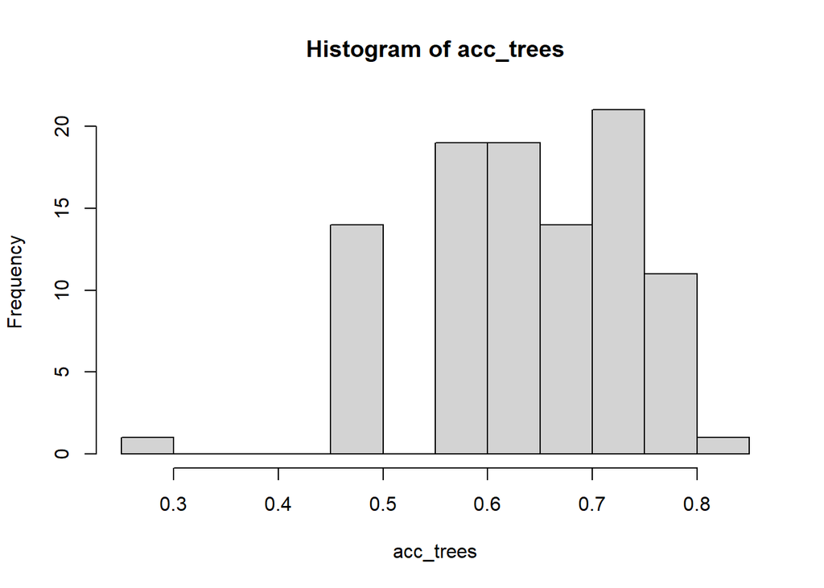

```r
# acc
acc_trees <- acc[1,]
hist(acc_trees)
```

```r
mean(acc_trees)
```

```
## [1] 0.6333333
```

```r
median(acc_trees)
```

```
## [1] 0.6111111
```

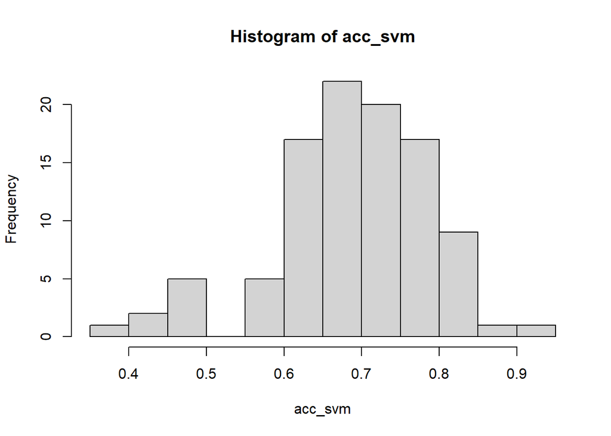

```r
acc_svm <- acc[2,]
hist(acc_svm)
```

```r
mean(acc_svm)
```

```
## [1] 0.6861111
```

```r
median(acc_svm)
```

```
## [1] 0.6666667
```

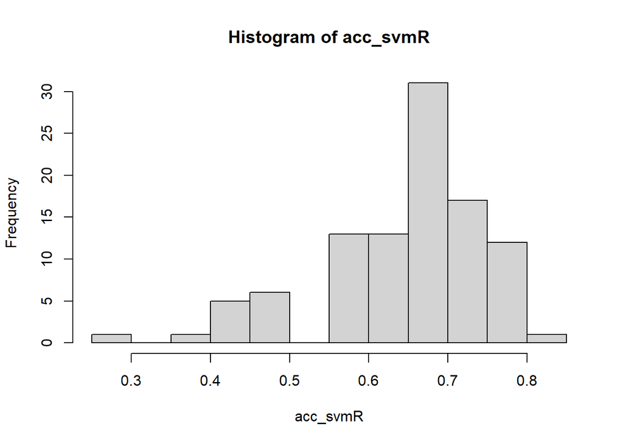

```r
acc_svmR <- acc[3,]
hist(acc_svmR)
```

```r
mean(acc_svmR)
```

```
## [1] 0.6416667
```

```r
median(acc_svmR)
```

```
## [1] 0.6666667
```

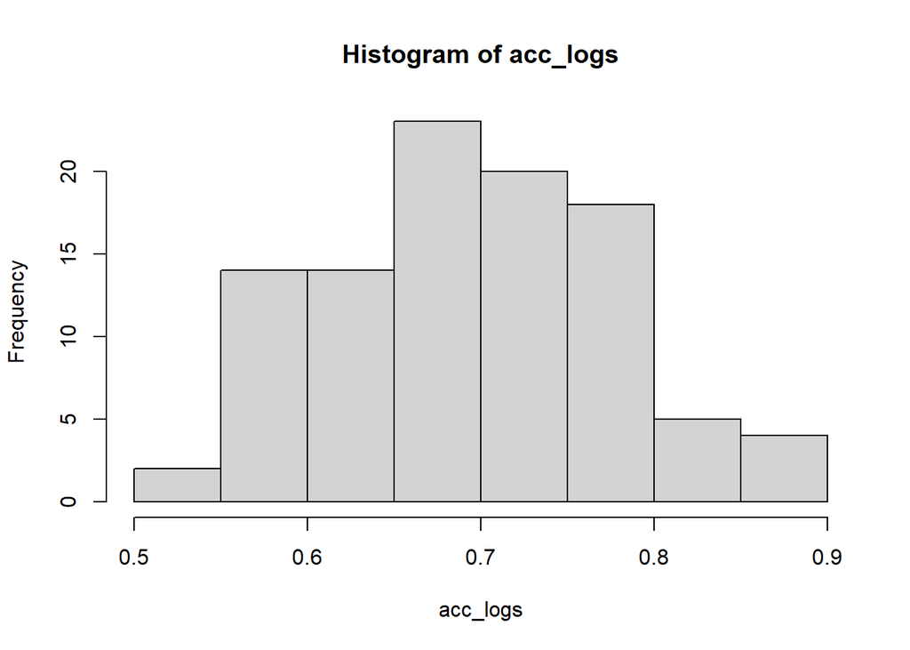

```r
acc_logs <- acc[4,]
hist(acc_logs)
```

```r
mean(acc_logs)
```

```
## [1] 0.6883333
```

```r
median(acc_logs)
```

```
## [1] 0.6666667
```

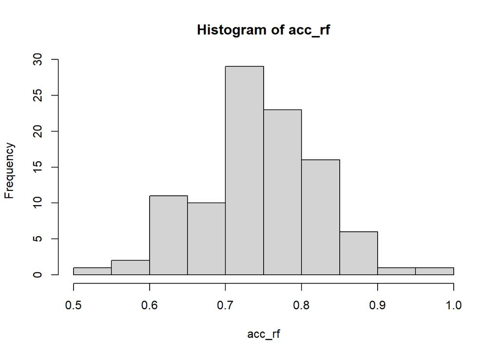

```r
acc_rf <- acc[5,]
hist(acc_rf)
```

```r
mean(acc_rf)
```

```
## [1] 0.7444444
```

```r
median(acc_rf)
```

```
## [1] 0.7222222
```

- Misclassification

```r
# miscl
miscl_trees <- miscl[1,]
#hist(miscl_trees)
mean(miscl_trees)
```

```
## [1] 6.6
```

```r
median(miscl_trees)
```

```
## [1] 7
```

```r
miscl_svm <- miscl[2,]
#hist(miscl_svm)
mean(miscl_svm)
```

```
## [1] 5.65
```

```r
median(miscl_svm)
```

```
## [1] 6
```

```r
miscl_svmR <- miscl[3,]
#hist(miscl_svmR)
mean(miscl_svmR)
```

```
## [1] 6.45
```

```r
median(miscl_svmR)
```

```
## [1] 6
```

```r
miscl_logs <- miscl[4,]
#hist(miscl_logs)
mean(miscl_logs)
```

```
## [1] 5.61
```

```r
median(miscl_logs)
```

```
## [1] 6
```

```r
miscl_rf <- miscl[5,]
#hist(miscl_rf)
mean(miscl_rf)
```

```
## [1] 4.6
```

```r
median(miscl_rf)
```

```
## [1] 5
```

- Sensitivity

```r
# sensitivity
sensitivity_trees <- sensitivity[1,]
sensitivity_trees <- na.omit(sensitivity_trees)
#hist(sensitivity_trees)
mean(sensitivity_trees)
```

```
## [1] 0.6320629
```

```r
median(sensitivity_trees)
```

```
## [1] 0.6201923
```

```r
sensitivity_svm <- sensitivity[2,]
sensitivity_svm <- na.omit(sensitivity_svm)
#hist(sensitivity_svm)
mean(sensitivity_svm)
```

```
## [1] 0.7351181
```

```r
median(sensitivity_svm)
```

```
## [1] 0.7142857
```

```r
sensitivity_svmR <- sensitivity[3,]
sensitivity_svmR <- na.omit(sensitivity_svmR)
#hist(sensitivity_svmR)
mean(sensitivity_svmR)
```

```
## [1] 0.64247
```

```r
median(sensitivity_svmR)
```

```
## [1] 0.6363636
```

```r
sensitivity_logs <- sensitivity[4,]

sensitivity_logs <- na.omit(sensitivity_logs)
#hist(sensitivity_logs)
mean(sensitivity_logs)
```

```
## [1] 0.704446
```

```r
median(sensitivity_logs)
```

```
## [1] 0.6666667
```

```r
sensitivity_rf <- sensitivity[5,]
sensitivity_rf <- na.omit(sensitivity_rf)
#hist(sensitivity_rf)
mean(sensitivity_rf)
```

```
## [1] 0.7679991
```

```r
median(sensitivity_rf)
```

```
## [1] 0.75
```

- Specificity

```r
# specificity
specificity_trees <- specificity[1,]
specificity_trees <- na.omit(specificity_trees)
#hist(specificity_trees)
mean(specificity_trees)
```

```
## [1] 0.6603575
```

```r
median(specificity_trees)
```

```
## [1] 0.6666667
```

```r
specificity_svm <- specificity[2,]
specificity_svm <- na.omit(specificity_svm)
#hist(specificity_svm)
mean(specificity_svm)
```

```
## [1] 0.6884565
```

```r
median(specificity_svm)
```

```
## [1] 0.6666667
```

```r
specificity_svmR <- specificity[3,]
specificity_svmR <- na.omit(specificity_svmR)
#hist(specificity_svmR)
mean(specificity_svmR)
```

```
## [1] 0.6873526
```

```r
median(specificity_svmR)
```

```
## [1] 0.6666667
```

```r
specificity_logs <- specificity[4,]
specificity_logs <- na.omit(specificity_logs)
#hist(specificity_logs)
mean(specificity_logs)
```

```
## [1] 0.697618
```

```r
median(specificity_logs)
```

```
## [1] 0.6923077
```

```r
specificity_rf <- specificity[5,]
specificity_rf <- na.omit(specificity_rf)
#hist(specificity_rf)
mean(specificity_rf)
```

```
## [1] 0.7431117
```

```r
median(specificity_rf)
```

```
## [1] 0.7386364
```

- False Neg

```r
# fneg
fneg_trees <- fneg[1,]
#hist(fneg_trees)
mean(fneg_trees)
```

```
## [1] 2.93
```

```r
median(fneg_trees)
```

```
## [1] 3
```

```r
fneg_svmL <- fneg[2,]
#hist(fneg_svmL)
mean(fneg_svmL)
```

```
## [1] 3.16
```

```r
median(fneg_svmL)
```

```
## [1] 3
```

```r
fneg_svmR <- fneg[3,]
#hist(fneg_svmR)
mean(fneg_svmR)
```

```
## [1] 2.62
```

```r
median(fneg_svmR)
```

```
## [1] 3
```

```r
fneg_logs <- fneg[4,]
#hist(fneg_logs)
mean(fneg_logs)
```

```
## [1] 2.82
```

```r
median(fneg_logs)
```

```
## [1] 3
```

```r
fneg_rf <- fneg[5,]
#hist(fneg_rf)
mean(fneg_rf)
```

```
## [1] 2.47
```

```r
median(fneg_rf)
```

```
## [1] 2.5
```

#### 3.1.4.2 2) Classification with regularization (EN and iTwiner)

```r
xdata <- xdataT[, ! apply(xdataT , 2 , function(x) sd(x)==0 ) ]


ydata.raw <- as.data.frame(clinic1$class)
ydata.raw$row <- DATASET1$ID
#
# # ydata.raw$class <- c(rep(0,28),rep(1,34))
#
ydata.raw$`clinic1$class`[ydata.raw$`clinic1$class` == "P"] <- 0
ydata.raw$`clinic1$class`[ydata.raw$`clinic1$class` == "Pm"] <- 1
rownames(ydata.raw) <- DATASET1$ID

xdata <- xdata[rownames(xdata) %in%
                         rownames(ydata.raw),]

ydata.raw <- as.data.frame(ydata.raw[rownames(ydata.raw) %in%
                         rownames(xdata),])

xdata <- xdata[ order(row.names(xdata)), ]

ydata.raw <- ydata.raw[ order(row.names(ydata.raw)), ]



ydata <- as.data.frame(ydata.raw)
ydata$`clinic1$class` <- as.numeric(ydata$`clinic1$class`)
```

```r
times_boot <- 1000

nvar_selected_1 <- matrix(0,2,times_boot)

var_selected_en1 <- vector("list")
var_selected_iTwiner1 <- vector("list")

acc_cox_tr <- matrix(0,2,times_boot)
acc_cox_tes <- matrix(0,2,times_boot)
kappa_cox_tr <- matrix(0,2,times_boot)
kappa_cox_tes <- matrix(0,2,times_boot)
sensitivity_cox_tr <- matrix(0,2,times_boot)
sensitivity_cox_tes <- matrix(0,2,times_boot)
specificity_cox_tr <- matrix(0,2,times_boot)
specificity_cox_tes <- matrix(0,2,times_boot)
miscl_cox_tr <- matrix(0,2,times_boot)
miscl_cox_tes <- matrix(0,2,times_boot)


fpos_reg <- matrix(0,2,times_boot)
fneg_reg <- matrix(0,2,times_boot)

ids_fn_en <- vector("list")
ids_fn_iTwiner <- vector("list")


ids_fp_en <- vector("list")
ids_fp_iTwiner <- vector("list")

run = 1000

i=1
l1=0
while(l1 < 100){

  print(l1)
  print(i)
  run = run + 11
  set.seed(run)
  print(run)

  ixs <- loose.rock::balanced.train.and.test(which(as.logical(ydata$`clinic1$class`)), which(as.logical(!ydata$`clinic1$class` )), train.perc = 0.7)
  xtrain <- xdata[ixs$train,]
  ytrain <- ydata[ixs$train,1]

  xtest <- xdata[ixs$test,]
  ytest <- ydata[ixs$test,1]

  print("data")

  xtrain <- as.matrix(xtrain)
  xtest <- as.matrix(xtest)


# Classification by sparse logistic regression

## with the elastic net (EN) penalty

  fit_EN1 <- cv.glmnet(as.matrix(xtrain), as.factor(ytrain), family="binomial", nfolds=10, alpha=0.2,
                       #foldid=my_foldid,
                       type.measure="mse")

  var_selected <- which(fit_EN1$glmnet.fit$beta[,which(fit_EN1$cvm == min(fit_EN1$cvm))] != 0)

  nvar_selected_1[1,i] <- length(var_selected)


  var_selected_en1[[i]] <- names(var_selected)



  if (length(var_selected) > 1){

    # results

    ##train
    resp_train <- as.data.frame(predict(fit_EN1, s = 'lambda.min', newx = xtrain, type = 'class'))
    resp_train <- resp_train[,1]

    if (length(which(resp_train == 0)) == 0 | length(which(resp_train == 1)) == 0){

      print("en train ups")} else{

        t <- table(ytrain,resp_train)
        result <- confusionMatrix(t)

        acc_cox_tr[1,i] <- result[["overall"]][["Accuracy"]]
        kappa_cox_tr[1,i] <- result[["overall"]][["Kappa"]]
        sensitivity_cox_tr[1,i] <- result[["byClass"]][["Sensitivity"]]
        specificity_cox_tr[1,i] <- result[["byClass"]][["Specificity"]]
        miscl_cox_tr[1,i] <- t[1,2]+t[2,1]

        rm(var_selected,resp_train,t,result)
      }



    ## test
    pred <- as.data.frame(predict(fit_EN1, s = 'lambda.min', newx = xtest, type = 'class'))
    pred <- pred[,1]

    if (length(which(pred == 0)) == 0 | length(which(pred == 1)) == 0){

      print("en pred ups")} else{

        t <- table(ytest,pred)
        result <- confusionMatrix(t)

        acc_cox_tes[1,i] <- result[["overall"]][["Accuracy"]]
        kappa_cox_tes[1,i] <- result[["overall"]][["Kappa"]]
        sensitivity_cox_tes[1,i] <- result[["byClass"]][["Sensitivity"]]
        specificity_cox_tes[1,i] <- result[["byClass"]][["Specificity"]]
        miscl_cox_tes[1,i] <- t[1,2]+t[2,1]

      }

    true <- ytest

    listafp <- c()
    listafn <- c()

    for (a in which(pred!= true)){

      if (pred[a] == 0) {

        listafp <- c(listafp, a)
      } else {
        listafn <- c(listafn, a)
      }
    }

    fpos_reg[1,i] <- length(listafp)
    fneg_reg[1,i] <- length(listafn)
    ids_fn_en[[i]] <- rownames(xtest[listafn,])
    ids_fp_en[[i]] <- rownames(xtest[listafp,])


    print("EN")} else{
      print("EN não selecionou variaveis")
    }

  rm(pred,t,result)


  i=i+1


  rm(xtrain,xtest,ytrain,ytest,ytest)

  l1 <- length(which(acc_cox_tr[1,]!=0))

}
```

```r
i=1
l2=0
while(l2 < 100){

  print(i)
  print(l2)
  run = run + 11
  set.seed(run)
  print(run)

  ixs <- loose.rock::balanced.train.and.test(which(as.logical(ydata$`clinic1$class`)), which(as.logical(!ydata$`clinic1$class` )), train.perc = 0.7)
  xtrain <- xdata[ixs$train,]
  ytrain <- ydata[ixs$train,1]

  xtest <- xdata[ixs$test,]
  ytest <- ydata[ixs$test,1]

  print("data")

  xtrain <- as.matrix(xtrain)
  xtest <- as.matrix(xtest)


## with network information - iTwiner

  fit_tco1 <- cv.glmnet(as.matrix(xtrain), as.factor(ytrain), family="binomial", nfolds=10, alpha=0.05 ,
                        #foldid=my_foldid,
                        penalty.factor = pen_weight1,
                        type.measure="mse")

  var_selected <- which(fit_tco1$glmnet.fit$beta[,which(fit_tco1$cvm == min(fit_tco1$cvm))] != 0)

  nvar_selected_1[2,i] <- length(var_selected)


  var_selected_iTwiner1[[i]] <- names(var_selected)

  if (length(var_selected) > 1){
    # results

    ##train
    resp_train <- as.data.frame(predict(fit_tco1, s = 'lambda.min', newx = xtrain, type = 'class'))
    resp_train <- resp_train[,1]

    if (length(which(resp_train == 0)) == 0 | length(which(resp_train == 1)) == 0){

      print("iTwiner train ups")} else{

        t <- table(ytrain,resp_train)
        result <- confusionMatrix(t)

        acc_cox_tr[2,i] <- result[["overall"]][["Accuracy"]]
        kappa_cox_tr[2,i] <- result[["overall"]][["Kappa"]]
        sensitivity_cox_tr[2,i] <- result[["byClass"]][["Sensitivity"]]
        specificity_cox_tr[2,i] <- result[["byClass"]][["Specificity"]]
        miscl_cox_tr[2,i] <- t[1,2]+t[2,1]

        rm(var_selected,resp_train,t,result)

      }



    ## test
    pred <- as.data.frame(predict(fit_tco1, s = 'lambda.min', newx = xtest, type = 'class'))
    pred <- pred[,1]

    if (length(which(pred == 0)) == 0 | length(which(pred == 1)) == 0){

      print("iTwiner test ups")} else{

        t <- table(ytest,pred)
        result <- confusionMatrix(t)

        acc_cox_tes[2,i] <- result[["overall"]][["Accuracy"]]
        kappa_cox_tes[2,i] <- result[["overall"]][["Kappa"]]
        sensitivity_cox_tes[2,i] <- result[["byClass"]][["Sensitivity"]]
        specificity_cox_tes[2,i] <- result[["byClass"]][["Specificity"]]
        miscl_cox_tes[2,i] <- t[1,2]+t[2,1]

      }

    true <- ytest

    listafp <- c()
    listafn <- c()

    for (a in which(pred!= true)){

      if (pred[a] == 0) {

        listafp <- c(listafp, a)
      } else {
        listafn <- c(listafn, a)
      }
    }

    fpos_reg[2,i] <- length(listafp)
    fneg_reg[2,i] <- length(listafn)
    ids_fn_iTwiner[[i]] <- rownames(xtest[listafn,])
    ids_fp_iTwiner[[i]] <- rownames(xtest[listafp,])



    print("iTwiner")

  } else{
    print("iTwiner não correu")
  }

    rm(xtrain,xtest,ytrain,ytest,ytest)
    l2 <- length(which(acc_cox_tr[2,]!=0))
    i=i+1
    }
```

##### 3.1.4.2.1 Measures of model performance

```r
runs_en <- which(acc_cox_tr[1,]!=0)
runs_itw <- which(acc_cox_tr[2,]!=0)
```

- Accuracy

```r
# EN train
acc_cox_tr_EN <- acc_cox_tr[1,]
acc_cox_tr_EN <- acc_cox_tr_EN[runs_en]
#hist(acc_cox_tr_EN)
mean(acc_cox_tr_EN)
```

```
## [1] 0.867381
```

```r
median(acc_cox_tr_EN)
```

```
## [1] 0.8571429
```

```r
# EN test
acc_cox_tes_EN <- acc_cox_tes[1,]
acc_cox_tes_EN <- acc_cox_tes_EN[runs_en]
#hist(acc_cox_tes_EN)
mean(acc_cox_tes_EN)
```

```
## [1] 0.6833333
```

```r
median(acc_cox_tes_EN)
```

```
## [1] 0.6666667
```

```r
#iTwiner train
acc_cox_tr_iTwiner <- acc_cox_tr[2,]
acc_cox_tr_iTwiner <- acc_cox_tr_iTwiner[runs_itw]
#hist(acc_cox_tr_iTwiner)
mean(acc_cox_tr_iTwiner)
```

```
## [1] 0.8511905
```

```r
median(acc_cox_tr_iTwiner)
```

```
## [1] 0.8571429
```

```r
#iTwiner test
acc_cox_tes_iTwiner <- acc_cox_tes[2,]
acc_cox_tes_iTwiner <- acc_cox_tes_iTwiner[runs_itw]
#hist(acc_cox_tes_iTwiner)
mean(acc_cox_tes_iTwiner)
```

```
## [1] 0.7938889
```

```r
median(acc_cox_tes_iTwiner)
```

```
## [1] 0.7777778
```

- miscl

```r
#EN train
miscl_cox_tr_EN <- miscl_cox_tr[1,]
miscl_cox_tr_EN <- miscl_cox_tr_EN[runs_en]
#hist(miscl_cox_tr_EN)
mean(miscl_cox_tr_EN)
```

```
## [1] 5.57
```

```r
median(miscl_cox_tr_EN)
```

```
## [1] 6
```

```r
#EN test
miscl_cox_tes_EN <- miscl_cox_tes[1,]
miscl_cox_tes_EN <- miscl_cox_tes_EN[runs_en]
#hist(miscl_cox_tes_EN)
mean(miscl_cox_tes_EN)
```

```
## [1] 5.7
```

```r
median(miscl_cox_tes_EN)
```

```
## [1] 6
```

```r
#iTwiner train
miscl_cox_tr_iTwiner <- miscl_cox_tr[2,]
miscl_cox_tr_iTwiner <- miscl_cox_tr_iTwiner[runs_itw]
#hist(miscl_cox_tr_iTwiner)
mean(miscl_cox_tr_iTwiner)
```

```
## [1] 6.25
```

```r
median(miscl_cox_tr_iTwiner)
```

```
## [1] 6
```

```r
#iTwiner test
miscl_cox_tes_iTwiner <- miscl_cox_tes[2,]
miscl_cox_tes_iTwiner <- miscl_cox_tes_iTwiner[runs_itw]
#hist(miscl_cox_tes_iTwiner)
mean(miscl_cox_tes_iTwiner)
```

```
## [1] 3.71
```

```r
median(miscl_cox_tes_iTwiner)
```

```
## [1] 4
```

- sensitivity

```r
#EN train
sensitivity_cox_tr_EN <- sensitivity_cox_tr[1,]
sensitivity_cox_tr_EN <- sensitivity_cox_tr_EN[runs_en]
#hist(sensitivity_cox_tr_EN)
mean(sensitivity_cox_tr_EN)
```

```
## [1] 0.9891654
```

```r
median(sensitivity_cox_tr_EN)
```

```
## [1] 1
```

```r
#EN test
sensitivity_cox_tes_EN <- sensitivity_cox_tes[1,]
sensitivity_cox_tes_EN <- sensitivity_cox_tes_EN[runs_en]
#hist(sensitivity_cox_tes_EN)
mean(sensitivity_cox_tes_EN)
```

```
## [1] 0.7067372
```

```r
median(sensitivity_cox_tes_EN)
```

```
## [1] 0.6666667
```

```r
#iTwiner train
sensitivity_cox_tr_iTwiner <- sensitivity_cox_tr[2,]
sensitivity_cox_tr_iTwiner <- sensitivity_cox_tr_iTwiner[runs_itw]
#hist(sensitivity_cox_tr_iTwiner)
mean(sensitivity_cox_tr_iTwiner)
```

```
## [1] 1
```

```r
median(sensitivity_cox_tr_iTwiner)
```

```
## [1] 1
```

```r
#iTwiner test
sensitivity_cox_tes_iTwiner <- sensitivity_cox_tes[2,]
sensitivity_cox_tes_iTwiner <- sensitivity_cox_tes_iTwiner[runs_itw]
#hist(sensitivity_cox_tes_iTwiner)
mean(sensitivity_cox_tes_iTwiner)
```

```
## [1] 0.9874643
```

```r
median(sensitivity_cox_tes_iTwiner)
```

```
## [1] 1
```

- specificity

```r
#EN train
specificity_cox_tr_EN <- specificity_cox_tr[1,]
specificity_cox_tr_EN <- specificity_cox_tr_EN[runs_en]
#hist(specificity_cox_tr_EN)
mean(specificity_cox_tr_EN)
```

```
## [1] 0.7961835
```

```r
median(specificity_cox_tr_EN)
```

```
## [1] 0.7847222
```

```r
#EN test
specificity_cox_tes_EN <- specificity_cox_tes[1,]
specificity_cox_tes_EN <- specificity_cox_tes_EN[runs_en]
#hist(specificity_cox_tes_EN)
mean(specificity_cox_tes_EN)
```

```
## [1] 0.6779234
```

```r
median(specificity_cox_tes_EN)
```

```
## [1] 0.6666667
```

```r
#iTwiner train
specificity_cox_tr_iTwiner <- specificity_cox_tr[2,]
specificity_cox_tr_iTwiner <- specificity_cox_tr_iTwiner[runs_itw]
#hist(specificity_cox_tr_iTwiner)
mean(specificity_cox_tr_iTwiner)
```

```
## [1] 0.7721859
```

```r
median(specificity_cox_tr_iTwiner)
```

```
## [1] 0.7777778
```

```r
#iTwiner test
specificity_cox_tes_iTwiner <- specificity_cox_tes[2,]
specificity_cox_tes_iTwiner <- specificity_cox_tes_iTwiner[runs_itw]
#hist(specificity_cox_tes_iTwiner)
mean(specificity_cox_tes_iTwiner)
```

```
## [1] 0.7195523
```

```r
median(specificity_cox_tes_iTwiner)
```

```
## [1] 0.6923077
```

- False Neg

```r
#EN
fneg_reg_en <- fneg_reg[1,nvar_en]
#hist(fneg_reg_en)
mean(fneg_reg_en)
```

```
## [1] 2.66
```

```r
median(fneg_reg_en)
```

```
## [1] 3
```

```r
#iTwiner
fneg_reg_iTwiner <- fneg_reg[2,nvar_tw]
#hist(fneg_reg_iTwiner)
mean(fneg_reg_iTwiner)
```

```
## [1] 3.68
```

```r
median(fneg_reg_iTwiner)
```

```
## [1] 4
```

- number variables selected

```r
# median number of variables selected
nvar_en <- nvar_selected_1[1,]
nvar_en <- nvar_en[runs_en]
mean(nvar_en)
```

```
## [1] 66.97
```

```r
median(nvar_en)
```

```
## [1] 59
```

```r
nvar_tw <- nvar_selected_1[2,]
nvar_tw <- nvar_tw[runs_itw]
mean(nvar_tw)
```

```
## [1] 36.54
```

```r
median(nvar_tw)
```

```
## [1] 33
```

##### 3.1.4.2.2 Names of genes selected

Variables always selected

```r
var_selected_alw_select_en <- var_selected_en1[runs_en]
var_selected_alw_select_en1 <-  Reduce(intersect,var_selected_alw_select_en)
print(paste("variables always selected by EN = ",length(var_selected_alw_select_en1)))
```

```
## [1] "variables always selected by EN =  0"
```

```r
var_selected_alw_select_iTwiner <- var_selected_iTwiner1[runs_itw]
var_selected_alw_select_iTwiner1 <-  Reduce(intersect,var_selected_alw_select_iTwiner)
print(paste("variables always selected by iTwiner = ",length(var_selected_alw_select_iTwiner1)))
```

```
## [1] "variables always selected by iTwiner =  2"
```

Variables selected in 50 bootstrap samples

```r
l = length(var_selected_alw_select_en)
var_selected_50_select_en <- table(unlist(var_selected_alw_select_en))
var_selected_50_select_en <- as.data.frame(var_selected_50_select_en)
var_selected_50_select_en <-  subset(var_selected_50_select_en, Freq > 0.50*l)
print(paste("variables selected 50% by EN = ",length(var_selected_50_select_en$Var1)))
```

```
## [1] "variables selected 50% by EN =  8"
```

```r
var_selected_50_select_en$Var1
```

```
## [1] CD8B      LINC01871 PF4       RPL6P9    SFRP5     SLITRK1   SOHLH2
## [8] XRCC6P2
## 1815 Levels: AASDHPPT ABCC12 ABCD1P4 ABCE1 ABCF2-H2BE1 ABHD15 ABHD6 ACLY ... ZWINT
```

```r
#
l = length(var_selected_alw_select_iTwiner)
var_selected_50_select_iTwiner <- table(unlist(var_selected_alw_select_iTwiner))
var_selected_50_select_iTwiner <- as.data.frame(var_selected_50_select_iTwiner)
var_selected_50_select_iTwiner <-  subset(var_selected_50_select_iTwiner, Freq > 0.50*l)
print(paste("variables selected 50% by iTwiner = ",length(var_selected_50_select_iTwiner$Var1)))
```

```
## [1] "variables selected 50% by iTwiner =  19"
```

```r
var_selected_50_select_iTwiner$Var1
```

```
##  [1] COX6CP7    EEF1B2P6   FABP7P2    HNRNPA1P42 HSPD1P7    IGKV2D-30
##  [7] KDM4F      LILRB1-AS1 LINC01100  LINC01335  MTCO2P18   OR51K1P
## [13] RAC1P3     RPL31P35   RPL7P58    SULT6B2P   TRAJ20     TRBV11-1
## [19] XRCC6P2
## 236 Levels: ACTN4P1 AGTR2 ALOX15P2 AMMECR1LP1 ANKRD20A10P APOOP4 ... XRCC6P2
```

- Select the 50 most frequent variables

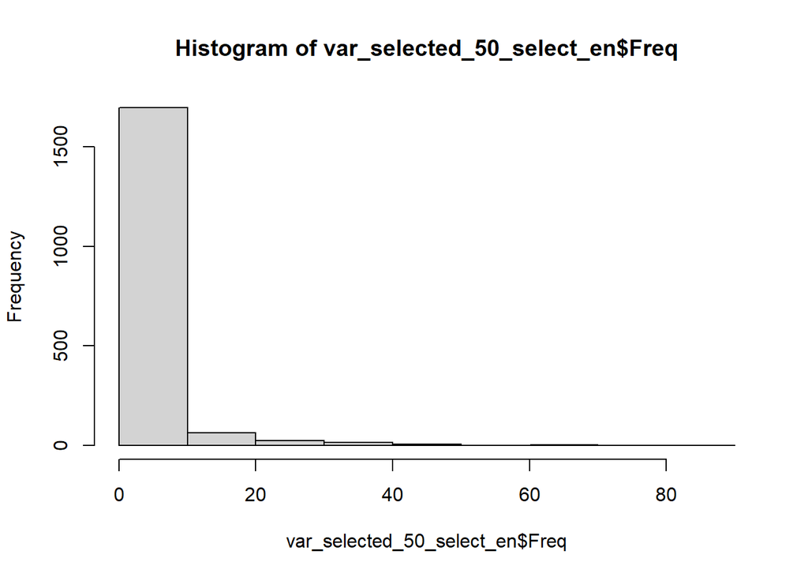

```r
var_selected_50_select_en <- table(unlist(var_selected_alw_select_en))
var_selected_50_select_en <- as.data.frame(var_selected_50_select_en)
var_selected_50_select_en <- var_selected_50_select_en[order(var_selected_50_select_en$Freq, decreasing = T),]
write_xlsx(var_selected_50_select_en,"genes_en_d1.xlsx")
hist(var_selected_50_select_en$Freq)
```

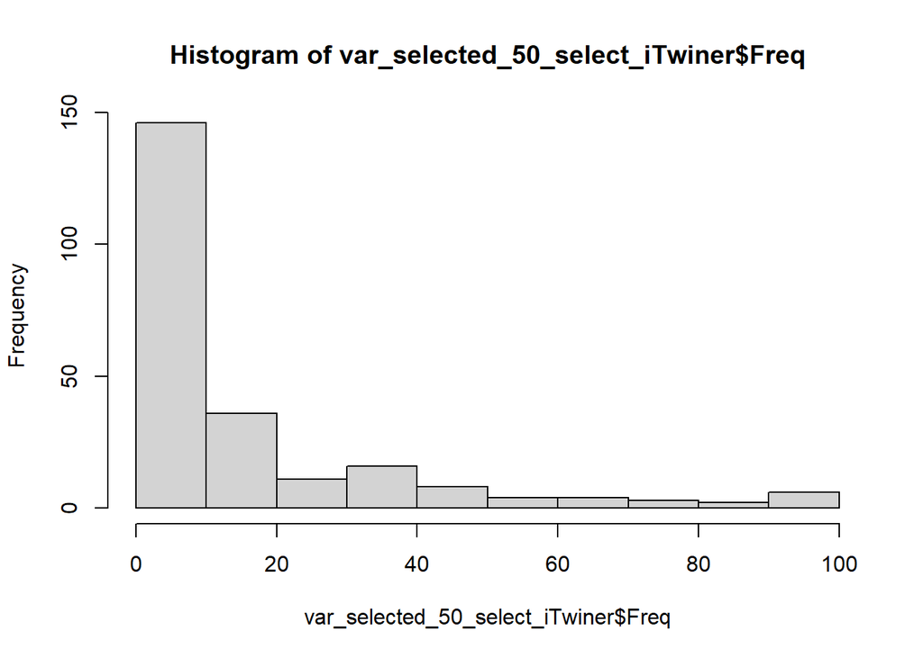

```r
top100_en <- var_selected_50_select_en[1:100,]
top100_en <- top100_en$Var1
top50_en <- top100_en[1:50]


var_selected_50_select_iTwiner <- table(unlist(var_selected_alw_select_iTwiner))
var_selected_50_select_iTwiner <- as.data.frame(var_selected_50_select_iTwiner)
var_selected_50_select_iTwiner <- var_selected_50_select_iTwiner[order(var_selected_50_select_iTwiner$Freq, decreasing = T),]
write_xlsx(var_selected_50_select_iTwiner,"genes_itw_d1.xlsx")
hist(var_selected_50_select_iTwiner$Freq)
```

```r
top100_itw <- var_selected_50_select_iTwiner[1:100,]
top100_itw <- top100_itw$Var1
top50_itw <- top100_itw[1:50]
```

variables in common between EN and iTwiner

```r
common_var_selected_50_en_iTwiner <- var_selected_50_select_iTwiner$Var1[which(var_selected_50_select_iTwiner$Var1 %in% var_selected_50_select_en$Var1)]
length(common_var_selected_50_en_iTwiner)
```

```
## [1] 44
```

```r
common_var_selected_50_en_iTwiner
```

```
##  [1] RAC1P3     XRCC6P2    OR51K1P    LINC01100  EEF1B2P6   HSPD1P7
##  [7] FABP7P2    RPL31P35   COX6CP7    TRAJ20     RNU6-1085P MIR8052
## [13] TRBJ2-1    DNAJC19P3  RNU6-337P  TRAJ61     MIR6816    TIMM8AP1
## [19] TRAJ25     MTCO3P42   RNU4-39P   TMSB4XP1   HNRNPCL1   LINC02178
## [25] EIF4EP3    IGHJ1      MIR193B    MIR4439    TRAJ28     ATP5MGP5
## [31] ATP6V1E1P2 MIR1288    MIR564     MIRLET7A2  MIR4254    BCRP7
## [37] GDI2P1     ISCA1P3    MIR409     PMPCAP1    RNA5SP74   RNU6-865P
## [43] RNU6ATAC7P SYCN
## 236 Levels: ACTN4P1 AGTR2 ALOX15P2 AMMECR1LP1 ANKRD20A10P APOOP4 ... XRCC6P2
```

- Variables selected by EN and iTwiner that are DEGs

```r
xdata <- rnaseq1[ order(row.names(rnaseq1)), ]

nomesgenes <- c(as.vector(top50_en),as.vector(top50_itw))
xdata <- xdata[,nomesgenes]
rownames(DATASET1_bal) <- DATASET1_bal$ID
ydata <- as.data.frame(DATASET1_bal[ order(row.names(DATASET1_bal)), ])
rownames(ydata) <- ydata$ID

xdata <- xdata[rownames(xdata) %in%
                 rownames(ydata),]
ydata <- as.data.frame(ydata[rownames(ydata) %in%
                               rownames(xdata),])

# keep features with standard deviation > 0
xdata <- xdata[,sapply(seq(ncol(xdata)), function(ix) {sd(xdata[,ix])}) != 0]
xdata <- t(xdata)

group <- as.factor(ydata$class)
class <- as.data.frame(ydata$class)
```

```r
edgeR.DGElist <- DGEList(counts=xdata, group = group)

# remove genes that do not have one count per million in at least 5 samples
keep <- rowSums(cpm(edgeR.DGElist) >= 1) >= 5
edgeR.DGElist <- edgeR.DGElist[keep ,]

# specify the design setup

design <- model.matrix(~group)

# estimate the dispersion for all read counts across all samples
edgeR.DGElist <- estimateDisp(edgeR.DGElist, design)

# fit the negative binomial model
edger_fit <- glmFit(edgeR.DGElist, design )

# perform the testing for every gene using the neg. binomial model
edger_lrt <- glmLRT(edger_fit)
summary(decideTests(edger_lrt))
```

```
##        groupPm
## Down         4
## NotSig      93
## Up           3
```

```r
# extract results from edger _lrt$ table plus adjusted p- values
DGE.results_edgeR <- topTags(edger_lrt, n = Inf , sort.by = "PValue" , adjust.method = "BH" )

topTags(DGE.results_edgeR) #table with the top10 DEGs
```

```
## Coefficient:  groupPm
##                 logFC    logCPM        LR       PValue          FDR
## MIR8052     2.7372046  6.009474 19.669113 9.207769e-06 0.0006421211
## RNU6-337P   3.2286673  6.017764 19.033788 1.284242e-05 0.0006421211
## RAC1P3     -2.9946864  6.419308 13.309733 2.640319e-04 0.0066007975
## RAC1P3.1   -2.9946864  6.419308 13.309733 2.640319e-04 0.0066007975
## XRCC6P2    -3.3430257  6.364429 10.601001 1.130265e-03 0.0188377469
## XRCC6P2.1  -3.3430257  6.364429 10.601001 1.130265e-03 0.0188377469
## RNU6-1266P  3.1010187  7.350505  9.753307 1.790004e-03 0.0255714897
## MGST1       0.6999765 16.087821  6.929356 8.479222e-03 0.1059902710
## MIR7107     2.8806668  7.217542  6.048031 1.392181e-02 0.1546868129
## EEF1B2P6   -2.0438206  6.049605  5.732342 1.665525e-02 0.1612076403
```

```r
genes_deg <- DGE.results_edgeR$table
genes_deg <- genes_deg[which(genes_deg$FDR < 0.05),]
dim(genes_deg)#genes found to be differentially expressed
```

```
## [1] 7 5
```

```r
genes_deg$row <- row.names(genes_deg)
write_xlsx(genes_deg,"genes_deg_enitw_d1.xlsx")


# highly expressed genes
high <- genes_deg[genes_deg$logFC > 0,]
dim(high)
```

```
## [1] 3 6
```

```r
#low expressed genes
low <- genes_deg[genes_deg$logFC < 0,]
dim(low)
```

```
## [1] 4 6
```

#### 3.1.4.3 3) Classification based on genes selected by regularized logistic regression

##### 3.1.4.3.1 EN + Classifiers

```r
xdata <- xdataT


ydata.raw <- as.data.frame(clinic1$class)
ydata.raw$row <- DATASET1$ID

#ydata.raw$class <- c(rep(0,28),rep(1,34))

ydata.raw$`clinic1$class`[ydata.raw$`clinic1$class` == "P"] <- 0
ydata.raw$`clinic1$class`[ydata.raw$`clinic1$class` == "Pm"] <- 1
rownames(ydata.raw) <- DATASET1$ID

xdata <- xdata[rownames(xdata) %in%
                         rownames(ydata.raw),]

ydata.raw <- as.data.frame(ydata.raw[rownames(ydata.raw) %in%
                         rownames(xdata),])

xdata <- xdata[ order(row.names(xdata)), ]

ydata.raw <- ydata.raw[ order(row.names(ydata.raw)), ]



ydata <- as.data.frame(ydata.raw[,1:2])
colnames(ydata) <- c("class","id")

names <- as.vector(top50_en)
xdata_en <- as.data.frame(xdata[,names])

nomesgenes <- colnames(xdata_en)
colnames(xdata_en) <- paste0("Var", 1:50)
xdata_en$type <- as.factor(ydata$class)
ydata$class <- as.numeric(ydata$class)
```

```r
times_boot <- 100

acc_enplus <- matrix(0,5,times_boot)
kappa_enplus<- matrix(0,5,times_boot)
sensitivity_enplus<- matrix(0,5,times_boot)
specificity_enplus <- matrix(0,5,times_boot)
miscl_enplus <- matrix(0,5,times_boot)
fpos_enplus <- matrix(0,5,times_boot)
fneg_enplus <- matrix(0,5,times_boot)

ids_fn_tree1_enplus <- vector("list")
ids_fn_svmL1_enplus <- vector("list")
ids_fn_svmR1_enplus <- vector("list")
ids_fn_logist1_enplus <- vector("list")
ids_fn_rf1_enplus <- vector("list")

ids_fp_tree1_enplus <- vector("list")
ids_fp_svmL1_enplus <- vector("list")
ids_fp_svmR1_enplus <- vector("list")
ids_fp_logist1_enplus <- vector("list")
ids_fp_rf1_enplus <- vector("list")



run = 1000


for (i in 1:times_boot){

  print(i)
  run = run + 11
  set.seed(run)
  print(run)

  ixs <- loose.rock::balanced.train.and.test(which(as.logical(ydata$class)), which(as.logical(!ydata$class)), train.perc = 0.7)

  training <- xdata_en[ixs$train,]
  testing <- xdata_en[ixs$test,]




# Classification - fazer todos com cross validation

## Decision tree
# Fit the model on the training set



  control <- rpart.control(minsplit = 4)

  model2 <- rpart(type~., data = training, method = 'class', control = control)

  # Make predictions on the test data
  pred <- model2 %>% predict(testing, type = "class")

  true <- testing$type

  listafp <- c()
  listafn <- c()

  for (a in which(pred!= true)){

    if (pred[a] == 0) {

      listafp <- c(listafp, a)
    } else {
      listafn <- c(listafn, a)
    }
  }

  fpos_enplus[1,i] <- length(listafp)
  fneg_enplus[1,i] <- length(listafn)
  ids_fn_tree1_enplus[[i]] <- rownames(testing[listafn,])
  ids_fp_tree1_enplus[[i]] <- rownames(testing[listafp,])


  # tree <- rpart(type~., data=training, method = "class")
  #
  # #Testing the model
  # pred <- predict(object=tree,testing,type="class")

  #Calculating accuracy
  t <- table(testing$type,pred)
  result <- confusionMatrix(t)

  acc_enplus[1,i] <- result[["overall"]][["Accuracy"]]
  kappa_enplus[1,i] <- result[["overall"]][["Kappa"]]
  sensitivity_enplus[1,i] <- result[["byClass"]][["Sensitivity"]]
  specificity_enplus[1,i] <- result[["byClass"]][["Specificity"]]
  miscl_enplus[1,i] <- t[1,2]+t[2,1]
  ###



## SVM linear

  svm_Linear <- train(type ~., data = training, method = "svmLinear",
                      trControl=trainControl("cv", number = 10),
                      tuneLength = 10)

  pred <- predict(svm_Linear, newdata = testing)
  #table(testing$type, pred)


  true <- testing$type

  listafp <- c()
  listafn <- c()

  for (a in which(pred!= true)){

    if (pred[a] == 0) {

      listafp <- c(listafp, a)
    } else {
      listafn <- c(listafn, a)
    }
  }

  fpos_enplus[2,i] <- length(listafp)
  fneg_enplus[2,i] <- length(listafn)
  ids_fn_svmL1_enplus[[i]] <- rownames(testing[listafn,])
  ids_fp_svmL1_enplus[[i]] <- rownames(testing[listafp,])

  #Calculating accuracy

  t <- table(testing$type,pred)
  result <- confusionMatrix(t)

  acc_enplus[2,i] <- result[["overall"]][["Accuracy"]]
  kappa_enplus[2,i] <- result[["overall"]][["Kappa"]]
  sensitivity_enplus[2,i] <- result[["byClass"]][["Sensitivity"]]
  specificity_enplus[2,i] <- result[["byClass"]][["Specificity"]]
  miscl_enplus[2,i] <- t[1,2]+t[2,1]

  ###


## SVM radial

  svm_radial <- train(type ~., data = training, method = "svmRadial",
                      trControl=trainControl("cv", number = 10),
                      tuneLength = 10)

  pred <- predict(svm_radial, newdata = testing)
  #table(testing$type, pred)


  true <- testing$type

  listafp <- c()
  listafn <- c()

  for (a in which(pred!= true)){

    if (pred[a] == 0) {

      listafp <- c(listafp, a)
    } else {
      listafn <- c(listafn, a)
    }
  }

  fpos_enplus[3,i] <- length(listafp)
  fneg_enplus[3,i] <- length(listafn)
  ids_fn_svmR1_enplus[[i]] <- rownames(testing[listafn,])
  ids_fp_svmR1_enplus[[i]] <- rownames(testing[listafp,])

  #Calculating accuracy

  t <- table(testing$type,pred)
  result <- confusionMatrix(t)

  acc_enplus[3,i] <- result[["overall"]][["Accuracy"]]
  kappa_enplus[3,i] <- result[["overall"]][["Kappa"]]
  sensitivity_enplus[3,i] <- result[["byClass"]][["Sensitivity"]]
  specificity_enplus[3,i] <- result[["byClass"]][["Specificity"]]
  miscl_enplus[3,i] <- t[1,2]+t[2,1]
  ###



## Logistic Regression


  logist <- train(type ~., data = training, method = "LogitBoost",
                  trControl=trainControl("cv", number = 10),
                  tuneLength = 10)

  pred <- predict(logist,newdata = testing )
  #table(testing$type, pred)



  true <- testing$type

  listafp <- c()
  listafn <- c()

  for (a in which(pred!= true)){

    if (pred[a] == 0) {

      listafp <- c(listafp, a)
    } else {
      listafn <- c(listafn, a)
    }
  }

  fpos_enplus[4,i] <- length(listafp)
  fneg_enplus[4,i] <- length(listafn)
  ids_fn_logist1_enplus[[i]] <- rownames(testing[listafn,])
  ids_fp_logist1_enplus[[i]] <- rownames(testing[listafp,])

  #Calculating accuracy

  t <- table(testing$type,pred)
  result <- confusionMatrix(t)

  acc_enplus[4,i] <- result[["overall"]][["Accuracy"]]
  kappa_enplus[4,i] <- result[["overall"]][["Kappa"]]
  sensitivity_enplus[4,i] <- result[["byClass"]][["Sensitivity"]]
  specificity_enplus[4,i] <- result[["byClass"]][["Specificity"]]
  miscl_enplus[4,i] <- t[1,2]+t[2,1]

  ###



## Random forest

  model.rf <- train(type ~., data = training, method = "rf",
                    trControl=trainControl("cv", number = 10),
                    tuneLength = 10)

  pred <- predict(model.rf,newdata = testing)
  #table(testing$type, pred)


  true <- testing$type

  listafp <- c()
  listafn <- c()

  for (a in which(pred!= true)){

    if (pred[a] == 0) {

      listafp <- c(listafp, a)
    } else {
      listafn <- c(listafn, a)
    }
  }

  fpos_enplus[5,i] <- length(listafp)
  fneg_enplus[5,i] <- length(listafn)
  ids_fn_rf1_enplus[[i]] <- rownames(testing[listafn,])
  ids_fp_rf1_enplus[[i]] <- rownames(testing[listafp,])

  #Calculating accuracy

  t <- table(testing$type,pred)
  result <- confusionMatrix(t)


  acc_enplus[5,i] <- result[["overall"]][["Accuracy"]]
  kappa_enplus[5,i] <- result[["overall"]][["Kappa"]]
  sensitivity_enplus[5,i] <- result[["byClass"]][["Sensitivity"]]
  specificity_enplus[5,i] <- result[["byClass"]][["Specificity"]]
  miscl_enplus[5,i] <- t[1,2]+t[2,1]




  ###




  rm(training,testing)
}
```

###### 3.1.4.3.1.1 Measures of model performance

- Accuracy

```r
# acc
acc_trees <- acc_enplus[1,]
#hist(acc_trees)
mean(acc_trees)
```

```
## [1] 0.7133333
```

```r
median(acc_trees)
```

```
## [1] 0.7222222
```

```r
acc_svm <- acc_enplus[2,]
#hist(acc_svm)
mean(acc_svm)
```

```
## [1] 0.7166667
```

```r
median(acc_svm)
```

```
## [1] 0.7222222
```

```r
acc_svmR <- acc_enplus[3,]
#hist(acc_svmR)
mean(acc_svmR)
```

```
## [1] 0.7544444
```

```r
median(acc_svmR)
```

```
## [1] 0.7777778
```

```r
acc_logs <- acc_enplus[4,]
#hist(acc_logs)
mean(acc_logs)
```

```
## [1] 0.7094444
```

```r
median(acc_logs)
```

```
## [1] 0.7222222
```

```r
acc_rf <- acc_enplus[5,]
#hist(acc_rf)
mean(acc_rf)
```

```
## [1] 0.7911111
```

```r
median(acc_rf)
```

```
## [1] 0.8055556
```

- Misclassification

```r
# miscl
miscl_trees <- miscl_enplus[1,]
#hist(miscl_trees)
mean(miscl_trees)
```

```
## [1] 5.16
```

```r
median(miscl_trees)
```

```
## [1] 5
```

```r
miscl_svm <- miscl_enplus[2,]
#hist(miscl_svm)
mean(miscl_svm)
```

```
## [1] 5.1
```

```r
median(miscl_svm)
```

```
## [1] 5
```

```r
miscl_svmR <- miscl_enplus[3,]
#hist(miscl_svmR)
mean(miscl_svmR)
```

```
## [1] 4.42
```

```r
median(miscl_svmR)
```

```
## [1] 4
```

```r
miscl_logs <- miscl_enplus[4,]
#hist(miscl_logs)
mean(miscl_logs)
```

```
## [1] 5.23
```

```r
median(miscl_logs)
```

```
## [1] 5
```

```r
miscl_rf <- miscl_enplus[5,]
#hist(miscl_rf)
mean(miscl_rf)
```

```
## [1] 3.76
```

```r
median(miscl_rf)
```

```
## [1] 3.5
```

- Sensitivity

```r
# sensitivity
sensitivity_trees <- sensitivity_enplus[1,]
sensitivity_trees <- na.omit(sensitivity_trees)
#hist(sensitivity_trees)
mean(sensitivity_trees)
```

```
## [1] 0.7233724
```

```r
median(sensitivity_trees)
```

```
## [1] 0.7142857
```

```r
sensitivity_svm <- sensitivity_enplus[2,]
#hist(sensitivity_svm)
mean(sensitivity_svm)
```

```
## [1] 0.8096323
```

```r
median(sensitivity_svm)
```

```
## [1] 0.8333333
```

```r
sensitivity_svmR <- sensitivity_enplus[3,]
sensitivity_svmR <- na.omit(sensitivity_svmR)
#hist(sensitivity_svmR)
mean(sensitivity_svmR)
```

```
## [1] 0.751017
```

```r
median(sensitivity_svmR)
```

```
## [1] 0.7
```

```r
sensitivity_logs <- sensitivity_enplus[4,]
#hist(sensitivity_logs)
mean(sensitivity_logs)
```

```
## [1] 0.7436852
```

```r
median(sensitivity_logs)
```

```
## [1] 0.75
```

```r
sensitivity_rf <- sensitivity_enplus[5,]
#hist(sensitivity_rf)
mean(sensitivity_rf)
```

```
## [1] 0.8612266
```

```r
median(sensitivity_rf)
```

```
## [1] 0.8660714
```

- Specificity

```r
# specificity
specificity_trees <- specificity_enplus[1,]
specificity_trees <- na.omit(specificity_trees)
#hist(specificity_trees)
mean(specificity_trees)
```

```
## [1] 0.7256981
```

```r
median(specificity_trees)
```

```
## [1] 0.7142857
```

```r
specificity_svm <- specificity_enplus[2,]
#hist(specificity_svm)
mean(specificity_svm)
```

```
## [1] 0.6835068
```

```r
median(specificity_svm)
```

```
## [1] 0.6666667
```

```r
specificity_svmR <- specificity_enplus[3,]
#hist(specificity_svmR)
mean(specificity_svmR)
```

```
## [1] 0.795805
```

```r
median(specificity_svmR)
```

```
## [1] 0.8
```

```r
specificity_logs <- specificity_enplus[4,]
#hist(specificity_logs)
mean(specificity_logs)
```

```
## [1] 0.699542
```

```r
median(specificity_logs)
```

```
## [1] 0.7
```

```r
specificity_rf <- specificity_enplus[5,]
#hist(specificity_rf)
mean(specificity_rf)
```

```
## [1] 0.7548712
```

```r
median(specificity_rf)
```

```
## [1] 0.75
```

- False Neg

```r
# fneg
fneg_trees <- fneg_enplus[1,]
#hist(fneg_trees)
mean(fneg_trees)
```

```
## [1] 2.49
```

```r
median(fneg_trees)
```

```
## [1] 2
```

```r
fneg_svmL <- fneg_enplus[2,]
#hist(fneg_svmL)
mean(fneg_svmL)
```

```
## [1] 3.7
```

```r
median(fneg_svmL)
```

```
## [1] 4
```

```r
fneg_svmR <- fneg_enplus[3,]
#hist(fneg_svmR)
mean(fneg_svmR)
```

```
## [1] 1.68
```

```r
median(fneg_svmR)
```

```
## [1] 2
```

```r
fneg_logs <- fneg_enplus[4,]
#hist(fneg_logs)
mean(fneg_logs)
```

```
## [1] 2.98
```

```r
median(fneg_logs)
```

```
## [1] 3
```

```r
fneg_rf <- fneg_enplus[5,]
#hist(fneg_rf)
mean(fneg_rf)
```

```
## [1] 2.62
```

```r
median(fneg_rf)
```

```
## [1] 3
```

##### 3.1.4.3.2 iTwiner + classifiers

```r
xdata <- xdataT


ydata.raw <- as.data.frame(clinic1$class)
ydata.raw$row <- DATASET1$ID

#ydata.raw$class <- c(rep(0,28),rep(1,34))

ydata.raw$`clinic1$class`[ydata.raw$`clinic1$class` == "P"] <- 0
ydata.raw$`clinic1$class`[ydata.raw$`clinic1$class` == "Pm"] <- 1
rownames(ydata.raw) <- DATASET1$ID

xdata <- xdata[rownames(xdata) %in%
                         rownames(ydata.raw),]

ydata.raw <- as.data.frame(ydata.raw[rownames(ydata.raw) %in%
                         rownames(xdata),])

xdata <- xdata[ order(row.names(xdata)), ]

ydata.raw <- ydata.raw[ order(row.names(ydata.raw)), ]



ydata <- as.data.frame(ydata.raw[,1:2])
colnames(ydata) <- c("class","id")

names <- as.vector(top50_itw)
xdata_iTwiner <- as.data.frame(xdata[,names])

nomesgenes <- colnames(xdata_iTwiner)
colnames(xdata_iTwiner) <- paste0("Var", 1:50)
xdata_iTwiner$type <- as.factor(ydata$class)
ydata$class <- as.numeric(ydata$class)
```

```r
# Performing 100 train and test
times_boot <- 100

acc_tcoxplus <- matrix(0,5,times_boot)
kappa_tcoxplus<- matrix(0,5,times_boot)
sensitivity_tcoxplus<- matrix(0,5,times_boot)
specificity_tcoxplus <- matrix(0,5,times_boot)
miscl_tcoxplus <- matrix(0,5,times_boot)
fpos_tcoxplus <- matrix(0,5,times_boot)
fneg_tcoxplus <- matrix(0,5,times_boot)

ids_fn_tree1_tcoxplus <- vector("list")
ids_fn_svmL1_tcoxplus <- vector("list")
ids_fn_svmR1_tcoxplus <- vector("list")
ids_fn_logist1_tcoxplus <- vector("list")
ids_fn_rf1_tcoxplus <- vector("list")

ids_fp_tree1_tcoxplus <- vector("list")
ids_fp_svmL1_tcoxplus <- vector("list")
ids_fp_svmR1_tcoxplus <- vector("list")
ids_fp_logist1_tcoxplus <- vector("list")
ids_fp_rf1_tcoxplus <- vector("list")


run = 1000


for (i in 1:times_boot){

  print(i)
  run = run + 11
  set.seed(run)
  print(run)

  ixs <- loose.rock::balanced.train.and.test(which(as.logical(ydata$class)), which(as.logical(!ydata$class)), train.perc = 0.7)

  training <- xdata_iTwiner[ixs$train,]
  testing <- xdata_iTwiner[ixs$test,]


# Classification - fazer todos com cross validation

## Decision tree
# Fit the model on the training set
control <- rpart.control(minsplit = 4)

  model2 <- rpart(type~., data = training, method = 'class', control = control)

  # Make predictions on the test data
  pred <- model2 %>% predict(testing, type = "class")

  true <- testing$type

  listafp <- c()
  listafn <- c()

  for (a in which(pred!= true)){

    if (pred[a] == 0) {

      listafp <- c(listafp, a)
    } else {
      listafn <- c(listafn, a)
    }
  }

  fpos_tcoxplus[1,i] <- length(listafp)
  fneg_tcoxplus[1,i] <- length(listafn)
  ids_fn_tree1_tcoxplus[[i]] <- rownames(testing[listafn,])
  ids_fp_tree1_tcoxplus[[i]] <- rownames(testing[listafp,])


  # tree <- rpart(type~., data=training, method = "class")
  #
  # #Testing the model
  # pred <- predict(object=tree,testing,type="class")

  #Calculating accuracy
  t <- table(testing$type,pred)
  result <- confusionMatrix(t)

  acc_tcoxplus[1,i] <- result[["overall"]][["Accuracy"]]
  kappa_tcoxplus[1,i] <- result[["overall"]][["Kappa"]]
  sensitivity_tcoxplus[1,i] <- result[["byClass"]][["Sensitivity"]]
  specificity_tcoxplus[1,i] <- result[["byClass"]][["Specificity"]]
  miscl_tcoxplus[1,i] <- t[1,2]+t[2,1]
  ###



## SVM linear

  svm_Linear <- train(type ~., data = training, method = "svmLinear",
                      trControl=trainControl("cv", number = 10),
                      tuneLength = 10)

  pred <- predict(svm_Linear, newdata = testing)
  #table(testing$type, pred)


  true <- testing$type

  listafp <- c()
  listafn <- c()

  for (a in which(pred!= true)){

    if (pred[a] == 0) {

      listafp <- c(listafp, a)
    } else {
      listafn <- c(listafn, a)
    }
  }

  fpos_tcoxplus[2,i] <- length(listafp)
  fneg_tcoxplus[2,i] <- length(listafn)
  ids_fn_svmL1_tcoxplus[[i]] <- rownames(testing[listafn,])
  ids_fp_svmL1_tcoxplus[[i]] <- rownames(testing[listafp,])

  #Calculating accuracy

  t <- table(testing$type,pred)
  result <- confusionMatrix(t)

  acc_tcoxplus[2,i] <- result[["overall"]][["Accuracy"]]
  kappa_tcoxplus[2,i] <- result[["overall"]][["Kappa"]]
  sensitivity_tcoxplus[2,i] <- result[["byClass"]][["Sensitivity"]]
  specificity_tcoxplus[2,i] <- result[["byClass"]][["Specificity"]]
  miscl_tcoxplus[2,i] <- t[1,2]+t[2,1]

  ###


## SVM radial

  svm_radial <- train(type ~., data = training, method = "svmRadial",
                      trControl=trainControl("cv", number = 10),
                      tuneLength = 10)

  pred <- predict(svm_radial, newdata = testing)
  #table(testing$type, pred)


  true <- testing$type

  listafp <- c()
  listafn <- c()

  for (a in which(pred!= true)){

    if (pred[a] == 0) {

      listafp <- c(listafp, a)
    }  else {
      listafn <- c(listafn, a)
    }
  }

  fpos_tcoxplus[3,i] <- length(listafp)
  fneg_tcoxplus[3,i] <- length(listafn)
  ids_fn_svmR1_tcoxplus[[i]] <- rownames(testing[listafn,])
  ids_fp_svmR1_tcoxplus[[i]] <- rownames(testing[listafp,])

  #Calculating accuracy

  t <- table(testing$type,pred)
  result <- confusionMatrix(t)

  acc_tcoxplus[3,i] <- result[["overall"]][["Accuracy"]]
  kappa_tcoxplus[3,i] <- result[["overall"]][["Kappa"]]
  sensitivity_tcoxplus[3,i] <- result[["byClass"]][["Sensitivity"]]
  specificity_tcoxplus[3,i] <- result[["byClass"]][["Specificity"]]
  miscl_tcoxplus[3,i] <- t[1,2]+t[2,1]
  ###



## Logistic Regression


  logist <- train(type ~., data = training, method = "LogitBoost",
                  trControl=trainControl("cv", number = 10),
                  tuneLength = 10)

  pred <- predict(logist,newdata = testing )
  #table(testing$type, pred)



  true <- testing$type

  listafp <- c()
  listafn <- c()

  for (a in which(pred!= true)){

    if (pred[a] == 0) {

      listafp <- c(listafp, a)
    } else {
      listafn <- c(listafn, a)
    }
  }

  fpos_tcoxplus[4,i] <- length(listafp)
  fneg_tcoxplus[4,i] <- length(listafn)
  ids_fn_logist1_tcoxplus[[i]] <- rownames(testing[listafn,])
  ids_fp_logist1_tcoxplus[[i]] <- rownames(testing[listafp,])

  #Calculating accuracy

  t <- table(testing$type,pred)
  result <- confusionMatrix(t)

  acc_tcoxplus[4,i] <- result[["overall"]][["Accuracy"]]
  kappa_tcoxplus[4,i] <- result[["overall"]][["Kappa"]]
  sensitivity_tcoxplus[4,i] <- result[["byClass"]][["Sensitivity"]]
  specificity_tcoxplus[4,i] <- result[["byClass"]][["Specificity"]]
  miscl_tcoxplus[4,i] <- t[1,2]+t[2,1]

  ###



## Random forest

  model.rf <- train(type ~., data = training, method = "rf",
                    trControl=trainControl("cv", number = 10),
                    tuneLength = 10)

  pred <- predict(model.rf,newdata = testing)
  #table(testing$type, pred)


  true <- testing$type

  listafp <- c()
  listafn <- c()

  for (a in which(pred!= true)){

    if (pred[a] == 0) {

      listafp <- c(listafp, a)
    } else {
      listafn <- c(listafn, a)
    }
  }

  fpos_tcoxplus[5,i] <- length(listafp)
  fneg_tcoxplus[5,i] <- length(listafn)
  ids_fn_rf1_tcoxplus[[i]] <- rownames(testing[listafn,])
  ids_fp_rf1_tcoxplus[[i]] <- rownames(testing[listafp,])

  #Calculating accuracy

  t <- table(testing$type,pred)
  result <- confusionMatrix(t)


  acc_tcoxplus[5,i] <- result[["overall"]][["Accuracy"]]
  kappa_tcoxplus[5,i] <- result[["overall"]][["Kappa"]]
  sensitivity_tcoxplus[5,i] <- result[["byClass"]][["Sensitivity"]]
  specificity_tcoxplus[5,i] <- result[["byClass"]][["Specificity"]]
  miscl_tcoxplus[5,i] <- t[1,2]+t[2,1]




  ###




  rm(training,testing)
}
```

###### 3.1.4.3.2.1 Measures of model performance

- Accuracy

```r
# acc
acc_trees <- acc_tcoxplus[1,]
#hist(acc_trees)
mean(acc_trees)
```

```
## [1] 0.7672222
```

```r
median(acc_trees)
```

```
## [1] 0.7777778
```

```r
acc_svm <- acc_tcoxplus[2,]
#hist(acc_svm)
mean(acc_svm)
```

```
## [1] 0.8261111
```

```r
median(acc_svm)
```

```
## [1] 0.8333333
```

```r
acc_svmR <- acc_tcoxplus[3,]
#hist(acc_svmR)
mean(acc_svmR)
```

```
## [1] 0.7961111
```

```r
median(acc_svmR)
```

```
## [1] 0.7777778
```

```r
acc_logs <- acc_tcoxplus[4,]
#hist(acc_logs)
mean(acc_logs)
```

```
## [1] 0.7255556
```

```r
median(acc_logs)
```

```
## [1] 0.7222222
```

```r
acc_rf <- acc_tcoxplus[5,]
#hist(acc_rf)
mean(acc_rf)
```

```
## [1] 0.8627778
```

```r
median(acc_rf)
```

```
## [1] 0.8611111
```

- Misclassification

```r
# miscl
miscl_trees <- miscl_tcoxplus[1,]
#hist(miscl_trees)
mean(miscl_trees)
```

```
## [1] 4.19
```

```r
median(miscl_trees)
```

```
## [1] 4
```

```r
miscl_svm <- miscl_tcoxplus[2,]
#hist(miscl_svm)
mean(miscl_svm)
```

```
## [1] 3.13
```

```r
median(miscl_svm)
```

```
## [1] 3
```

```r
miscl_svmR <- miscl_tcoxplus[3,]
#hist(miscl_svmR)
mean(miscl_svmR)
```

```
## [1] 3.67
```

```r
median(miscl_svmR)
```

```
## [1] 4
```

```r
miscl_logs <- miscl_tcoxplus[4,]
#hist(miscl_logs)
mean(miscl_logs)
```

```
## [1] 4.94
```

```r
median(miscl_logs)
```

```
## [1] 5
```

```r
miscl_rf <- miscl_tcoxplus[5,]
#hist(miscl_rf)
mean(miscl_rf)
```

```
## [1] 2.47
```

```r
median(miscl_rf)
```

```
## [1] 2.5
```

- Sensitivity

```r
# sensitivity
sensitivity_trees <- sensitivity_tcoxplus[1,]
sensitivity_trees <- na.omit(sensitivity_trees)
#hist(sensitivity_trees)
mean(sensitivity_trees)
```

```
## [1] 0.8080566
```

```r
median(sensitivity_trees)
```

```
## [1] 0.8
```

```r
sensitivity_svm <- sensitivity_tcoxplus[2,]
#hist(sensitivity_svm)
mean(sensitivity_svm)
```

```
## [1] 0.9945437
```

```r
median(sensitivity_svm)
```

```
## [1] 1
```

```r
sensitivity_svmR <- sensitivity_tcoxplus[3,]
sensitivity_svmR <- na.omit(sensitivity_svmR)
#hist(sensitivity_svmR)
mean(sensitivity_svmR)
```

```
## [1] 0.8153064
```

```r
median(sensitivity_svmR)
```

```
## [1] 0.8
```

```r
sensitivity_logs <- sensitivity_tcoxplus[4,]
#hist(sensitivity_logs)
mean(sensitivity_logs)
```

```
## [1] 0.7830253
```

```r
median(sensitivity_logs)
```

```
## [1] 0.7777778
```

```r
sensitivity_rf <- sensitivity_tcoxplus[5,]
#hist(sensitivity_rf)
mean(sensitivity_rf)
```

```
## [1] 0.99625
```

```r
median(sensitivity_rf)
```

```
## [1] 1
```

- Specificity

```r
# specificity
specificity_trees <- specificity_tcoxplus[1,]
specificity_trees <- na.omit(specificity_trees)
#hist(specificity_trees)
mean(specificity_trees)
```

```
## [1] 0.7538185
```

```r
median(specificity_trees)
```

```
## [1] 0.75
```

```r
specificity_svm <- specificity_tcoxplus[2,]
#hist(specificity_svm)
mean(specificity_svm)
```

```
## [1] 0.7520417
```

```r
median(specificity_svm)
```

```
## [1] 0.75
```

```r
specificity_svmR <- specificity_tcoxplus[3,]
#hist(specificity_svmR)
mean(specificity_svmR)
```

```
## [1] 0.8012087
```

```r
median(specificity_svmR)
```

```
## [1] 0.8
```

```r
specificity_logs <- specificity_tcoxplus[4,]
#hist(specificity_logs)
mean(specificity_logs)
```

```
## [1] 0.705208
```

```r
median(specificity_logs)
```

```
## [1] 0.7
```

```r
specificity_rf <- specificity_tcoxplus[5,]
#hist(specificity_rf)
mean(specificity_rf)
```

```
## [1] 0.7932837
```

```r
median(specificity_rf)
```

```
## [1] 0.8090909
```

- False Neg

```r
# fneg
fneg_trees <- fneg_tcoxplus[1,]
#hist(fneg_trees)
mean(fneg_trees)
```

```
## [1] 2.47
```

```r
median(fneg_trees)
```

```
## [1] 2
```

```r
fneg_svmL <- fneg_tcoxplus[2,]
#hist(fneg_svmL)
mean(fneg_svmL)
```

```
## [1] 3.09
```

```r
median(fneg_svmL)
```

```
## [1] 3
```

```r
fneg_svmR <- fneg_tcoxplus[3,]
#hist(fneg_svmR)
mean(fneg_svmR)
```

```
## [1] 1.86
```

```r
median(fneg_svmR)
```

```
## [1] 2
```

```r
fneg_logs <- fneg_tcoxplus[4,]
#hist(fneg_logs)
mean(fneg_logs)
```

```
## [1] 3.21
```

```r
median(fneg_logs)
```

```
## [1] 3
```

```r
fneg_rf <- fneg_tcoxplus[5,]
#hist(fneg_rf)
mean(fneg_rf)
```

```
## [1] 2.44
```

```r
median(fneg_rf)
```

```
## [1] 2
```

### 3.1.5 Data final

```r
dt1 <- acc[1,]
dt_en1 <- acc_enplus[1,]
dt_iTwiner1 <- acc_tcoxplus[1,]
#dt_hub <- acc_hubplus[1,]

acc_dt1 <- as.data.frame(c(dt1,dt_en1, dt_iTwiner1
                           #,dt_hub
))
colnames(acc_dt1) <- "acc"
#acc_dt$group <- "HUB + DT"
#acc_dt$group[1:100] <- "DT"
acc_dt1$group <- "DT"
acc_dt1$group[101:200] <- "EN + DT"
acc_dt1$group[201:300] <- "iTwiner + DT"
acc_dt1<- acc_dt1 %>% mutate_if(is.character,factor)
# acc_dt$group <- ordered(acc_dt$group, levels = c("DT", "EN + DT","iTwiner + DT", "HUB + DT"))
acc_dt1$group <- ordered(acc_dt1$group, levels = c("DT", "EN + DT","iTwiner + DT"))

acc_dt1$dataset <- "DATASET1"



svmL1 <- acc[2,]
svmL_en1 <- acc_enplus[2,]
svmL_iTwiner1 <- acc_tcoxplus[2,]

acc_svmL1 <- as.data.frame(c(svmL1,svmL_en1, svmL_iTwiner1
                             #,svmL_hub
))
colnames(acc_svmL1) <- "acc"
acc_svmL1$group <- "svmL"
acc_svmL1$group[101:200] <- "EN + svmL"
acc_svmL1$group[201:300] <- "iTwiner + svmL"
acc_svmL1<- acc_svmL1 %>% mutate_if(is.character,factor)
acc_svmL1$group <- ordered(acc_svmL1$group, levels = c("svmL", "EN + svmL","iTwiner + svmL"))

acc_svmL1$dataset <- "DATASET1"




svmR1 <- acc[3,]
svmR_en1 <- acc_enplus[3,]
svmR_iTwiner1 <- acc_tcoxplus[3,]

acc_svmR1 <- as.data.frame(c(svmR1,svmR_en1, svmR_iTwiner1
                             #,svmR_hub
))
colnames(acc_svmR1) <- "acc"
acc_svmR1$group <- "svmR"
acc_svmR1$group[101:200] <- "EN + svmR"
acc_svmR1$group[201:300] <- "iTwiner + svmR"
acc_svmR1<- acc_svmR1 %>% mutate_if(is.character,factor)
acc_svmR1$group <- ordered(acc_svmR1$group, levels = c("svmR", "EN + svmR","iTwiner + svmR"))

acc_svmR1$dataset <- "DATASET1"






logist1 <- acc[4,]
logist_en1 <- acc_enplus[4,]
logist_iTwiner1 <- acc_tcoxplus[4,]

acc_logist1 <- as.data.frame(c(logist1,logist_en1, logist_iTwiner1
                             #,logist_hub
))
colnames(acc_logist1) <- "acc"
acc_logist1$group <- "logist"
acc_logist1$group[101:200] <- "EN + logist"
acc_logist1$group[201:300] <- "iTwiner + logist"
acc_logist1<- acc_logist1 %>% mutate_if(is.character,factor)
acc_logist1$group <- ordered(acc_logist1$group, levels = c("logist", "EN + logist","iTwiner + logist"))

acc_logist1$dataset <- "DATASET1"






rf1 <- acc[5,]
rf_en1 <- acc_enplus[5,]
rf_iTwiner1 <- acc_tcoxplus[5,]

acc_rf1 <- as.data.frame(c(rf1,rf_en1, rf_iTwiner1
                             #,rf_hub
))
colnames(acc_rf1) <- "acc"
acc_rf1$group <- "rf"
acc_rf1$group[101:200] <- "EN + rf"
acc_rf1$group[201:300] <- "iTwiner + rf"
acc_rf1<- acc_rf1 %>% mutate_if(is.character,factor)
acc_rf1$group <- ordered(acc_rf1$group, levels = c("rf", "EN + rf","iTwiner + rf"))

acc_rf1$dataset <- "DATASET1"
```

```r
# save results

save.image("~/results1_2010.RData")
```

## 3.2 DATASET 2

```r
set.seed(params$seed)
load("C:/Users/Joana/Desktop/carol/R/prev/results2_2010.RData")
```

- Here we give the example for dataset 1 (to test other datasets replace x to the following dfx, datasetx_bal, and clinicx_bal) ps: don’t forget to change save.image(“~resultsx_2010.RData”) to save the data of each dataset

```r
DATASET1_bal <- df2
DATASET1 <- DATASET2_bal
clinic1 <- clinic2_bal
```

```r
primM <- DATASET1 %>%
  filter(str_detect(class, "m"))
rownames(primM) <- primM$ID
primN <- DATASET1 %>%
  filter(!str_detect(class, "Pm"))
rownames(primN) <- primN$ID

clinic_prim <- DATASET1

rnaprimM <- rnaseq1[rownames(rnaseq1) %in%
                         rownames(primM),]

rnaprimN <- rnaseq1[rownames(rnaseq1) %in%
                         rownames(primN),]

rnaprim <- rbind(rnaprimM,rnaprimN)
```

- removing variables with sd=0

```r
xmet <- rnaprimM [,sapply(seq(ncol(rnaprimM)), function(ix) {sd(rnaprimM[,ix])}) != 0]
xnon <- rnaprimN[,sapply(seq(ncol(rnaprimN)), function(ix) {sd(rnaprimN[,ix])}) != 0]

xmet_less <- xmet[,which(colnames(xmet) %in% colnames(xnon))]
xnon_less <- xnon[,which(colnames(xnon) %in% colnames(xmet))]

# normalizing data
xmet_norm <- scale(log2(xmet_less+1))
xnon_norm <- scale(log2(xnon_less+1))

xdataT <- rbind(xmet_less,xnon_less)
xdataT <- xdataT[ order(row.names(xdataT)), ]


rm(xmet,xmet_less,xnon,xnon_less,rnaprimM,rnaprimN)
```

- weight vector that penalizes genes with greater distances between Pm and P correlation matrices - TWINER

```r
# #xmet_cor <- Matrix(cor(xmet_norm), sparse = TRUE)
# xmet_cor <- cor(xmet_norm)
# #xmet_cor <- as.data.frame(xmet_cor)
# xnon_cor <- cor(xnon_norm)
# #xnon_cor <- as.data.frame(xnon_cor)
```

```r
# # angular distance
# ang_weight <- vector()
# for (i in 1:dim(xmet_cor)[2]){
# ang_weight[i] <- acos(cosine(xmet_cor[,i],xnon_cor[,i]))/pi
# }
#
# ## normalized weights
#
# weights <- ang_weight / max(ang_weight)
# hist(weights,main="w")
#
#
# pen_weight1 <- 1 / weights
# hist(pen_weight1, main="1 / w")
#
# rm(xmet_cor,xnon_cor)
```

### 3.2.1 Exploratory analysis

- All dataset x

```r
clinical <- as.data.frame(clinic1_bal)


basic_eda <- function(clinical)
{
  glimpse(clinical)
  #df_Status(clinical)
  freq(clinical)
  profiling_num(clinical)
  plot_num(clinical)
  describe(clinic1)
}
basic_eda(clinical)
```

```
## Rows: 60
## Columns: 6
## $ class     <chr> "P", "P", "P", "P", "P", "P", "P", "P", "P", "P", "P", "P", ~
## $ organ     <chr> "rectum", "colon", "rectum", "colon", "colon", "colon", "col~
## $ Sex       <chr> "m", "f", "m", "f", "f", "m", "f", "m", "m", "f", "f", "f", ~
## $ Age       <dbl> 78, 74, 65, 79, 74, 52, 57, 63, 86, 69, 40, 65, 60, 65, 84, ~
## $ Stage     <chr> "III", "II", "II", "III", "II", "III", "III", "II", "II", "I~
## $ sidedness <chr> "rectum", "right", "rectum", "left", "left", "left", "right"~
```

```
##   class frequency percentage cumulative_perc
## 1     P        30         50              50
## 2    Pm        30         50             100
```

```
##    organ frequency percentage cumulative_perc
## 1  colon        53      88.33           88.33
## 2 rectum         7      11.67          100.00
```

```
##   Sex frequency percentage cumulative_perc
## 1   f        37      61.67           61.67
## 2   m        23      38.33          100.00
```

```
##   Stage frequency percentage cumulative_perc
## 1    II        32      53.33           53.33
## 2   III        28      46.67          100.00
```

```
##   sidedness frequency percentage cumulative_perc
## 1      left        26      43.33           43.33
## 2     right        23      38.33           81.66
## 3    rectum         7      11.67           93.33
## 4      <NA>         4       6.67          100.00
```

```
## clinic1
##
##  6  Variables      55  Observations
## --------------------------------------------------------------------------------
## class
##        n  missing distinct
##       55        0        2
##
## Value          P    Pm
## Frequency     25    30
## Proportion 0.455 0.545
## --------------------------------------------------------------------------------
## organ
##        n  missing distinct
##       55        0        2
##
## Value       colon rectum
## Frequency      49      6
## Proportion  0.891  0.109
## --------------------------------------------------------------------------------
## Sex
##        n  missing distinct
##       55        0        2
##
## Value          f     m
## Frequency     30    25
## Proportion 0.545 0.455
## --------------------------------------------------------------------------------
## Age
##        n  missing distinct     Info     Mean      Gmd      .05      .10
##       47        8       26    0.998    67.77    13.33     42.5     56.6
##      .25      .50      .75      .90      .95
##     59.5     70.0     75.0     81.0     85.0
##
## lowest : 36 37 38 53 56, highest: 78 81 85 86 87
## --------------------------------------------------------------------------------
## Stage
##        n  missing distinct
##       55        0        2
##
## Value         II   III
## Frequency     24    31
## Proportion 0.436 0.564
## --------------------------------------------------------------------------------
## sidedness
##        n  missing distinct
##       50        5        3
##
## Value        left rectum  right
## Frequency      21      6     23
## Proportion   0.42   0.12   0.46
## --------------------------------------------------------------------------------
```

```r
a <- na.omit(clinical$Age)
mean(a)
```

```
## [1] 68.55319
```

- Only patients that do not metastasize

```r
clinical_p <- clinic1_bal %>%
  filter(!str_detect(class, "Pm"))


basic_eda <- function(clinical_p)
{
  glimpse(clinical_p)
  #df_Status(clinical_p)
  freq(clinical_p)
  profiling_num(clinical_p)
  plot_num(clinical_p)
  describe(clinical_p)
}
basic_eda(clinical_p)
```

```
## Rows: 30
## Columns: 6
## $ class     <chr> "P", "P", "P", "P", "P", "P", "P", "P", "P", "P", "P", "P", ~
## $ organ     <chr> "rectum", "colon", "rectum", "colon", "colon", "colon", "col~
## $ Sex       <chr> "m", "f", "m", "f", "f", "m", "f", "m", "m", "f", "f", "f", ~
## $ Age       <dbl> 78, 74, 65, 79, 74, 52, 57, 63, 86, 69, 40, 65, 60, 65, 84, ~
## $ Stage     <chr> "III", "II", "II", "III", "II", "III", "III", "II", "II", "I~
## $ sidedness <chr> "rectum", "right", "rectum", "left", "left", "left", "right"~
```

```
##   class frequency percentage cumulative_perc
## 1     P        30        100             100
```

```
##    organ frequency percentage cumulative_perc
## 1  colon        28      93.33           93.33
## 2 rectum         2       6.67          100.00
```

```
##   Sex frequency percentage cumulative_perc
## 1   f        20      66.67           66.67
## 2   m        10      33.33          100.00
```

```
##   Stage frequency percentage cumulative_perc
## 1    II        22      73.33           73.33
## 2   III         8      26.67          100.00
```

```
##   sidedness frequency percentage cumulative_perc
## 1     right        14      46.67           46.67
## 2      left        13      43.33           90.00
## 3    rectum         2       6.67           96.67
## 4      <NA>         1       3.33          100.00
```

```
## clinical_p
##
##  6  Variables      30  Observations
## --------------------------------------------------------------------------------
## class
##        n  missing distinct    value
##       30        0        1        P
##
## Value       P
## Frequency  30
## Proportion  1
## --------------------------------------------------------------------------------
## organ
##        n  missing distinct
##       30        0        2
##
## Value       colon rectum
## Frequency      28      2
## Proportion  0.933  0.067
## --------------------------------------------------------------------------------
## Sex
##        n  missing distinct
##       30        0        2
##
## Value          f     m
## Frequency     20    10
## Proportion 0.667 0.333
## --------------------------------------------------------------------------------
## Age
##        n  missing distinct     Info     Mean      Gmd      .05      .10
##       21        9       15    0.995    68.29    15.46       47       52
##      .25      .50      .75      .90      .95
##       60       65       79       84       86
##
## lowest : 40 47 52 57 60, highest: 79 83 84 86 91
##
## Value         40    47    52    57    60    63    65    69    74    78    79
## Frequency      1     1     1     1     2     2     3     1     2     1     2
## Proportion 0.048 0.048 0.048 0.048 0.095 0.095 0.143 0.048 0.095 0.048 0.095
##
## Value         83    84    86    91
## Frequency      1     1     1     1
## Proportion 0.048 0.048 0.048 0.048
## --------------------------------------------------------------------------------
## Stage
##        n  missing distinct
##       30        0        2
##
## Value         II   III
## Frequency     22     8
## Proportion 0.733 0.267
## --------------------------------------------------------------------------------
## sidedness
##        n  missing distinct
##       29        1        3
##
## Value        left rectum  right
## Frequency      13      2     14
## Proportion  0.448  0.069  0.483
## --------------------------------------------------------------------------------
```

```r
a <- na.omit(clinical_p$Age)
mean(a)
```

```
## [1] 68.28571
```

- Only patients that do metastasize

```r
clinical_Pm <- clinic1_bal%>%
  filter(str_detect(class, "Pm"))


basic_eda <- function(clinical_Pm)
{
  glimpse(clinical_Pm)
  #df_Status(clinical_Pm)
  freq(clinical_Pm)
  profiling_num(clinical_Pm)
  plot_num(clinical_Pm)
  describe(clinical_Pm)
}
basic_eda(clinical_Pm)
```

```
## Rows: 30
## Columns: 6
## $ class     <chr> "Pm", "Pm", "Pm", "Pm", "Pm", "Pm", "Pm", "Pm", "Pm", "Pm", ~
## $ organ     <chr> "rectum", "colon", "rectum", "colon", "colon", "colon", "rec~
## $ Sex       <chr> "f", "f", "f", "m", "f", "f", "m", "f", "f", "m", "m", "f", ~
## $ Age       <dbl> 58, 85, 62, 67, 75, 69, 58, 57, 72, 65, 61, 78, 81, 57, 74, ~
## $ Stage     <chr> "II", "II", "III", "III", "III", "II", "II", "III", "II", "I~
## $ sidedness <chr> "left", "right", "rectum", "rectum", "left", "left", "rectum~
```

```
##   class frequency percentage cumulative_perc
## 1    Pm        30        100             100
```

```
##    organ frequency percentage cumulative_perc
## 1  colon        25      83.33           83.33
## 2 rectum         5      16.67          100.00
```

```
##   Sex frequency percentage cumulative_perc
## 1   f        17      56.67           56.67
## 2   m        13      43.33          100.00
```

```
##   Stage frequency percentage cumulative_perc
## 1   III        20      66.67           66.67
## 2    II        10      33.33          100.00
```

```
##   sidedness frequency percentage cumulative_perc
## 1      left        13      43.33           43.33
## 2     right         9      30.00           73.33
## 3    rectum         5      16.67           90.00
## 4      <NA>         3      10.00          100.00
```

```
## clinical_Pm
##
##  6  Variables      30  Observations
## --------------------------------------------------------------------------------
## class
##        n  missing distinct    value
##       30        0        1       Pm
##
## Value      Pm
## Frequency  30
## Proportion  1
## --------------------------------------------------------------------------------
## organ
##        n  missing distinct
##       30        0        2
##
## Value       colon rectum
## Frequency      25      5
## Proportion  0.833  0.167
## --------------------------------------------------------------------------------
## Sex
##        n  missing distinct
##       30        0        2
##
## Value          f     m
## Frequency     17    13
## Proportion 0.567 0.433
## --------------------------------------------------------------------------------
## Age
##        n  missing distinct     Info     Mean      Gmd      .05      .10
##       26        4       18    0.997    68.77    13.91    53.75    56.50
##      .25      .50      .75      .90      .95
##    58.75    69.00    77.25    85.00    85.75
##
## lowest : 37 53 56 57 58, highest: 78 81 85 86 87
##
## Value         37    53    56    57    58    61    62    65    67    69    72
## Frequency      1     1     1     2     2     1     1     1     1     3     2
## Proportion 0.038 0.038 0.038 0.077 0.077 0.038 0.038 0.038 0.038 0.115 0.077
##
## Value         74    75    78    81    85    86    87
## Frequency      2     1     1     2     2     1     1
## Proportion 0.077 0.038 0.038 0.077 0.077 0.038 0.038
## --------------------------------------------------------------------------------
## Stage
##        n  missing distinct
##       30        0        2
##
## Value         II   III
## Frequency     10    20
## Proportion 0.333 0.667
## --------------------------------------------------------------------------------
## sidedness
##        n  missing distinct
##       27        3        3
##
## Value        left rectum  right
## Frequency      13      5      9
## Proportion  0.481  0.185  0.333
## --------------------------------------------------------------------------------
```

```r
a <- na.omit(clinical_Pm$Age)
mean(a)
```

```
## [1] 68.76923
```

- Statistic differences between patients groups regarding several variables

```r
clinical_factor <- clinic1_bal
clinical_factor <- clinical_factor %>%
  mutate_if(sapply(clinical_factor, is.character), as.factor)
#clinical_factor <- na.omit(clinical_factor)

ggplot(data = clinical_factor) +
  geom_bar(mapping = aes(x = class, fill =  organ), position = "fill") + scale_fill_manual(values=c("#ADD8E6", "#4682B4"))
```

```r
ggplot(data = clinical_factor) +
  geom_bar(mapping = aes(x = class, fill =  Sex), position = "fill") + scale_fill_manual(values=c("#ADD8E6", "#4682B4"))
```

```r
clinical_factor1 <- clinical_factor %>%
  filter(!str_detect(sidedness, "rectum"))

ggplot(data = clinical_factor1) +
  geom_bar(mapping = aes(x = class, fill =  sidedness), position = "fill") + scale_fill_manual(values=c("#ADD8E6", "#4682B4"))
```

```r
ggplot(data = clinical_factor) +
  geom_bar(mapping = aes(x = class, fill =  Stage), position = "fill") + scale_fill_manual(values=c("#ADD8E6", "#4682B4", "#000080"))
```

```r
clinical_factor %>%
  ggplot( aes(x=Age, fill=class)) +
    geom_histogram( color="#e9ecef", alpha=0.6, position = 'identity') +
    scale_fill_manual(values=c("#69b3a2", "#404080"))
    labs(fill="")
```

```
## $fill
## [1] ""
##
## attr(,"class")
## [1] "labels"
```

```r
stat_data_organ <- table(clinical_factor$class,clinical_factor$organ)
#fazer plot(...)
fisher.test(stat_data_organ)
```

```
##
##  Fisher's Exact Test for Count Data
##
## data:  stat_data_organ
## p-value = 0.4238
## alternative hypothesis: true odds ratio is not equal to 1
## 95 percent confidence interval:
##   0.4061343 31.3554016
## sample estimates:
## odds ratio
##   2.754099
```

```r
stat_data_sex <- table(clinical_factor$class,clinical_factor$Sex)
fisher.test(stat_data_sex)
```

```
##
##  Fisher's Exact Test for Count Data
##
## data:  stat_data_sex
## p-value = 0.5959
## alternative hypothesis: true odds ratio is not equal to 1
## 95 percent confidence interval:
##  0.4748001 4.9821718
## sample estimates:
## odds ratio
##   1.518518
```

```r
stat_data_stage <- table(clinical_factor$class,clinical_factor$Stage)
fisher.test(stat_data_stage)
```

```
##
##  Fisher's Exact Test for Count Data
##
## data:  stat_data_stage
## p-value = 0.004025
## alternative hypothesis: true odds ratio is not equal to 1
## 95 percent confidence interval:
##   1.603346 19.445739
## sample estimates:
## odds ratio
##   5.327244
```

```r
stat_data_side <- table(clinical_factor$class,clinical_factor$sidedness)
fisher.test(stat_data_side)
```

```
##
##  Fisher's Exact Test for Count Data
##
## data:  stat_data_side
## p-value = 0.3185
## alternative hypothesis: two.sided
```

```r
hist(clinical_factor$Age[clinical_factor$class=="P"])
```

```r
hist(clinical_factor$Age[clinical_factor$class=="Pm"])
```

```r
tapply(clinical_factor$Age,clinical_factor$class, summary)
```

```
## $P
##    Min. 1st Qu.  Median    Mean 3rd Qu.    Max.    NA's
##   40.00   60.00   65.00   68.29   79.00   91.00       9
##
## $Pm
##    Min. 1st Qu.  Median    Mean 3rd Qu.    Max.    NA's
##   37.00   58.75   69.00   68.77   77.25   87.00       4
```

```r
t.test(Age ~ class, clinical_factor)
```

```
##
##  Welch Two Sample t-test
##
## data:  Age by class
## t = -0.12846, df = 41.11, p-value = 0.8984
## alternative hypothesis: true difference in means between group P and group Pm is not equal to 0
## 95 percent confidence interval:
##  -8.084572  7.117539
## sample estimates:
##  mean in group P mean in group Pm
##         68.28571         68.76923
```

### 3.2.2 Survival analysis

#### 3.2.2.1 Stage

```r
data <- merge(datasurv1, clinical, by="row.names")

fit <- survfit(Surv(time, Status) ~ Stage, data = data)
print(fit)
```

```
## Call: survfit(formula = Surv(time, Status) ~ Stage, data = data)
##
##            n events median 0.95LCL 0.95UCL
## Stage=II  32      7     NA    1635      NA
## Stage=III 28     17   1157     797      NA
```

```r
# Summary of survival curves
summary(fit)
```

```
## Call: survfit(formula = Surv(time, Status) ~ Stage, data = data)
##
##                 Stage=II
##  time n.risk n.event survival std.err lower 95% CI upper 95% CI
##   173     32       1    0.969  0.0308        0.910        1.000
##   400     30       1    0.936  0.0435        0.855        1.000
##  1357     16       1    0.878  0.0698        0.751        1.000
##  1428     14       1    0.815  0.0886        0.659        1.000
##  1461     13       1    0.753  0.1016        0.578        0.980
##  1635     11       1    0.684  0.1131        0.495        0.946
##  2011     10       1    0.616  0.1207        0.419        0.904
##
##                 Stage=III
##  time n.risk n.event survival std.err lower 95% CI upper 95% CI
##   216     28       1    0.964  0.0351        0.898        1.000
```

[output cut: 16 more lines]

```r
# Access to the sort summary table
summary(fit)$table
```

```
##           records n.max n.start events    rmean se(rmean) median 0.95LCL
## Stage=II       32    32      32      7 3111.160  332.7298     NA    1635
## Stage=III      28    28      28     17 2088.959  321.2685   1157     797
##           0.95UCL
## Stage=II       NA
## Stage=III      NA
```

```r
ggsurvplot(fit, data = data, pval = TRUE)
```

```r
# the log/rank test
surv.stage <- survdiff(Surv(time,Status) ~ Stage, data = data)
surv.stage
```

```
## Call:
## survdiff(formula = Surv(time, Status) ~ Stage, data = data)
##
##            N Observed Expected (O-E)^2/E (O-E)^2/V
## Stage=II  32        7     13.3      3.01       6.8
## Stage=III 28       17     10.7      3.76       6.8
##
##  Chisq= 6.8  on 1 degrees of freedom, p= 0.009
```

#### 3.2.2.2 Class - PM vs. P

```r
fit <- survfit(Surv(time, Status) ~ class, data = data)
print(fit)
```

```
## Call: survfit(formula = Surv(time, Status) ~ class, data = data)
##
##           n events median 0.95LCL 0.95UCL
## class=P  30      2     NA    3667      NA
## class=Pm 30     22   1107     682    2011
```

```r
# Summary of survival curves
summary(fit)
```

```
## Call: survfit(formula = Surv(time, Status) ~ class, data = data)
##
##                 class=P
##  time n.risk n.event survival std.err lower 95% CI upper 95% CI
##  1461     13       1    0.923  0.0739        0.789            1
##  3667      5       1    0.738  0.1754        0.464            1
##
##                 class=Pm
##  time n.risk n.event survival std.err lower 95% CI upper 95% CI
##   173     30       1    0.967  0.0328        0.905        1.000
##   216     29       1    0.933  0.0455        0.848        1.000
##   386     28       1    0.900  0.0548        0.799        1.000
##   400     27       1    0.867  0.0621        0.753        0.997
##   420     26       1    0.833  0.0680        0.710        0.978
##   500     25       1    0.800  0.0730        0.669        0.957
```

[output cut: 16 more lines]

```r
# Access to the sort summary table
summary(fit)$table
```

```
##          records n.max n.start events    rmean se(rmean) median 0.95LCL 0.95UCL
## class=P       30    30      30      2 3887.215  212.9214     NA    3667      NA
## class=Pm      30    30      30     22 1716.567  276.5550   1107     682    2011
```

```r
ggsurvplot(fit, data = data, pval = TRUE)
```

```r
# the log/rank test
surv.stage <- survdiff(Surv(time,Status) ~ class, data = data)
surv.stage
```

```
## Call:
## survdiff(formula = Surv(time, Status) ~ class, data = data)
##
##           N Observed Expected (O-E)^2/E (O-E)^2/V
## class=P  30        2       13      9.32      20.5
## class=Pm 30       22       11     11.05      20.5
##
##  Chisq= 20.5  on 1 degrees of freedom, p= 6e-06
```

#### 3.2.2.3 Sidedness

```r
newdata <- data[-which(data$sidedness == "rectum"),]
fit <- survfit(Surv(time, Status) ~ sidedness, data = newdata)
print(fit)
```

```
## Call: survfit(formula = Surv(time, Status) ~ sidedness, data = newdata)
##
##    4 observations deleted due to missingness
##                  n events median 0.95LCL 0.95UCL
## sidedness=left  26      8     NA    1835      NA
## sidedness=right 23      9   1635    1461      NA
```

```r
# Summary of survival curves
summary(fit)
```

```
## Call: survfit(formula = Surv(time, Status) ~ sidedness, data = newdata)
##
## 4 observations deleted due to missingness
##                 sidedness=left
##  time n.risk n.event survival std.err lower 95% CI upper 95% CI
##   400     25       1    0.960  0.0392        0.886        1.000
##   520     24       1    0.920  0.0543        0.820        1.000
##   632     23       1    0.880  0.0650        0.761        1.000
##   682     22       1    0.840  0.0733        0.708        0.997
##   807     20       1    0.798  0.0808        0.654        0.973
##  1107     15       1    0.745  0.0913        0.586        0.947
##  1428     13       1    0.688  0.1006        0.516        0.916
##  1835     10       1    0.619  0.1116        0.434        0.881
##
##                 sidedness=right
##  time n.risk n.event survival std.err lower 95% CI upper 95% CI
##   173     23       1    0.957  0.0425        0.877        1.000
##   420     22       1    0.913  0.0588        0.805        1.000
##   500     21       1    0.870  0.0702        0.742        1.000
##   797     16       1    0.815  0.0843        0.666        0.998
##   857     15       1    0.761  0.0946        0.596        0.971
##  1157     12       1    0.697  0.1058        0.518        0.939
##  1461      7       1    0.598  0.1294        0.391        0.914
##  1635      6       1    0.498  0.1411        0.286        0.868
##  2011      5       1    0.399  0.1438        0.197        0.808
```

```r
# Access to the sort summary table
summary(fit)$table
```

```
##                 records n.max n.start events    rmean se(rmean) median 0.95LCL
## sidedness=left       26    26      26      8 2985.803  345.9387     NA    1835
## sidedness=right      23    23      23      9 2391.543  414.8524   1635    1461
##                 0.95UCL
## sidedness=left       NA
## sidedness=right      NA
```

```r
ggsurvplot(fit, data = newdata, pval = TRUE)
```

```r
# the log/rank test
surv.stage <- survdiff(Surv(time,Status) ~ sidedness, data = newdata)
surv.stage
```

```
## Call:
## survdiff(formula = Surv(time, Status) ~ sidedness, data = newdata)
##
## n=49, 4 observations deleted due to missingness.
##
##                  N Observed Expected (O-E)^2/E (O-E)^2/V
## sidedness=left  26        8      9.7     0.299     0.702
## sidedness=right 23        9      7.3     0.398     0.702
##
##  Chisq= 0.7  on 1 degrees of freedom, p= 0.4
```

### 3.2.3 DEGs

```r
xdata <- rnaseq1[ order(row.names(rnaseq1)), ]
rownames(DATASET1_bal) <- DATASET1_bal$ID
ydata <- as.data.frame(DATASET1_bal[ order(row.names(DATASET1_bal)), ])
rownames(ydata) <- ydata$ID

xdata <- xdata[rownames(xdata) %in%
                         rownames(ydata),]
ydata <- as.data.frame(ydata[rownames(ydata) %in%
                         rownames(xdata),])

# keep features with standard deviation > 0
xdata <- xdata[,sapply(seq(ncol(xdata)), function(ix) {sd(xdata[,ix])}) != 0]
xdata <- t(xdata)

group <- as.factor(ydata$class)
class <- as.data.frame(ydata$class)
```

```r
edgeR.DGElist <- DGEList(counts=xdata, group = group)

# remove genes that do not have one count per million in at least 5 samples
keep <- rowSums(cpm(edgeR.DGElist) >= 1) >= 5
edgeR.DGElist <- edgeR.DGElist[keep ,]

# specify the design setup

design <- model.matrix(~group)

# estimate the dispersion for all read counts across all samples
edgeR.DGElist <- estimateDisp(edgeR.DGElist, design)

# fit the negative binomial model
edger_fit <- glmFit(edgeR.DGElist, design )

# perform the testing for every gene using the neg. binomial model
edger_lrt <- glmLRT(edger_fit)
summary(decideTests(edger_lrt))
```

```
##        groupPm
## Down      1005
## NotSig   18381
## Up         835
```

```r
# extract results from edger _lrt$ table plus adjusted p- values
DGE.results_edgeR <- topTags(edger_lrt, n = Inf , sort.by = "PValue" , adjust.method = "BH" )

topTags(DGE.results_edgeR) #table with the top10 DEGs
```

```
## Coefficient:  groupPm
##             logFC    logCPM       LR       PValue          FDR
## CHGA    -8.017340  6.906952 62.54124 2.609236e-15 5.276137e-11
## TPH1    -6.062430  4.908484 46.40563 9.613905e-12 9.720139e-08
## VWA5B2  -4.644305  1.961363 37.35393 9.852224e-10 6.640728e-06
## STXBP5L -5.284757  2.612217 35.97941 1.994132e-09 1.008084e-05
## EGFR    -3.291552  6.398804 34.90765 3.457204e-09 1.398162e-05
## IDO1    -3.202438  2.789425 33.54228 6.973165e-09 2.350073e-05
## PEG3    -4.262645  2.669096 33.23490 8.167131e-09 2.359251e-05
## MIR3978  4.038345 -1.040147 32.55673 1.157634e-08 2.926066e-05
## NLRP2   -2.397736  2.333213 32.04905 1.503287e-08 3.377553e-05
## PTPRN   -5.380491  3.370588 31.74708 1.756133e-08 3.551077e-05
```

```r
genes_deg <- DGE.results_edgeR$table
genes_deg <- genes_deg[which(genes_deg$FDR < 0.05),]
dim(genes_deg)#genes found to be differentially expressed
```

```
## [1] 1840    5
```

```r
genes_deg$row <- row.names(genes_deg)
write_xlsx(genes_deg,"genes_deg_d2.xlsx")

top100_deg <- rownames(genes_deg[1:100,])
# highly expressed genes
high <- genes_deg[genes_deg$logFC > 0,]
dim(high)
```

```
## [1] 835   6
```

```r
top100_high <- rownames(high[1:100,])

#low expressed genes
low <- genes_deg[genes_deg$logFC < 0,]
dim(low)
```

```
## [1] 1005    6
```

```r
top100_low <- rownames(low[1:100,])
```

### 3.2.4 Classification

- In this work we tested 3 different types of classification: 1) Classification without regularization based on DEGs; 2) Classification with regularization (EN and iTwiner); 3) Classification without regularization based on genes selected by regularized logistic regression;

```r
xdata.raw <- xdataT

# keep features with standard deviation > 0
xdata <- xdata.raw[,sapply(seq(ncol(xdata.raw)), function(ix) {sd(xdata.raw[,ix])}) != 0]

ydata.raw <- as.data.frame(clinic1$class)
ydata.raw$row <- DATASET1$ID

# ydata.raw$class <- c(rep(0,28),rep(1,34))

ydata.raw$`clinic1$class`[ydata.raw$`clinic1$class` == "P"] <- 0
ydata.raw$`clinic1$class`[ydata.raw$`clinic1$class` == "Pm"] <- 1
rownames(ydata.raw) <- DATASET1$ID

xdata <- xdata[rownames(xdata) %in%
                         rownames(ydata.raw),]

ydata.raw <- as.data.frame(ydata.raw[rownames(ydata.raw) %in%
                         rownames(xdata),])

xdata <- xdata[ order(row.names(xdata)), ]

ydata.raw <- ydata.raw[ order(row.names(ydata.raw)), ]



ydata <- as.data.frame(ydata.raw[,1:2])
ydata$`clinic1$class` <- as.numeric(ydata$`clinic1$class`)
```

#### 3.2.4.1 1) Classification without regularization based on DEGs

Five classifiers were used: Decision trees, linear and radial support vector machines, logistic regression and random forest

- Lets pick up the 50 deferentially expressed genes with lowest pvalue found above

```r
xdata <- xdataT[,top100_deg[1:50]]

nomesgenes <- colnames(xdata)
colnames(xdata) <- paste0("Var", 1:50)
colnames(ydata) <- c("class","row")
xdata$type <- as.factor(ydata$class)

#xdata <- xdata[colMeans(xdata == 0) <= 0.6] #delete genes that have null values in at least 60% of the samples
```

- Test the different classifiers 100 times to obtain median values for the measures of model performance such as accuracy, misclassification, sensitivity and specificity, among others

```r
times_boot <- 100

acc <- matrix(0,5,times_boot)
kappa<- matrix(0,5,times_boot)
sensitivity<- matrix(0,5,times_boot)
specificity <- matrix(0,5,times_boot)
miscl <- matrix(0,5,times_boot)
fpos <- matrix(0,5,times_boot)
fneg <- matrix(0,5,times_boot)

ids_fn_tree1 <- vector("list")
ids_fn_svmL1 <- vector("list")
ids_fn_svmR1 <- vector("list")
ids_fn_logist1 <- vector("list")
ids_fn_rf1 <- vector("list")

ids_fp_tree1 <- vector("list")
ids_fp_svmL1 <- vector("list")
ids_fp_svmR1 <- vector("list")
ids_fp_logist1 <- vector("list")
ids_fp_rf1 <- vector("list")


run = 1000


for (i in 1:times_boot){

  print(i)
  run = run + 11
  set.seed(run)
  print(run)


  ixs <- loose.rock::balanced.train.and.test(which(as.logical(ydata$class)), which(as.logical(!ydata$class)), train.perc = 0.7)
  training <- xdata[ixs$train,]
  testing <- xdata[ixs$test,]


# Classification

## Decision tree
### Fit the model on the training set

control <- rpart.control(minsplit = 4)

model2 <- rpart(type~., data = training, method = 'class', control = control)

# Make predictions on the test data
pred <- model2 %>% predict(testing, type = "class")



  true <- testing$type

  listafp <- c()
  listafn <- c()

  for (a in which(pred!= true)){

    if (pred[a] == 0) {

      listafp <- c(listafp, a)
    } else {
      listafn <- c(listafn, a)
    }
  }

  fpos[1,i] <- length(listafp)
  fneg[1,i] <- length(listafn)
  ids_fn_tree1[[i]] <- rownames(testing[listafn,])
  ids_fp_tree1[[i]] <- rownames(testing[listafp,])


  # tree <- rpart(type~., data=training, method = "class")
  #
  # #Testing the model
  # pred <- predict(object=tree,testing,type="class")

  #Calculating accuracy
  t <- table(testing$type,pred)
  result <- confusionMatrix(t)

  acc[1,i] <- result[["overall"]][["Accuracy"]]
  kappa[1,i] <- result[["overall"]][["Kappa"]]
  sensitivity[1,i] <- result[["byClass"]][["Sensitivity"]]
  specificity[1,i] <- result[["byClass"]][["Specificity"]]
  miscl[1,i] <- t[1,2]+t[2,1]
  ###



## SVM linear

  svm_Linear <- train(type ~., data = training, method = "svmLinear",
                      trControl=trainControl("cv", number = 10),
                      tuneLength = 10)

  pred <- predict(svm_Linear, newdata = testing)
  #table(testing$type, pred)


  true <- testing$type

  listafp <- c()
  listafn <- c()

  for (a in which(pred!= true)){

    if (pred[a] == 0) {

      listafp <- c(listafp, a)
    } else {
      listafn <- c(listafn, a)
    }
  }

  fpos[2,i] <- length(listafp)
  fneg[2,i] <- length(listafn)
  ids_fn_svmL1[[i]] <- rownames(testing[listafn,])
  ids_fp_svmL1[[i]] <- rownames(testing[listafp,])

  #Calculating accuracy

  t <- table(testing$type,pred)
  result <- confusionMatrix(t)

  acc[2,i] <- result[["overall"]][["Accuracy"]]
  kappa[2,i] <- result[["overall"]][["Kappa"]]
  sensitivity[2,i] <- result[["byClass"]][["Sensitivity"]]
  specificity[2,i] <- result[["byClass"]][["Specificity"]]
  miscl[2,i] <- t[1,2]+t[2,1]

  ###


## SVM radial

  svm_radial <- train(type ~., data = training, method = "svmRadial",
                      trControl=trainControl("cv", number = 10),
                      tuneLength = 10)

  pred <- predict(svm_radial, newdata = testing)
  #table(testing$type, pred)


  true <- testing$type

  listafp <- c()
  listafn <- c()

  for (a in which(pred!= true)){

    if (pred[a] == 0) {

      listafp <- c(listafp, a)
    }  else {
      listafn <- c(listafn, a)
    }
  }

  fpos[3,i] <- length(listafp)
  fneg[3,i] <- length(listafn)
  ids_fn_svmR1[[i]] <- rownames(testing[listafn,])
  ids_fp_svmR1[[i]] <- rownames(testing[listafp,])

  #Calculating accuracy

  t <- table(testing$type,pred)
  result <- confusionMatrix(t)

  acc[3,i] <- result[["overall"]][["Accuracy"]]
  kappa[3,i] <- result[["overall"]][["Kappa"]]
  sensitivity[3,i] <- result[["byClass"]][["Sensitivity"]]
  specificity[3,i] <- result[["byClass"]][["Specificity"]]
  miscl[3,i] <- t[1,2]+t[2,1]
  ###



## Logistic Regression


logist <- train(type ~., data = training, method = "LogitBoost",
                trControl=trainControl("cv", number = 10),
                tuneLength = 10)

pred <- predict(logist,newdata = testing)
table(testing$type, pred)


  true <- testing$type

  listafp <- c()
  listafn <- c()

  for (a in which(pred!= true)){

    if (pred[a] == 0) {

      listafp <- c(listafp, a)
    } else {
      listafn <- c(listafn, a)
    }
  }

  fpos[4,i] <- length(listafp)
  fneg[4,i] <- length(listafn)
  ids_fn_logist1[[i]] <- rownames(testing[listafn,])
  ids_fp_logist1[[i]] <- rownames(testing[listafp,])

  #Calculating accuracy

  t <- table(testing$type,pred)
  result <- confusionMatrix(t)

  acc[4,i] <- result[["overall"]][["Accuracy"]]
  kappa[4,i] <- result[["overall"]][["Kappa"]]
  sensitivity[4,i] <- result[["byClass"]][["Sensitivity"]]
  specificity[4,i] <- result[["byClass"]][["Specificity"]]
  miscl[4,i] <- t[1,2]+t[2,1]

  ###



## Random forest

  model.rf <- train(type ~., data = training, method = "rf",
                  trControl=trainControl("cv", number = 10),
                  tuneLength = 10)

  pred <- predict(model.rf,newdata = testing)
  #table(testing$type, pred)


  true <- testing$type

  listafp <- c()
  listafn <- c()

  for (a in which(pred!= true)){

    if (pred[a] == 0) {

      listafp <- c(listafp, a)
    } else {
      listafn <- c(listafn, a)
    }
  }

  fpos[5,i] <- length(listafp)
  fneg[5,i] <- length(listafn)
  ids_fn_rf1[[i]] <- rownames(testing[listafn,])
  ids_fp_rf1[[i]] <- rownames(testing[listafp,])

  #Calculating accuracy

  t <- table(testing$type,pred)
  result <- confusionMatrix(t)


  acc[5,i] <- result[["overall"]][["Accuracy"]]
  kappa[5,i] <- result[["overall"]][["Kappa"]]
  sensitivity[5,i] <- result[["byClass"]][["Sensitivity"]]
  specificity[5,i] <- result[["byClass"]][["Specificity"]]
  miscl[5,i] <- t[1,2]+t[2,1]




  ###




  rm(training,testing)
}
```

##### 3.2.4.1.1 Measures of model performance

- Accuracy

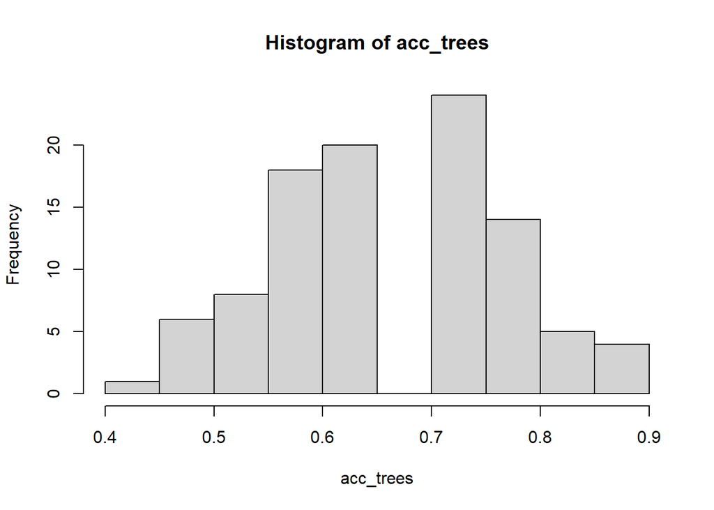

```r
# acc
acc_trees <- acc[1,]
hist(acc_trees)
```

```r
mean(acc_trees)
```

```
## [1] 0.6629412
```

```r
median(acc_trees)
```

```
## [1] 0.6470588
```

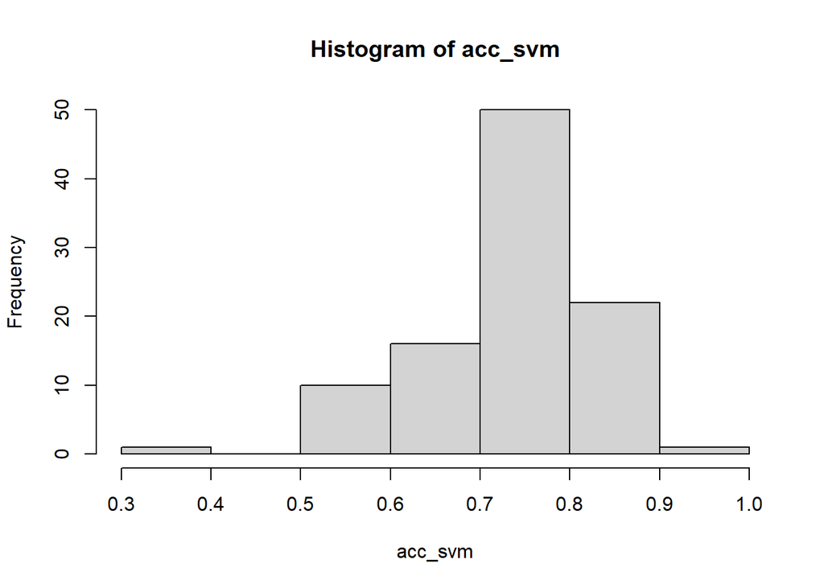

```r
acc_svm <- acc[2,]
hist(acc_svm)
```

```r
mean(acc_svm)
```

```
## [1] 0.7264706
```

```r
median(acc_svm)
```

```
## [1] 0.7058824
```

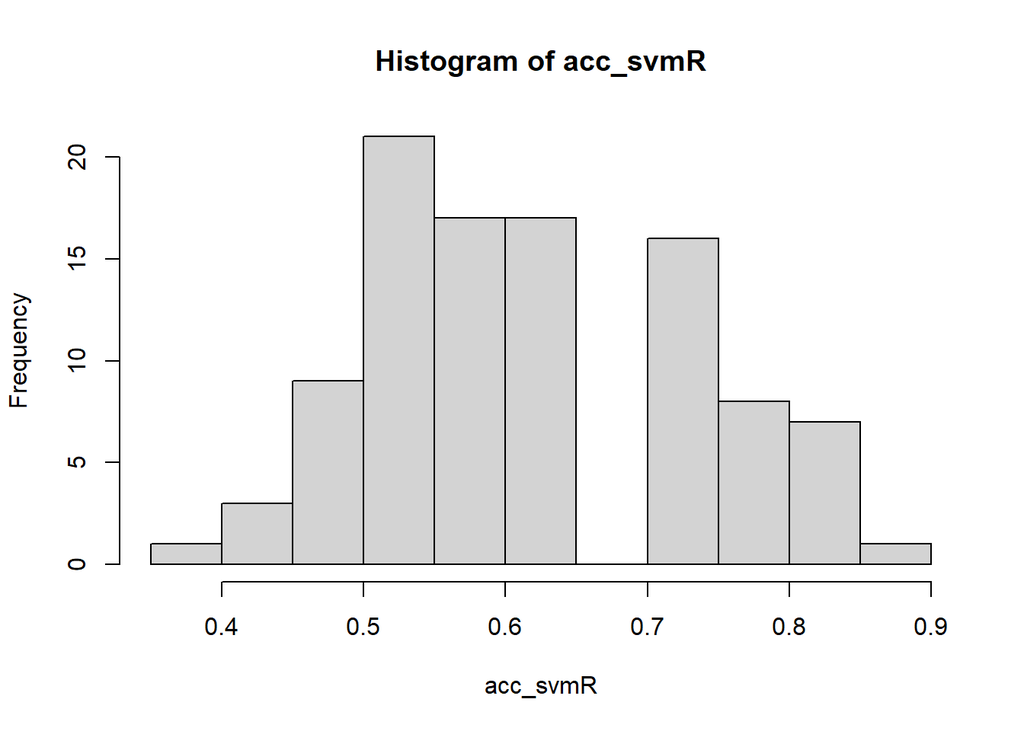

```r
acc_svmR <- acc[3,]
hist(acc_svmR)
```

```r
mean(acc_svmR)
```

```
## [1] 0.62
```

```r
median(acc_svmR)
```

```
## [1] 0.5882353
```

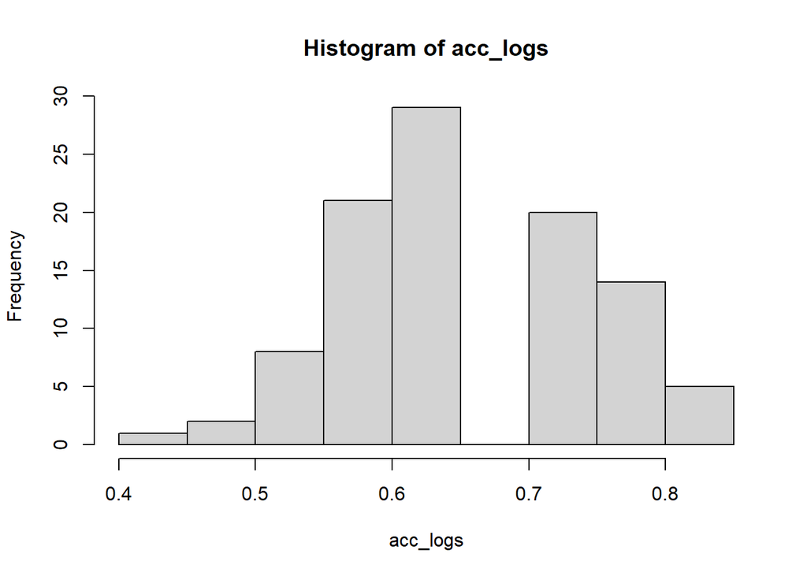

```r
acc_logs <- acc[4,]
hist(acc_logs)
```

```r
mean(acc_logs)
```

```
## [1] 0.6564706
```

```r
median(acc_logs)
```

```
## [1] 0.6470588
```

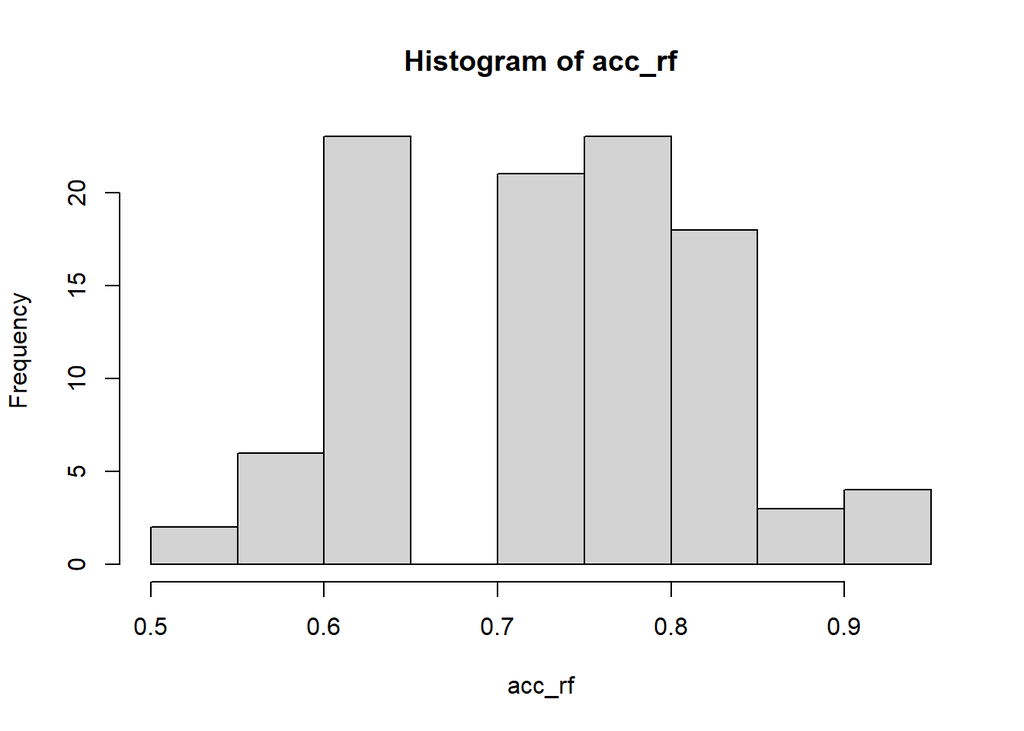

```r
acc_rf <- acc[5,]
hist(acc_rf)
```

```r
mean(acc_rf)
```

```
## [1] 0.7311765
```

```r
median(acc_rf)
```

```
## [1] 0.7058824
```

- Misclassification

```r
# miscl
miscl_trees <- miscl[1,]
#hist(miscl_trees)
mean(miscl_trees)
```

```
## [1] 5.73
```

```r
median(miscl_trees)
```

```
## [1] 6
```

```r
miscl_svm <- miscl[2,]
#hist(miscl_svm)
mean(miscl_svm)
```

```
## [1] 4.65
```

```r
median(miscl_svm)
```

```
## [1] 5
```

```r
miscl_svmR <- miscl[3,]
#hist(miscl_svmR)
mean(miscl_svmR)
```

```
## [1] 6.46
```

```r
median(miscl_svmR)
```

```
## [1] 7
```

```r
miscl_logs <- miscl[4,]
#hist(miscl_logs)
mean(miscl_logs)
```

```
## [1] 5.84
```

```r
median(miscl_logs)
```

```
## [1] 6
```

```r
miscl_rf <- miscl[5,]
#hist(miscl_rf)
mean(miscl_rf)
```

```
## [1] 4.57
```

```r
median(miscl_rf)
```

```
## [1] 5
```

- Sensitivity

```r
# sensitivity
sensitivity_trees <- sensitivity[1,]
sensitivity_trees <- na.omit(sensitivity_trees)
#hist(sensitivity_trees)
mean(sensitivity_trees)
```

```
## [1] 0.6657973
```

```r
median(sensitivity_trees)
```

```
## [1] 0.6666667
```

```r
sensitivity_svm <- sensitivity[2,]
sensitivity_svm <- na.omit(sensitivity_svm)
#hist(sensitivity_svm)
mean(sensitivity_svm)
```

```
## [1] 0.7851633
```

```r
median(sensitivity_svm)
```

```
## [1] 0.75
```

```r
sensitivity_svmR <- sensitivity[3,]
sensitivity_svmR <- na.omit(sensitivity_svmR)
#hist(sensitivity_svmR)
mean(sensitivity_svmR)
```

```
## [1] 0.5999259
```

```r
median(sensitivity_svmR)
```

```
## [1] 0.5833333
```

```r
sensitivity_logs <- sensitivity[4,]

sensitivity_logs <- na.omit(sensitivity_logs)
#hist(sensitivity_logs)
mean(sensitivity_logs)
```

```
## [1] 0.6677825
```

```r
median(sensitivity_logs)
```

```
## [1] 0.6666667
```

```r
sensitivity_rf <- sensitivity[5,]
sensitivity_rf <- na.omit(sensitivity_rf)
#hist(sensitivity_rf)
mean(sensitivity_rf)
```

```
## [1] 0.7388308
```

```r
median(sensitivity_rf)
```

```
## [1] 0.7142857
```

- Specificity

```r
# specificity
specificity_trees <- specificity[1,]
specificity_trees <- na.omit(specificity_trees)
#hist(specificity_trees)
mean(specificity_trees)
```

```
## [1] 0.6802922
```

```r
median(specificity_trees)
```

```
## [1] 0.6666667
```

```r
specificity_svm <- specificity[2,]
specificity_svm <- na.omit(specificity_svm)
#hist(specificity_svm)
mean(specificity_svm)
```

```
## [1] 0.7261616
```

```r
median(specificity_svm)
```

```
## [1] 0.7207792
```

```r
specificity_svmR <- specificity[3,]
specificity_svmR <- na.omit(specificity_svmR)
#hist(specificity_svmR)
mean(specificity_svmR)
```

```
## [1] 0.7017921
```

```r
median(specificity_svmR)
```

```
## [1] 0.7
```

```r
specificity_logs <- specificity[4,]
specificity_logs <- na.omit(specificity_logs)
#hist(specificity_logs)
mean(specificity_logs)
```

```
## [1] 0.6635879
```

```r
median(specificity_logs)
```

```
## [1] 0.6396104
```

```r
specificity_rf <- specificity[5,]
specificity_rf <- na.omit(specificity_rf)
#hist(specificity_rf)
mean(specificity_rf)
```

```
## [1] 0.7523768
```

```r
median(specificity_rf)
```

```
## [1] 0.75
```

- False Neg

```r
# fneg
fneg_trees <- fneg[1,]
#hist(fneg_trees)
mean(fneg_trees)
```

```
## [1] 3.23
```

```r
median(fneg_trees)
```

```
## [1] 3
```

```r
fneg_svmL <- fneg[2,]
#hist(fneg_svmL)
mean(fneg_svmL)
```

```
## [1] 2.98
```

```r
median(fneg_svmL)
```

```
## [1] 3
```

```r
fneg_svmR <- fneg[3,]
#hist(fneg_svmR)
mean(fneg_svmR)
```

```
## [1] 3
```

```r
median(fneg_svmR)
```

```
## [1] 2
```

```r
fneg_logs <- fneg[4,]
#hist(fneg_logs)
mean(fneg_logs)
```

```
## [1] 3.48
```

```r
median(fneg_logs)
```

```
## [1] 3
```

```r
fneg_rf <- fneg[5,]
#hist(fneg_rf)
mean(fneg_rf)
```

```
## [1] 2.42
```

```r
median(fneg_rf)
```

```
## [1] 2
```

#### 3.2.4.2 2) Classification with regularization (EN and iTwiner)

```r
xdata <- xdataT


ydata.raw <- as.data.frame(clinic1$class)
ydata.raw$row <- DATASET1$ID
#
# # ydata.raw$class <- c(rep(0,28),rep(1,34))
#
ydata.raw$`clinic1$class`[ydata.raw$`clinic1$class` == "P"] <- 0
ydata.raw$`clinic1$class`[ydata.raw$`clinic1$class` == "Pm"] <- 1
rownames(ydata.raw) <- DATASET1$ID

xdata <- xdata[rownames(xdata) %in%
                         rownames(ydata.raw),]

ydata.raw <- as.data.frame(ydata.raw[rownames(ydata.raw) %in%
                         rownames(xdata),])

xdata <- xdata[ order(row.names(xdata)), ]

ydata.raw <- ydata.raw[ order(row.names(ydata.raw)), ]



ydata <- as.data.frame(ydata.raw)
ydata$`clinic1$class` <- as.numeric(ydata$`clinic1$class`)
```

```r
times_boot <- 1000

nvar_selected_1 <- matrix(0,2,times_boot)

var_selected_en1 <- vector("list")
var_selected_iTwiner1 <- vector("list")

acc_cox_tr <- matrix(0,2,times_boot)
acc_cox_tes <- matrix(0,2,times_boot)
kappa_cox_tr <- matrix(0,2,times_boot)
kappa_cox_tes <- matrix(0,2,times_boot)
sensitivity_cox_tr <- matrix(0,2,times_boot)
sensitivity_cox_tes <- matrix(0,2,times_boot)
specificity_cox_tr <- matrix(0,2,times_boot)
specificity_cox_tes <- matrix(0,2,times_boot)
miscl_cox_tr <- matrix(0,2,times_boot)
miscl_cox_tes <- matrix(0,2,times_boot)


fpos_reg <- matrix(0,2,times_boot)
fneg_reg <- matrix(0,2,times_boot)

ids_fn_en <- vector("list")
ids_fn_iTwiner <- vector("list")


ids_fp_en <- vector("list")
ids_fp_iTwiner <- vector("list")

run = 1000

i=1
l1=0
while(l1 < 100){

  print(l1)
  print(i)
  run = run + 11
  set.seed(run)
  print(run)

  ixs <- loose.rock::balanced.train.and.test(which(as.logical(ydata$`clinic1$class`)), which(as.logical(!ydata$`clinic1$class` )), train.perc = 0.7)
  xtrain <- xdata[ixs$train,]
  ytrain <- ydata[ixs$train,1]

  xtest <- xdata[ixs$test,]
  ytest <- ydata[ixs$test,1]

  print("data")

  xtrain <- as.matrix(xtrain)
  xtest <- as.matrix(xtest)


# Classification by sparse logistic regression

## with the elastic net (EN) penalty

  fit_EN1 <- cv.glmnet(as.matrix(xtrain), as.factor(ytrain), family="binomial", nfolds=10, alpha=0.2,
                       #foldid=my_foldid,
                       type.measure="mse")

  var_selected <- which(fit_EN1$glmnet.fit$beta[,which(fit_EN1$cvm == min(fit_EN1$cvm))] != 0)

  nvar_selected_1[1,i] <- length(var_selected)


  var_selected_en1[[i]] <- names(var_selected)



  if (length(var_selected) > 1){

    # results

    ##train
    resp_train <- as.data.frame(predict(fit_EN1, s = 'lambda.min', newx = xtrain, type = 'class'))
    resp_train <- resp_train[,1]

    if (length(which(resp_train == 0)) == 0 | length(which(resp_train == 1)) == 0){

      print("en train ups")} else{

        t <- table(ytrain,resp_train)
        result <- confusionMatrix(t)

        acc_cox_tr[1,i] <- result[["overall"]][["Accuracy"]]
        kappa_cox_tr[1,i] <- result[["overall"]][["Kappa"]]
        sensitivity_cox_tr[1,i] <- result[["byClass"]][["Sensitivity"]]
        specificity_cox_tr[1,i] <- result[["byClass"]][["Specificity"]]
        miscl_cox_tr[1,i] <- t[1,2]+t[2,1]

        rm(var_selected,resp_train,t,result)
      }



    ## test
    pred <- as.data.frame(predict(fit_EN1, s = 'lambda.min', newx = xtest, type = 'class'))
    pred <- pred[,1]

    if (length(which(pred == 0)) == 0 | length(which(pred == 1)) == 0){

      print("en pred ups")} else{

        t <- table(ytest,pred)
        result <- confusionMatrix(t)

        acc_cox_tes[1,i] <- result[["overall"]][["Accuracy"]]
        kappa_cox_tes[1,i] <- result[["overall"]][["Kappa"]]
        sensitivity_cox_tes[1,i] <- result[["byClass"]][["Sensitivity"]]
        specificity_cox_tes[1,i] <- result[["byClass"]][["Specificity"]]
        miscl_cox_tes[1,i] <- t[1,2]+t[2,1]

      }

    true <- ytest

    listafp <- c()
    listafn <- c()

    for (a in which(pred!= true)){

      if (pred[a] == 0) {

        listafp <- c(listafp, a)
      } else {
        listafn <- c(listafn, a)
      }
    }

    fpos_reg[1,i] <- length(listafp)
    fneg_reg[1,i] <- length(listafn)
    ids_fn_en[[i]] <- rownames(xtest[listafn,])
    ids_fp_en[[i]] <- rownames(xtest[listafp,])


    print("EN")} else{
      print("EN não selecionou variaveis")
    }

  rm(pred,t,result)


  i=i+1


  rm(xtrain,xtest,ytrain,ytest,ytest)

  l1 <- length(which(acc_cox_tr[1,]!=0))

}
```

[output not shown]

[output cut: 82 more lines]

[output not shown]

[output not shown]

```r
i=1
l2=0
while(l2 < 100){

  print(i)
  print(l2)
  run = run + 11
  set.seed(run)
  print(run)

  ixs <- loose.rock::balanced.train.and.test(which(as.logical(ydata$`clinic1$class`)), which(as.logical(!ydata$`clinic1$class` )), train.perc = 0.7)
  xtrain <- xdata[ixs$train,]
  ytrain <- ydata[ixs$train,1]

  xtest <- xdata[ixs$test,]
  ytest <- ydata[ixs$test,1]

  print("data")

  xtrain <- as.matrix(xtrain)
  xtest <- as.matrix(xtest)


## with network information - iTwiner

  fit_tco1 <- cv.glmnet(as.matrix(xtrain), as.factor(ytrain), family="binomial", nfolds=10, alpha=0.05 ,
                        #foldid=my_foldid,
                        penalty.factor = pen_weight2,
                        type.measure="mse")

  var_selected <- which(fit_tco1$glmnet.fit$beta[,which(fit_tco1$cvm == min(fit_tco1$cvm))] != 0)

  nvar_selected_1[2,i] <- length(var_selected)


  var_selected_iTwiner1[[i]] <- names(var_selected)

  if (length(var_selected) > 1){
    # results

    ##train
    resp_train <- as.data.frame(predict(fit_tco1, s = 'lambda.min', newx = xtrain, type = 'class'))
    resp_train <- resp_train[,1]

    if (length(which(resp_train == 0)) == 0 | length(which(resp_train == 1)) == 0){

      print("iTwiner train ups")} else{

        t <- table(ytrain,resp_train)
        result <- confusionMatrix(t)

        acc_cox_tr[2,i] <- result[["overall"]][["Accuracy"]]
        kappa_cox_tr[2,i] <- result[["overall"]][["Kappa"]]
        sensitivity_cox_tr[2,i] <- result[["byClass"]][["Sensitivity"]]
        specificity_cox_tr[2,i] <- result[["byClass"]][["Specificity"]]
        miscl_cox_tr[2,i] <- t[1,2]+t[2,1]

        rm(var_selected,resp_train,t,result)

      }



    ## test
    pred <- as.data.frame(predict(fit_tco1, s = 'lambda.min', newx = xtest, type = 'class'))
    pred <- pred[,1]

    if (length(which(pred == 0)) == 0 | length(which(pred == 1)) == 0){

      print("iTwiner test ups")} else{

        t <- table(ytest,pred)
        result <- confusionMatrix(t)

        acc_cox_tes[2,i] <- result[["overall"]][["Accuracy"]]
        kappa_cox_tes[2,i] <- result[["overall"]][["Kappa"]]
        sensitivity_cox_tes[2,i] <- result[["byClass"]][["Sensitivity"]]
        specificity_cox_tes[2,i] <- result[["byClass"]][["Specificity"]]
        miscl_cox_tes[2,i] <- t[1,2]+t[2,1]

      }

    true <- ytest

    listafp <- c()
    listafn <- c()

    for (a in which(pred!= true)){

      if (pred[a] == 0) {

        listafp <- c(listafp, a)
      } else {
        listafn <- c(listafn, a)
      }
    }

    fpos_reg[2,i] <- length(listafp)
    fneg_reg[2,i] <- length(listafn)
    ids_fn_iTwiner[[i]] <- rownames(xtest[listafn,])
    ids_fp_iTwiner[[i]] <- rownames(xtest[listafp,])



    print("iTwiner")

  } else{
    print("iTwiner não correu")
  }

    rm(xtrain,xtest,ytrain,ytest,ytest)
    l2 <- length(which(acc_cox_tr[2,]!=0))
    i=i+1
    }
```

```
## [1] 1
## [1] 0
## [1] 2166
## [1] "data"
## [1] "iTwiner"
```

```
## [1] 2
## [1] 1
## [1] 2177
## [1] "data"
## [1] "iTwiner"
```

```
## [1] 3
## [1] 2
## [1] 2188
## [1] "data"
## [1] "iTwiner"
```

```
## [1] 4
## [1] 3
## [1] 2199
## [1] "data"
## [1] "iTwiner"
```

```
## [1] 5
## [1] 4
## [1] 2210
## [1] "data"
## [1] "iTwiner"
```

```
## [1] 6
## [1] 5
## [1] 2221
## [1] "data"
## [1] "iTwiner"
```

```
## [1] 7
## [1] 6
## [1] 2232
## [1] "data"
## [1] "iTwiner"
```

```
## [1] 8
## [1] 7
## [1] 2243
## [1] "data"
## [1] "iTwiner"
```

```
## [1] 9
## [1] 8
## [1] 2254
## [1] "data"
## [1] "iTwiner train ups"
## [1] "iTwiner"
```

```
## [1] 10
## [1] 8
## [1] 2265
## [1] "data"
## [1] "iTwiner train ups"
## [1] "iTwiner test ups"
## [1] "iTwiner"
```

```
## [1] 11
## [1] 8
## [1] 2276
## [1] "data"
## [1] "iTwiner"
```

```
## [1] 12
## [1] 9
## [1] 2287
## [1] "data"
## [1] "iTwiner"
```

```
## [1] 13
## [1] 10
## [1] 2298
## [1] "data"
## [1] "iTwiner train ups"
## [1] "iTwiner"
```

```
## [1] 14
## [1] 10
## [1] 2309
## [1] "data"
## [1] "iTwiner train ups"
## [1] "iTwiner test ups"
## [1] "iTwiner"
```

```
## [1] 15
## [1] 10
## [1] 2320
## [1] "data"
## [1] "iTwiner"
```

```
## [1] 16
## [1] 11
## [1] 2331
## [1] "data"
## [1] "iTwiner"
```

```
## [1] 17
## [1] 12
## [1] 2342
## [1] "data"
## [1] "iTwiner"
```

```
## [1] 18
## [1] 13
## [1] 2353
## [1] "data"
## [1] "iTwiner"
```

```
## [1] 19
## [1] 14
## [1] 2364
## [1] "data"
## [1] "iTwiner"
```

```
## [1] 20
## [1] 15
## [1] 2375
## [1] "data"
## [1] "iTwiner train ups"
## [1] "iTwiner test ups"
## [1] "iTwiner"
```

```
## [1] 21
## [1] 15
## [1] 2386
## [1] "data"
## [1] "iTwiner train ups"
## [1] "iTwiner"
```

```
## [1] 22
## [1] 15
## [1] 2397
## [1] "data"
## [1] "iTwiner"
```

```
## [1] 23
## [1] 16
## [1] 2408
## [1] "data"
## [1] "iTwiner"
```

```
## [1] 24
## [1] 17
## [1] 2419
## [1] "data"
## [1] "iTwiner"
```

```
## [1] 25
## [1] 18
## [1] 2430
## [1] "data"
## [1] "iTwiner"
```

```
## [1] 26
## [1] 19
## [1] 2441
## [1] "data"
## [1] "iTwiner"
```

```
## [1] 27
## [1] 20
## [1] 2452
## [1] "data"
## [1] "iTwiner"
```

```
## [1] 28
## [1] 21
## [1] 2463
## [1] "data"
## [1] "iTwiner"
```

```
## [1] 29
## [1] 22
## [1] 2474
## [1] "data"
## [1] "iTwiner test ups"
## [1] "iTwiner"
```

```
## [1] 30
## [1] 23
## [1] 2485
## [1] "data"
## [1] "iTwiner"
```

```
## [1] 31
## [1] 24
## [1] 2496
## [1] "data"
## [1] "iTwiner"
```

```
## [1] 32
## [1] 25
## [1] 2507
## [1] "data"
## [1] "iTwiner"
```

```
## [1] 33
## [1] 26
## [1] 2518
## [1] "data"
## [1] "iTwiner"
```

```
## [1] 34
## [1] 27
## [1] 2529
## [1] "data"
## [1] "iTwiner"
```

```
## [1] 35
## [1] 28
## [1] 2540
## [1] "data"
## [1] "iTwiner train ups"
## [1] "iTwiner"
```

```
## [1] 36
## [1] 28
## [1] 2551
## [1] "data"
## [1] "iTwiner"
```

```
## [1] 37
## [1] 29
## [1] 2562
## [1] "data"
## [1] "iTwiner"
```

```
## [1] 38
## [1] 30
## [1] 2573
## [1] "data"
## [1] "iTwiner"
```

```
## [1] 39
## [1] 31
## [1] 2584
## [1] "data"
## [1] "iTwiner test ups"
## [1] "iTwiner"
```

```
## [1] 40
## [1] 32
## [1] 2595
## [1] "data"
## [1] "iTwiner train ups"
## [1] "iTwiner test ups"
## [1] "iTwiner"
```

```
## [1] 41
## [1] 32
## [1] 2606
## [1] "data"
## [1] "iTwiner train ups"
## [1] "iTwiner test ups"
## [1] "iTwiner"
```

```
## [1] 42
## [1] 32
## [1] 2617
## [1] "data"
## [1] "iTwiner"
```

```
## [1] 43
## [1] 33
## [1] 2628
## [1] "data"
## [1] "iTwiner train ups"
## [1] "iTwiner"
```

```
## [1] 44
## [1] 33
## [1] 2639
## [1] "data"
## [1] "iTwiner"
```

```
## [1] 45
## [1] 34
## [1] 2650
## [1] "data"
## [1] "iTwiner"
```

```
## [1] 46
## [1] 35
## [1] 2661
## [1] "data"
## [1] "iTwiner train ups"
## [1] "iTwiner"
```

```
## [1] 47
## [1] 35
## [1] 2672
## [1] "data"
## [1] "iTwiner test ups"
## [1] "iTwiner"
```

```
## [1] 48
## [1] 36
## [1] 2683
## [1] "data"
## [1] "iTwiner"
```

```
## [1] 49
## [1] 37
## [1] 2694
## [1] "data"
## [1] "iTwiner train ups"
## [1] "iTwiner test ups"
## [1] "iTwiner"
```

```
## [1] 50
## [1] 37
## [1] 2705
## [1] "data"
## [1] "iTwiner"
```

```
## [1] 51
## [1] 38
## [1] 2716
## [1] "data"
## [1] "iTwiner test ups"
## [1] "iTwiner"
```

```
## [1] 52
## [1] 39
## [1] 2727
## [1] "data"
## [1] "iTwiner test ups"
## [1] "iTwiner"
```

```
## [1] 53
## [1] 40
## [1] 2738
## [1] "data"
## [1] "iTwiner"
```

```
## [1] 54
## [1] 41
## [1] 2749
## [1] "data"
## [1] "iTwiner"
```

```
## [1] 55
## [1] 42
## [1] 2760
## [1] "data"
## [1] "iTwiner"
```

```
## [1] 56
## [1] 43
## [1] 2771
## [1] "data"
## [1] "iTwiner test ups"
## [1] "iTwiner"
```

```
## [1] 57
## [1] 44
## [1] 2782
## [1] "data"
## [1] "iTwiner test ups"
## [1] "iTwiner"
```

```
## [1] 58
## [1] 45
## [1] 2793
## [1] "data"
## [1] "iTwiner"
```

```
## [1] 59
## [1] 46
## [1] 2804
## [1] "data"
## [1] "iTwiner"
```

```
## [1] 60
## [1] 47
## [1] 2815
## [1] "data"
## [1] "iTwiner train ups"
## [1] "iTwiner test ups"
## [1] "iTwiner"
```

```
## [1] 61
## [1] 47
## [1] 2826
## [1] "data"
## [1] "iTwiner"
```

```
## [1] 62
## [1] 48
## [1] 2837
## [1] "data"
## [1] "iTwiner"
```

```
## [1] 63
## [1] 49
## [1] 2848
## [1] "data"
## [1] "iTwiner test ups"
## [1] "iTwiner"
```

```
## [1] 64
## [1] 50
## [1] 2859
## [1] "data"
## [1] "iTwiner train ups"
## [1] "iTwiner"
```

```
## [1] 65
## [1] 50
## [1] 2870
## [1] "data"
## [1] "iTwiner"
```

```
## [1] 66
## [1] 51
## [1] 2881
## [1] "data"
## [1] "iTwiner train ups"
## [1] "iTwiner"
```

```
## [1] 67
## [1] 51
## [1] 2892
## [1] "data"
## [1] "iTwiner"
```

```
## [1] 68
## [1] 52
## [1] 2903
## [1] "data"
## [1] "iTwiner"
```

```
## [1] 69
## [1] 53
## [1] 2914
## [1] "data"
## [1] "iTwiner"
```

```
## [1] 70
## [1] 54
## [1] 2925
## [1] "data"
## [1] "iTwiner"
```

```
## [1] 71
## [1] 55
## [1] 2936
## [1] "data"
## [1] "iTwiner train ups"
## [1] "iTwiner"
```

```
## [1] 72
## [1] 55
## [1] 2947
## [1] "data"
## [1] "iTwiner"
```

```
## [1] 73
## [1] 56
## [1] 2958
## [1] "data"
## [1] "iTwiner train ups"
## [1] "iTwiner"
```

```
## [1] 74
## [1] 56
## [1] 2969
## [1] "data"
## [1] "iTwiner train ups"
## [1] "iTwiner test ups"
## [1] "iTwiner"
```

```
## [1] 75
## [1] 56
## [1] 2980
## [1] "data"
## [1] "iTwiner train ups"
## [1] "iTwiner"
```

```
## [1] 76
## [1] 56
## [1] 2991
## [1] "data"
## [1] "iTwiner"
```

```
## [1] 77
## [1] 57
## [1] 3002
## [1] "data"
## [1] "iTwiner train ups"
## [1] "iTwiner test ups"
## [1] "iTwiner"
```

```
## [1] 78
## [1] 57
## [1] 3013
## [1] "data"
## [1] "iTwiner test ups"
## [1] "iTwiner"
```

```
## [1] 79
## [1] 58
## [1] 3024
## [1] "data"
## [1] "iTwiner train ups"
## [1] "iTwiner test ups"
## [1] "iTwiner"
```

```
## [1] 80
## [1] 58
## [1] 3035
## [1] "data"
## [1] "iTwiner"
```

```
## [1] 81
## [1] 59
## [1] 3046
## [1] "data"
## [1] "iTwiner train ups"
## [1] "iTwiner test ups"
## [1] "iTwiner"
```

```
## [1] 82
## [1] 59
## [1] 3057
## [1] "data"
## [1] "iTwiner train ups"
## [1] "iTwiner test ups"
## [1] "iTwiner"
```

```
## [1] 83
## [1] 59
## [1] 3068
## [1] "data"
## [1] "iTwiner train ups"
## [1] "iTwiner"
```

```
## [1] 84
## [1] 59
## [1] 3079
## [1] "data"
## [1] "iTwiner train ups"
## [1] "iTwiner test ups"
## [1] "iTwiner"
```

```
## [1] 85
## [1] 59
## [1] 3090
## [1] "data"
## [1] "iTwiner não correu"
```

```
## [1] 86
## [1] 59
## [1] 3101
## [1] "data"
## [1] "iTwiner train ups"
## [1] "iTwiner test ups"
## [1] "iTwiner"
```

```
## [1] 87
## [1] 59
## [1] 3112
## [1] "data"
## [1] "iTwiner"
```

```
## [1] 88
## [1] 60
## [1] 3123
## [1] "data"
## [1] "iTwiner train ups"
## [1] "iTwiner test ups"
## [1] "iTwiner"
```

```
## [1] 89
## [1] 60
## [1] 3134
## [1] "data"
## [1] "iTwiner train ups"
## [1] "iTwiner test ups"
## [1] "iTwiner"
```

```
## [1] 90
## [1] 60
## [1] 3145
## [1] "data"
## [1] "iTwiner train ups"
## [1] "iTwiner"
```

```
## [1] 91
## [1] 60
## [1] 3156
## [1] "data"
## [1] "iTwiner"
```

```
## [1] 92
## [1] 61
## [1] 3167
## [1] "data"
## [1] "iTwiner"
```

```
## [1] 93
## [1] 62
## [1] 3178
## [1] "data"
## [1] "iTwiner"
```

```
## [1] 94
## [1] 63
## [1] 3189
## [1] "data"
## [1] "iTwiner train ups"
## [1] "iTwiner test ups"
## [1] "iTwiner"
```

```
## [1] 95
## [1] 63
## [1] 3200
## [1] "data"
## [1] "iTwiner"
```

```
## [1] 96
## [1] 64
## [1] 3211
## [1] "data"
## [1] "iTwiner"
```

```
## [1] 97
## [1] 65
## [1] 3222
## [1] "data"
## [1] "iTwiner"
```

```
## [1] 98
## [1] 66
## [1] 3233
## [1] "data"
## [1] "iTwiner"
```

```
## [1] 99
## [1] 67
## [1] 3244
## [1] "data"
## [1] "iTwiner train ups"
## [1] "iTwiner"
```

```
## [1] 100
## [1] 67
## [1] 3255
## [1] "data"
## [1] "iTwiner"
```

```
## [1] 101
## [1] 68
## [1] 3266
## [1] "data"
## [1] "iTwiner"
```

```
## [1] 102
## [1] 69
## [1] 3277
## [1] "data"
## [1] "iTwiner"
```

```
## [1] 103
## [1] 70
## [1] 3288
## [1] "data"
## [1] "iTwiner"
```

```
## [1] 104
## [1] 71
## [1] 3299
## [1] "data"
## [1] "iTwiner test ups"
## [1] "iTwiner"
```

```
## [1] 105
## [1] 72
## [1] 3310
## [1] "data"
## [1] "iTwiner test ups"
## [1] "iTwiner"
```

```
## [1] 106
## [1] 73
## [1] 3321
## [1] "data"
## [1] "iTwiner"
```

```
## [1] 107
## [1] 74
## [1] 3332
## [1] "data"
## [1] "iTwiner train ups"
## [1] "iTwiner"
```

```
## [1] 108
## [1] 74
## [1] 3343
## [1] "data"
## [1] "iTwiner train ups"
## [1] "iTwiner test ups"
## [1] "iTwiner"
```

```
## [1] 109
## [1] 74
## [1] 3354
## [1] "data"
## [1] "iTwiner train ups"
## [1] "iTwiner test ups"
## [1] "iTwiner"
```

```
## [1] 110
## [1] 74
## [1] 3365
## [1] "data"
## [1] "iTwiner"
```

```
## [1] 111
## [1] 75
## [1] 3376
## [1] "data"
## [1] "iTwiner"
```

```
## [1] 112
## [1] 76
## [1] 3387
## [1] "data"
## [1] "iTwiner"
```

```
## [1] 113
## [1] 77
## [1] 3398
## [1] "data"
## [1] "iTwiner"
```

```
## [1] 114
## [1] 78
## [1] 3409
## [1] "data"
## [1] "iTwiner"
```

```
## [1] 115
## [1] 79
## [1] 3420
## [1] "data"
## [1] "iTwiner"
```

```
## [1] 116
## [1] 80
## [1] 3431
## [1] "data"
## [1] "iTwiner"
```

```
## [1] 117
## [1] 81
## [1] 3442
## [1] "data"
## [1] "iTwiner"
```

```
## [1] 118
## [1] 82
## [1] 3453
## [1] "data"
## [1] "iTwiner train ups"
## [1] "iTwiner test ups"
## [1] "iTwiner"
```

```
## [1] 119
## [1] 82
## [1] 3464
## [1] "data"
## [1] "iTwiner train ups"
## [1] "iTwiner"
```

```
## [1] 120
## [1] 82
## [1] 3475
## [1] "data"
## [1] "iTwiner"
```

```
## [1] 121
## [1] 83
## [1] 3486
## [1] "data"
## [1] "iTwiner"
```

```
## [1] 122
## [1] 84
## [1] 3497
## [1] "data"
## [1] "iTwiner train ups"
## [1] "iTwiner test ups"
## [1] "iTwiner"
```

```
## [1] 123
## [1] 84
## [1] 3508
## [1] "data"
## [1] "iTwiner"
```

```
## [1] 124
## [1] 85
## [1] 3519
## [1] "data"
## [1] "iTwiner"
```

```
## [1] 125
## [1] 86
## [1] 3530
## [1] "data"
## [1] "iTwiner"
```

```
## [1] 126
## [1] 87
## [1] 3541
## [1] "data"
## [1] "iTwiner train ups"
## [1] "iTwiner test ups"
## [1] "iTwiner"
```

```
## [1] 127
## [1] 87
## [1] 3552
## [1] "data"
## [1] "iTwiner train ups"
## [1] "iTwiner test ups"
## [1] "iTwiner"
```

```
## [1] 128
## [1] 87
## [1] 3563
## [1] "data"
## [1] "iTwiner train ups"
## [1] "iTwiner test ups"
## [1] "iTwiner"
```

```
## [1] 129
## [1] 87
## [1] 3574
## [1] "data"
## [1] "iTwiner train ups"
## [1] "iTwiner"
```

```
## [1] 130
## [1] 87
## [1] 3585
## [1] "data"
## [1] "iTwiner"
```

```
## [1] 131
## [1] 88
## [1] 3596
## [1] "data"
## [1] "iTwiner"
```

```
## [1] 132
## [1] 89
## [1] 3607
## [1] "data"
## [1] "iTwiner test ups"
## [1] "iTwiner"
```

```
## [1] 133
## [1] 90
## [1] 3618
## [1] "data"
## [1] "iTwiner"
```

```
## [1] 134
## [1] 91
## [1] 3629
## [1] "data"
## [1] "iTwiner train ups"
## [1] "iTwiner"
```

```
## [1] 135
## [1] 91
## [1] 3640
## [1] "data"
## [1] "iTwiner"
```

```
## [1] 136
## [1] 92
## [1] 3651
## [1] "data"
## [1] "iTwiner train ups"
## [1] "iTwiner"
```

```
## [1] 137
## [1] 92
## [1] 3662
## [1] "data"
## [1] "iTwiner train ups"
## [1] "iTwiner test ups"
## [1] "iTwiner"
```

```
## [1] 138
## [1] 92
## [1] 3673
## [1] "data"
## [1] "iTwiner"
```

```
## [1] 139
## [1] 93
## [1] 3684
## [1] "data"
## [1] "iTwiner"
```

```
## [1] 140
## [1] 94
## [1] 3695
## [1] "data"
## [1] "iTwiner train ups"
## [1] "iTwiner test ups"
## [1] "iTwiner"
```

```
## [1] 141
## [1] 94
## [1] 3706
## [1] "data"
## [1] "iTwiner"
```

```
## [1] 142
## [1] 95
## [1] 3717
## [1] "data"
## [1] "iTwiner"
```

```
## [1] 143
## [1] 96
## [1] 3728
## [1] "data"
## [1] "iTwiner"
```

```
## [1] 144
## [1] 97
## [1] 3739
## [1] "data"
## [1] "iTwiner"
```

```
## [1] 145
## [1] 98
## [1] 3750
## [1] "data"
## [1] "iTwiner"
```

```
## [1] 146
## [1] 99
## [1] 3761
## [1] "data"
## [1] "iTwiner"
```

##### 3.2.4.2.1 Measures of model performance

```r
runs_en <- which(acc_cox_tr[1,]!=0)
runs_itw <- which(acc_cox_tr[2,]!=0)
```

- Accuracy

```r
# EN train
acc_cox_tr_EN <- acc_cox_tr[1,]
acc_cox_tr_EN <- acc_cox_tr_EN[runs_en]
#hist(acc_cox_tr_EN)
mean(acc_cox_tr_EN)
```

```
## [1] 0.8394737
```

```r
median(acc_cox_tr_EN)
```

```
## [1] 0.8421053
```

```r
# EN test
acc_cox_tes_EN <- acc_cox_tes[1,]
acc_cox_tes_EN <- acc_cox_tes_EN[runs_en]
#hist(acc_cox_tes_EN)
mean(acc_cox_tes_EN)
```

```
## [1] 0.5888235
```

```r
median(acc_cox_tes_EN)
```

```
## [1] 0.5882353
```

```r
#iTwiner train
acc_cox_tr_iTwiner <- acc_cox_tr[2,]
acc_cox_tr_iTwiner <- acc_cox_tr_iTwiner[runs_itw]
#hist(acc_cox_tr_iTwiner)
mean(acc_cox_tr_iTwiner)
```

```
## [1] 0.7313158
```

```r
median(acc_cox_tr_iTwiner)
```

```
## [1] 0.7368421
```

```r
#iTwiner test
acc_cox_tes_iTwiner <- acc_cox_tes[2,]
acc_cox_tes_iTwiner <- acc_cox_tes_iTwiner[runs_itw]
#hist(acc_cox_tes_iTwiner)
mean(acc_cox_tes_iTwiner)
```

```
## [1] 0.5705882
```

```r
median(acc_cox_tes_iTwiner)
```

```
## [1] 0.6470588
```

- miscl

```r
#EN train
miscl_cox_tr_EN <- miscl_cox_tr[1,]
miscl_cox_tr_EN <- miscl_cox_tr_EN[runs_en]
#hist(miscl_cox_tr_EN)
mean(miscl_cox_tr_EN)
```

```
## [1] 6.1
```

```r
median(miscl_cox_tr_EN)
```

```
## [1] 6
```

```r
#EN test
miscl_cox_tes_EN <- miscl_cox_tes[1,]
miscl_cox_tes_EN <- miscl_cox_tes_EN[runs_en]
#hist(miscl_cox_tes_EN)
mean(miscl_cox_tes_EN)
```

```
## [1] 6.99
```

```r
median(miscl_cox_tes_EN)
```

```
## [1] 7
```

```r
#iTwiner train
miscl_cox_tr_iTwiner <- miscl_cox_tr[2,]
miscl_cox_tr_iTwiner <- miscl_cox_tr_iTwiner[runs_itw]
#hist(miscl_cox_tr_iTwiner)
mean(miscl_cox_tr_iTwiner)
```

```
## [1] 10.21
```

```r
median(miscl_cox_tr_iTwiner)
```

```
## [1] 10
```

```r
#iTwiner test
miscl_cox_tes_iTwiner <- miscl_cox_tes[2,]
miscl_cox_tes_iTwiner <- miscl_cox_tes_iTwiner[runs_itw]
#hist(miscl_cox_tes_iTwiner)
mean(miscl_cox_tes_iTwiner)
```

```
## [1] 5.26
```

```r
median(miscl_cox_tes_iTwiner)
```

```
## [1] 6
```

- sensitivity

```r
#EN train
sensitivity_cox_tr_EN <- sensitivity_cox_tr[1,]
sensitivity_cox_tr_EN <- sensitivity_cox_tr_EN[runs_en]
#hist(sensitivity_cox_tr_EN)
mean(sensitivity_cox_tr_EN)
```

```
## [1] 1
```

```r
median(sensitivity_cox_tr_EN)
```

```
## [1] 1
```

```r
#EN test
sensitivity_cox_tes_EN <- sensitivity_cox_tes[1,]
sensitivity_cox_tes_EN <- sensitivity_cox_tes_EN[runs_en]
#hist(sensitivity_cox_tes_EN)
mean(sensitivity_cox_tes_EN)
```

```
## [1] 0.6308095
```

```r
median(sensitivity_cox_tes_EN)
```

```
## [1] 0.6
```

```r
#iTwiner train
sensitivity_cox_tr_iTwiner <- sensitivity_cox_tr[2,]
sensitivity_cox_tr_iTwiner <- sensitivity_cox_tr_iTwiner[runs_itw]
#hist(sensitivity_cox_tr_iTwiner)
mean(sensitivity_cox_tr_iTwiner)
```

```
## [1] 1
```

```r
median(sensitivity_cox_tr_iTwiner)
```

```
## [1] 1
```

```r
#iTwiner test
sensitivity_cox_tes_iTwiner <- sensitivity_cox_tes[2,]
sensitivity_cox_tes_iTwiner <- sensitivity_cox_tes_iTwiner[runs_itw]
#hist(sensitivity_cox_tes_iTwiner)
mean(sensitivity_cox_tes_iTwiner)
```

```
## [1] 0.8583333
```

```r
median(sensitivity_cox_tes_iTwiner)
```

```
## [1] 1
```

- specificity

```r
#EN train
specificity_cox_tr_EN <- specificity_cox_tr[1,]
specificity_cox_tr_EN <- specificity_cox_tr_EN[runs_en]
#hist(specificity_cox_tr_EN)
mean(specificity_cox_tr_EN)
```

```
## [1] 0.7794892
```

```r
median(specificity_cox_tr_EN)
```

```
## [1] 0.7777778
```

```r
#EN test
specificity_cox_tes_EN <- specificity_cox_tes[1,]
specificity_cox_tes_EN <- specificity_cox_tes_EN[runs_en]
#hist(specificity_cox_tes_EN)
mean(specificity_cox_tes_EN)
```

```
## [1] 0.5868693
```

```r
median(specificity_cox_tes_EN)
```

```
## [1] 0.5833333
```

```r
#iTwiner train
specificity_cox_tr_iTwiner <- specificity_cox_tr[2,]
specificity_cox_tr_iTwiner <- specificity_cox_tr_iTwiner[runs_itw]
#hist(specificity_cox_tr_iTwiner)
mean(specificity_cox_tr_iTwiner)
```

```
## [1] 0.6816045
```

```r
median(specificity_cox_tr_iTwiner)
```

```
## [1] 0.6774194
```

```r
#iTwiner test
specificity_cox_tes_iTwiner <- specificity_cox_tes[2,]
specificity_cox_tes_iTwiner <- specificity_cox_tes_iTwiner[runs_itw]
#hist(specificity_cox_tes_iTwiner)
mean(specificity_cox_tes_iTwiner)
```

```
## [1] 0.5316494
```

```r
median(specificity_cox_tes_iTwiner)
```

```
## [1] 0.6
```

- False Neg

```r
#EN
fneg_reg_en <- fneg_reg[1,nvar_en]
#hist(fneg_reg_en)
mean(fneg_reg_en)
```

```
## [1] 4.8
```

```r
median(fneg_reg_en)
```

```
## [1] 5
```

```r
#iTwiner
fneg_reg_iTwiner <- fneg_reg[2,nvar_tw]
#hist(fneg_reg_iTwiner)
mean(fneg_reg_iTwiner)
```

```
## [1] 6.74
```

```r
median(fneg_reg_iTwiner)
```

```
## [1] 7
```

- number variables selected

```r
# median number of variables selected
nvar_en <- nvar_selected_1[1,]
nvar_en <- nvar_en[runs_en]
mean(nvar_en)
```

```
## [1] 47.93
```

```r
median(nvar_en)
```

```
## [1] 45
```

```r
nvar_tw <- nvar_selected_1[2,]
nvar_tw <- nvar_tw[runs_itw]
mean(nvar_tw)
```

```
## [1] 45.26
```

```r
median(nvar_tw)
```

```
## [1] 42
```

##### 3.2.4.2.2 Names of genes selected

Variables always selected

```r
var_selected_alw_select_en <- var_selected_en1[runs_en]
var_selected_alw_select_en1 <-  Reduce(intersect,var_selected_alw_select_en)
print(paste("variables always selected by EN = ",length(var_selected_alw_select_en1)))
```

```
## [1] "variables always selected by EN =  0"
```

```r
var_selected_alw_select_iTwiner <- var_selected_iTwiner1[runs_itw]
var_selected_alw_select_iTwiner1 <-  Reduce(intersect,var_selected_alw_select_iTwiner)
print(paste("variables always selected by iTwiner = ",length(var_selected_alw_select_iTwiner1)))
```

```
## [1] "variables always selected by iTwiner =  3"
```

Variables selected in 50 bootstrap samples

```r
l = length(var_selected_alw_select_en)
var_selected_50_select_en <- table(unlist(var_selected_alw_select_en))
var_selected_50_select_en <- as.data.frame(var_selected_50_select_en)
var_selected_50_select_en <-  subset(var_selected_50_select_en, Freq > 0.50*l)
print(paste("variables selected 50% by EN = ",length(var_selected_50_select_en$Var1)))
```

```
## [1] "variables selected 50% by EN =  4"
```

```r
var_selected_50_select_en$Var1
```

```
## [1] CD200   MIR602  NCOR1P4 RLN3
## 1389 Levels: A2M-AS1 AANAT ABITRAMP1 ABR ACP3 ACRBP ACTBP2 ACTBP9 ... ZSCAN12P1
```

```r
#
l = length(var_selected_alw_select_iTwiner)
var_selected_50_select_iTwiner <- table(unlist(var_selected_alw_select_iTwiner))
var_selected_50_select_iTwiner <- as.data.frame(var_selected_50_select_iTwiner)
var_selected_50_select_iTwiner <-  subset(var_selected_50_select_iTwiner, Freq > 0.50*l)
print(paste("variables selected 50% by iTwiner = ",length(var_selected_50_select_iTwiner$Var1)))
```

```
## [1] "variables selected 50% by iTwiner =  27"
```

```r
var_selected_50_select_iTwiner$Var1
```

```
##  [1] CHMP1AP1  DNTT      GZMAP1    HAUS5-DT  HORMAD2   HSPD1P7   KCTD9P3
##  [8] LINC02543 LRIT1     MIR3907   MIR564    MIR602    NDUFA5P10 OR10H2
## [15] OR1S2     OR51K1P   PRSS57    RAC1P3    RN7SKP32  RNU4-76P  RNU6-428P
## [22] RNU6-552P RPL32P17  SULT6B2P  TPT1P3    TRBV11-1  XRCC6P2
## 242 Levels: ABCD1P3 ACTN4P1 ALDH7A1P4 ANKRD20A10P API5P1 APOOP4 ... ZNF725P
```

- Select the 50 most frequent variables

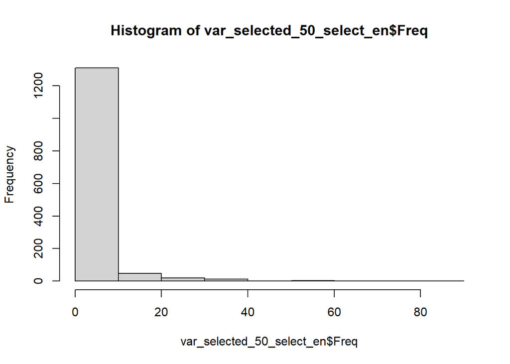

```r
var_selected_50_select_en <- table(unlist(var_selected_alw_select_en))
var_selected_50_select_en <- as.data.frame(var_selected_50_select_en)
var_selected_50_select_en <- var_selected_50_select_en[order(var_selected_50_select_en$Freq, decreasing = T),]
write_xlsx(var_selected_50_select_en,"genes_en_d2.xlsx")
hist(var_selected_50_select_en$Freq)
```

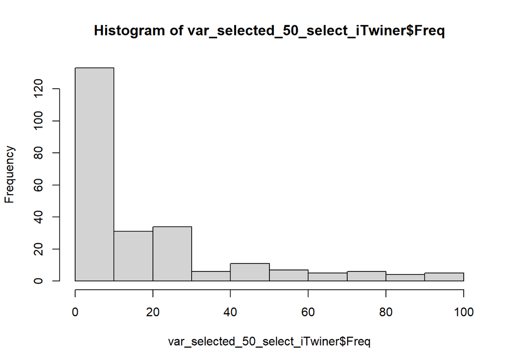

```r
top100_en <- var_selected_50_select_en[1:100,]
top100_en <- top100_en$Var1
top50_en <- top100_en[1:50]


var_selected_50_select_iTwiner <- table(unlist(var_selected_alw_select_iTwiner))
var_selected_50_select_iTwiner <- as.data.frame(var_selected_50_select_iTwiner)
var_selected_50_select_iTwiner <- var_selected_50_select_iTwiner[order(var_selected_50_select_iTwiner$Freq, decreasing = T),]
write_xlsx(var_selected_50_select_iTwiner,"genes_itw_d2.xlsx")
hist(var_selected_50_select_iTwiner$Freq)
```

```r
top100_itw <- var_selected_50_select_iTwiner[1:100,]
top100_itw <- top100_itw$Var1
top50_itw <- top100_itw[1:50]
```

variables in common between EN and iTwiner

```r
common_var_selected_50_en_iTwiner <- var_selected_50_select_iTwiner$Var1[which(var_selected_50_select_iTwiner$Var1 %in% var_selected_50_select_en$Var1)]
length(common_var_selected_50_en_iTwiner)
```

```
## [1] 51
```

```r
common_var_selected_50_en_iTwiner
```

```
##  [1] MIR602       RAC1P3       XRCC6P2      MIR3907      KCTD9P3
##  [6] GZMAP1       TRBV11-1     LRIT1        PRSS57       RNU6-428P
## [11] LINC02543    HAUS5-DT     DNTT         TPT1P3       RN7SKP32
## [16] OR1S2        RPL32P17     HORMAD2      MIR564       SULT6B2P
## [21] EEF1B2P6     MTND1P22     RNU1-18P     TRBJ1-6      MIR6508
## [26] LINC02868    SCDP1        LINC01100    MAGEB6       RNU6-542P
## [31] MIR376B      TRAJ40       TRAJ58       RNU7-193P    ANKRD20A10P
## [36] MIR6792      MIR4301      LINC01927    MIR509-2     RPL34P27
## [41] DBF4P3       KDM4F        CLUHP5       DEFB4B       RNA5SP42
## [46] RNU4-92P     CDH12P4      HMGB1P50     IGKV1OR2-118 MIR500B
## [51] MIR6729
## 242 Levels: ABCD1P3 ACTN4P1 ALDH7A1P4 ANKRD20A10P API5P1 APOOP4 ... ZNF725P
```

- Variables selected by EN and iTwiner that are DEGs

```r
xdata <- rnaseq1[ order(row.names(rnaseq1)), ]

nomesgenes <- c(as.vector(top50_en),as.vector(top50_itw))
xdata <- xdata[,nomesgenes]
rownames(DATASET1_bal) <- DATASET1_bal$ID
ydata <- as.data.frame(DATASET1_bal[ order(row.names(DATASET1_bal)), ])
rownames(ydata) <- ydata$ID

xdata <- xdata[rownames(xdata) %in%
                 rownames(ydata),]
ydata <- as.data.frame(ydata[rownames(ydata) %in%
                               rownames(xdata),])

# keep features with standard deviation > 0
xdata <- xdata[,sapply(seq(ncol(xdata)), function(ix) {sd(xdata[,ix])}) != 0]
xdata <- t(xdata)

group <- as.factor(ydata$class)
class <- as.data.frame(ydata$class)
```

```r
edgeR.DGElist <- DGEList(counts=xdata, group = group)

# remove genes that do not have one count per million in at least 5 samples
keep <- rowSums(cpm(edgeR.DGElist) >= 1) >= 5
edgeR.DGElist <- edgeR.DGElist[keep ,]

# specify the design setup

design <- model.matrix(~group)

# estimate the dispersion for all read counts across all samples
edgeR.DGElist <- estimateDisp(edgeR.DGElist, design)

# fit the negative binomial model
edger_fit <- glmFit(edgeR.DGElist, design )

# perform the testing for every gene using the neg. binomial model
edger_lrt <- glmLRT(edger_fit)
summary(decideTests(edger_lrt))
```

```
##        groupPm
## Down         2
## NotSig      95
## Up           3
```

```r
# extract results from edger _lrt$ table plus adjusted p- values
DGE.results_edgeR <- topTags(edger_lrt, n = Inf , sort.by = "PValue" , adjust.method = "BH" )

topTags(DGE.results_edgeR) #table with the top10 DEGs
```

```
## Coefficient:  groupPm
##               logFC   logCPM        LR       PValue         FDR
## RN7SKP32   2.416918 10.98089 18.959749 1.335053e-05 0.001335053
## TPT1P3     2.036791 10.93516 14.005815 1.822462e-04 0.009112309
## XRCC6P2   -2.524699 11.11191 11.035747 8.937166e-04 0.022342915
## XRCC6P2.1 -2.524699 11.11191 11.035747 8.937166e-04 0.022342915
## MIR6508    1.868645 10.99737 10.230025 1.381728e-03 0.027634552
## TMPRSS11F -2.377833 11.07123  7.304787 6.877116e-03 0.101270230
## OR51K1P   -2.171102 11.04410  7.250300 7.088916e-03 0.101270230
## KIR2DL4   -1.339465 12.94084  6.664126 9.837292e-03 0.102366070
## RAC1P3    -1.898902 11.09102  6.395732 1.143951e-02 0.102366070
## RAC1P3.1  -1.898902 11.09102  6.395732 1.143951e-02 0.102366070
```

```r
genes_deg <- DGE.results_edgeR$table
genes_deg <- genes_deg[which(genes_deg$FDR < 0.05),]
dim(genes_deg)#genes found to be differentially expressed
```

```
## [1] 5 5
```

```r
genes_deg$row <- row.names(genes_deg)
write_xlsx(genes_deg,"genes_deg_enitw_d2.xlsx")

# highly expressed genes
high <- genes_deg[genes_deg$logFC > 0,]
dim(high)
```

```
## [1] 3 6
```

```r
#low expressed genes
low <- genes_deg[genes_deg$logFC < 0,]
dim(low)
```

```
## [1] 2 6
```

#### 3.2.4.3 3) Classification based on genes selected by regularized logistic regression

##### 3.2.4.3.1 EN + Classifiers

```r
xdata <- xdataT


ydata.raw <- as.data.frame(clinic1$class)
ydata.raw$row <- DATASET1$ID

#ydata.raw$class <- c(rep(0,28),rep(1,34))

ydata.raw$`clinic1$class`[ydata.raw$`clinic1$class` == "P"] <- 0
ydata.raw$`clinic1$class`[ydata.raw$`clinic1$class` == "Pm"] <- 1
rownames(ydata.raw) <- DATASET1$ID

xdata <- xdata[rownames(xdata) %in%
                         rownames(ydata.raw),]

ydata.raw <- as.data.frame(ydata.raw[rownames(ydata.raw) %in%
                         rownames(xdata),])

xdata <- xdata[ order(row.names(xdata)), ]

ydata.raw <- ydata.raw[ order(row.names(ydata.raw)), ]



ydata <- as.data.frame(ydata.raw[,1:2])
colnames(ydata) <- c("class","id")

names <- as.vector(top50_en)
xdata_en <- as.data.frame(xdata[,names])

nomesgenes <- colnames(xdata_en)
colnames(xdata_en) <- paste0("Var", 1:50)
xdata_en$type <- as.factor(ydata$class)
ydata$class <- as.numeric(ydata$class)
```

```r
times_boot <- 100

acc_enplus <- matrix(0,5,times_boot)
kappa_enplus<- matrix(0,5,times_boot)
sensitivity_enplus<- matrix(0,5,times_boot)
specificity_enplus <- matrix(0,5,times_boot)
miscl_enplus <- matrix(0,5,times_boot)
fpos_enplus <- matrix(0,5,times_boot)
fneg_enplus <- matrix(0,5,times_boot)

ids_fn_tree1_enplus <- vector("list")
ids_fn_svmL1_enplus <- vector("list")
ids_fn_svmR1_enplus <- vector("list")
ids_fn_logist1_enplus <- vector("list")
ids_fn_rf1_enplus <- vector("list")

ids_fp_tree1_enplus <- vector("list")
ids_fp_svmL1_enplus <- vector("list")
ids_fp_svmR1_enplus <- vector("list")
ids_fp_logist1_enplus <- vector("list")
ids_fp_rf1_enplus <- vector("list")



run = 1000


for (i in 1:times_boot){

  print(i)
  run = run + 11
  set.seed(run)
  print(run)

  ixs <- loose.rock::balanced.train.and.test(which(as.logical(ydata$class)), which(as.logical(!ydata$class)), train.perc = 0.7)

  training <- xdata_en[ixs$train,]
  testing <- xdata_en[ixs$test,]




# Classification - fazer todos com cross validation

## Decision tree
# Fit the model on the training set



  control <- rpart.control(minsplit = 4)

  model2 <- rpart(type~., data = training, method = 'class', control = control)

  # Make predictions on the test data
  pred <- model2 %>% predict(testing, type = "class")

  true <- testing$type

  listafp <- c()
  listafn <- c()

  for (a in which(pred!= true)){

    if (pred[a] == 0) {

      listafp <- c(listafp, a)
    } else {
      listafn <- c(listafn, a)
    }
  }

  fpos_enplus[1,i] <- length(listafp)
  fneg_enplus[1,i] <- length(listafn)
  ids_fn_tree1_enplus[[i]] <- rownames(testing[listafn,])
  ids_fp_tree1_enplus[[i]] <- rownames(testing[listafp,])


  # tree <- rpart(type~., data=training, method = "class")
  #
  # #Testing the model
  # pred <- predict(object=tree,testing,type="class")

  #Calculating accuracy
  t <- table(testing$type,pred)
  result <- confusionMatrix(t)

  acc_enplus[1,i] <- result[["overall"]][["Accuracy"]]
  kappa_enplus[1,i] <- result[["overall"]][["Kappa"]]
  sensitivity_enplus[1,i] <- result[["byClass"]][["Sensitivity"]]
  specificity_enplus[1,i] <- result[["byClass"]][["Specificity"]]
  miscl_enplus[1,i] <- t[1,2]+t[2,1]
  ###



## SVM linear

  svm_Linear <- train(type ~., data = training, method = "svmLinear",
                      trControl=trainControl("cv", number = 10),
                      tuneLength = 10)

  pred <- predict(svm_Linear, newdata = testing)
  #table(testing$type, pred)


  true <- testing$type

  listafp <- c()
  listafn <- c()

  for (a in which(pred!= true)){

    if (pred[a] == 0) {

      listafp <- c(listafp, a)
    } else {
      listafn <- c(listafn, a)
    }
  }

  fpos_enplus[2,i] <- length(listafp)
  fneg_enplus[2,i] <- length(listafn)
  ids_fn_svmL1_enplus[[i]] <- rownames(testing[listafn,])
  ids_fp_svmL1_enplus[[i]] <- rownames(testing[listafp,])

  #Calculating accuracy

  t <- table(testing$type,pred)
  result <- confusionMatrix(t)

  acc_enplus[2,i] <- result[["overall"]][["Accuracy"]]
  kappa_enplus[2,i] <- result[["overall"]][["Kappa"]]
  sensitivity_enplus[2,i] <- result[["byClass"]][["Sensitivity"]]
  specificity_enplus[2,i] <- result[["byClass"]][["Specificity"]]
  miscl_enplus[2,i] <- t[1,2]+t[2,1]

  ###


## SVM radial

  svm_radial <- train(type ~., data = training, method = "svmRadial",
                      trControl=trainControl("cv", number = 10),
                      tuneLength = 10)

  pred <- predict(svm_radial, newdata = testing)
  #table(testing$type, pred)


  true <- testing$type

  listafp <- c()
  listafn <- c()

  for (a in which(pred!= true)){

    if (pred[a] == 0) {

      listafp <- c(listafp, a)
    } else {
      listafn <- c(listafn, a)
    }
  }

  fpos_enplus[3,i] <- length(listafp)
  fneg_enplus[3,i] <- length(listafn)
  ids_fn_svmR1_enplus[[i]] <- rownames(testing[listafn,])
  ids_fp_svmR1_enplus[[i]] <- rownames(testing[listafp,])

  #Calculating accuracy

  t <- table(testing$type,pred)
  result <- confusionMatrix(t)

  acc_enplus[3,i] <- result[["overall"]][["Accuracy"]]
  kappa_enplus[3,i] <- result[["overall"]][["Kappa"]]
  sensitivity_enplus[3,i] <- result[["byClass"]][["Sensitivity"]]
  specificity_enplus[3,i] <- result[["byClass"]][["Specificity"]]
  miscl_enplus[3,i] <- t[1,2]+t[2,1]
  ###



## Logistic Regression


  logist <- train(type ~., data = training, method = "LogitBoost",
                  trControl=trainControl("cv", number = 10),
                  tuneLength = 10)

  pred <- predict(logist,newdata = testing )
  #table(testing$type, pred)



  true <- testing$type

  listafp <- c()
  listafn <- c()

  for (a in which(pred!= true)){

    if (pred[a] == 0) {

      listafp <- c(listafp, a)
    } else {
      listafn <- c(listafn, a)
    }
  }

  fpos_enplus[4,i] <- length(listafp)
  fneg_enplus[4,i] <- length(listafn)
  ids_fn_logist1_enplus[[i]] <- rownames(testing[listafn,])
  ids_fp_logist1_enplus[[i]] <- rownames(testing[listafp,])

  #Calculating accuracy

  t <- table(testing$type,pred)
  result <- confusionMatrix(t)

  acc_enplus[4,i] <- result[["overall"]][["Accuracy"]]
  kappa_enplus[4,i] <- result[["overall"]][["Kappa"]]
  sensitivity_enplus[4,i] <- result[["byClass"]][["Sensitivity"]]
  specificity_enplus[4,i] <- result[["byClass"]][["Specificity"]]
  miscl_enplus[4,i] <- t[1,2]+t[2,1]

  ###



## Random forest

  model.rf <- train(type ~., data = training, method = "rf",
                    trControl=trainControl("cv", number = 10),
                    tuneLength = 10)

  pred <- predict(model.rf,newdata = testing)
  #table(testing$type, pred)


  true <- testing$type

  listafp <- c()
  listafn <- c()

  for (a in which(pred!= true)){

    if (pred[a] == 0) {

      listafp <- c(listafp, a)
    } else {
      listafn <- c(listafn, a)
    }
  }

  fpos_enplus[5,i] <- length(listafp)
  fneg_enplus[5,i] <- length(listafn)
  ids_fn_rf1_enplus[[i]] <- rownames(testing[listafn,])
  ids_fp_rf1_enplus[[i]] <- rownames(testing[listafp,])

  #Calculating accuracy

  t <- table(testing$type,pred)
  result <- confusionMatrix(t)


  acc_enplus[5,i] <- result[["overall"]][["Accuracy"]]
  kappa_enplus[5,i] <- result[["overall"]][["Kappa"]]
  sensitivity_enplus[5,i] <- result[["byClass"]][["Sensitivity"]]
  specificity_enplus[5,i] <- result[["byClass"]][["Specificity"]]
  miscl_enplus[5,i] <- t[1,2]+t[2,1]




  ###




  rm(training,testing)
}
```

[output not shown]

[output cut: 440 more lines]

[output not shown]

###### 3.2.4.3.1.1 Measures of model performance

- Accuracy

```r
# acc
acc_trees <- acc_enplus[1,]
#hist(acc_trees)
mean(acc_trees)
```

```
## [1] 0.6611765
```

```r
median(acc_trees)
```

```
## [1] 0.6470588
```

```r
acc_svm <- acc_enplus[2,]
#hist(acc_svm)
mean(acc_svm)
```

```
## [1] 0.7217647
```

```r
median(acc_svm)
```

```
## [1] 0.7058824
```

```r
acc_svmR <- acc_enplus[3,]
#hist(acc_svmR)
mean(acc_svmR)
```

```
## [1] 0.7723529
```

```r
median(acc_svmR)
```

```
## [1] 0.7647059
```

```r
acc_logs <- acc_enplus[4,]
#hist(acc_logs)
mean(acc_logs)
```

```
## [1] 0.7070588
```

```r
median(acc_logs)
```

```
## [1] 0.7058824
```

```r
acc_rf <- acc_enplus[5,]
#hist(acc_rf)
mean(acc_rf)
```

```
## [1] 0.7876471
```

```r
median(acc_rf)
```

```
## [1] 0.8235294
```

- Misclassification

```r
# miscl
miscl_trees <- miscl_enplus[1,]
#hist(miscl_trees)
mean(miscl_trees)
```

```
## [1] 5.76
```

```r
median(miscl_trees)
```

```
## [1] 6
```

```r
miscl_svm <- miscl_enplus[2,]
#hist(miscl_svm)
mean(miscl_svm)
```

```
## [1] 4.73
```

```r
median(miscl_svm)
```

```
## [1] 5
```

```r
miscl_svmR <- miscl_enplus[3,]
#hist(miscl_svmR)
mean(miscl_svmR)
```

```
## [1] 3.87
```

```r
median(miscl_svmR)
```

```
## [1] 4
```

```r
miscl_logs <- miscl_enplus[4,]
#hist(miscl_logs)
mean(miscl_logs)
```

```
## [1] 4.98
```

```r
median(miscl_logs)
```

```
## [1] 5
```

```r
miscl_rf <- miscl_enplus[5,]
#hist(miscl_rf)
mean(miscl_rf)
```

```
## [1] 3.61
```

```r
median(miscl_rf)
```

```
## [1] 3
```

- Sensitivity

```r
# sensitivity
sensitivity_trees <- sensitivity_enplus[1,]
sensitivity_trees <- na.omit(sensitivity_trees)
#hist(sensitivity_trees)
mean(sensitivity_trees)
```

```
## [1] 0.6559921
```

```r
median(sensitivity_trees)
```

```
## [1] 0.6363636
```

```r
sensitivity_svm <- sensitivity_enplus[2,]
#hist(sensitivity_svm)
mean(sensitivity_svm)
```

```
## [1] 0.77818
```

```r
median(sensitivity_svm)
```

```
## [1] 0.8
```

```r
sensitivity_svmR <- sensitivity_enplus[3,]
sensitivity_svmR <- na.omit(sensitivity_svmR)
#hist(sensitivity_svmR)
mean(sensitivity_svmR)
```

```
## [1] 0.742075
```

```r
median(sensitivity_svmR)
```

```
## [1] 0.7
```

```r
sensitivity_logs <- sensitivity_enplus[4,]
#hist(sensitivity_logs)
mean(sensitivity_logs)
```

```
## [1] 0.7323442
```

```r
median(sensitivity_logs)
```

```
## [1] 0.7142857
```

```r
sensitivity_rf <- sensitivity_enplus[5,]
#hist(sensitivity_rf)
mean(sensitivity_rf)
```

```
## [1] 0.8743651
```

```r
median(sensitivity_rf)
```

```
## [1] 0.8571429
```

- Specificity

```r
# specificity
specificity_trees <- specificity_enplus[1,]
specificity_trees <- na.omit(specificity_trees)
#hist(specificity_trees)
mean(specificity_trees)
```

```
## [1] 0.6907055
```

```r
median(specificity_trees)
```

```
## [1] 0.6833333
```

```r
specificity_svm <- specificity_enplus[2,]
#hist(specificity_svm)
mean(specificity_svm)
```

```
## [1] 0.7095181
```

```r
median(specificity_svm)
```

```
## [1] 0.7071429
```

```r
specificity_svmR <- specificity_enplus[3,]
#hist(specificity_svmR)
mean(specificity_svmR)
```

```
## [1] 0.8528636
```

```r
median(specificity_svmR)
```

```
## [1] 0.8571429
```

```r
specificity_logs <- specificity_enplus[4,]
#hist(specificity_logs)
mean(specificity_logs)
```

```
## [1] 0.7140049
```

```r
median(specificity_logs)
```

```
## [1] 0.7207792
```

```r
specificity_rf <- specificity_enplus[5,]
#hist(specificity_rf)
mean(specificity_rf)
```

```
## [1] 0.7555709
```

```r
median(specificity_rf)
```

```
## [1] 0.75
```

- False Neg

```r
# fneg
fneg_trees <- fneg_enplus[1,]
#hist(fneg_trees)
mean(fneg_trees)
```

```
## [1] 2.85
```

```r
median(fneg_trees)
```

```
## [1] 3
```

```r
fneg_svmL <- fneg_enplus[2,]
#hist(fneg_svmL)
mean(fneg_svmL)
```

```
## [1] 3.22
```

```r
median(fneg_svmL)
```

```
## [1] 3
```

```r
fneg_svmR <- fneg_enplus[3,]
#hist(fneg_svmR)
mean(fneg_svmR)
```

```
## [1] 1.2
```

```r
median(fneg_svmR)
```

```
## [1] 1
```

```r
fneg_logs <- fneg_enplus[4,]
#hist(fneg_logs)
mean(fneg_logs)
```

```
## [1] 2.92
```

```r
median(fneg_logs)
```

```
## [1] 3
```

```r
fneg_rf <- fneg_enplus[5,]
#hist(fneg_rf)
mean(fneg_rf)
```

```
## [1] 2.68
```

```r
median(fneg_rf)
```

```
## [1] 3
```

##### 3.2.4.3.2 iTwiner + classifiers

```r
xdata <- xdataT


ydata.raw <- as.data.frame(clinic1$class)
ydata.raw$row <- DATASET1$ID

#ydata.raw$class <- c(rep(0,28),rep(1,34))

ydata.raw$`clinic1$class`[ydata.raw$`clinic1$class` == "P"] <- 0
ydata.raw$`clinic1$class`[ydata.raw$`clinic1$class` == "Pm"] <- 1
rownames(ydata.raw) <- DATASET1$ID

xdata <- xdata[rownames(xdata) %in%
                         rownames(ydata.raw),]

ydata.raw <- as.data.frame(ydata.raw[rownames(ydata.raw) %in%
                         rownames(xdata),])

xdata <- xdata[ order(row.names(xdata)), ]

ydata.raw <- ydata.raw[ order(row.names(ydata.raw)), ]



ydata <- as.data.frame(ydata.raw[,1:2])
colnames(ydata) <- c("class","id")

names <- as.vector(top50_itw)
xdata_iTwiner <- as.data.frame(xdata[,names])

nomesgenes <- colnames(xdata_iTwiner)
colnames(xdata_iTwiner) <- paste0("Var", 1:50)
xdata_iTwiner$type <- as.factor(ydata$class)
ydata$class <- as.numeric(ydata$class)
```

```r
# Performing 100 train and test
times_boot <- 100

acc_tcoxplus <- matrix(0,5,times_boot)
kappa_tcoxplus<- matrix(0,5,times_boot)
sensitivity_tcoxplus<- matrix(0,5,times_boot)
specificity_tcoxplus <- matrix(0,5,times_boot)
miscl_tcoxplus <- matrix(0,5,times_boot)
fpos_tcoxplus <- matrix(0,5,times_boot)
fneg_tcoxplus <- matrix(0,5,times_boot)

ids_fn_tree1_tcoxplus <- vector("list")
ids_fn_svmL1_tcoxplus <- vector("list")
ids_fn_svmR1_tcoxplus <- vector("list")
ids_fn_logist1_tcoxplus <- vector("list")
ids_fn_rf1_tcoxplus <- vector("list")

ids_fp_tree1_tcoxplus <- vector("list")
ids_fp_svmL1_tcoxplus <- vector("list")
ids_fp_svmR1_tcoxplus <- vector("list")
ids_fp_logist1_tcoxplus <- vector("list")
ids_fp_rf1_tcoxplus <- vector("list")


run = 1000


for (i in 1:times_boot){

  print(i)
  run = run + 11
  set.seed(run)
  print(run)

  ixs <- loose.rock::balanced.train.and.test(which(as.logical(ydata$class)), which(as.logical(!ydata$class)), train.perc = 0.7)

  training <- xdata_iTwiner[ixs$train,]
  testing <- xdata_iTwiner[ixs$test,]


# Classification - fazer todos com cross validation

## Decision tree
# Fit the model on the training set
control <- rpart.control(minsplit = 4)

  model2 <- rpart(type~., data = training, method = 'class', control = control)

  # Make predictions on the test data
  pred <- model2 %>% predict(testing, type = "class")

  true <- testing$type

  listafp <- c()
  listafn <- c()

  for (a in which(pred!= true)){

    if (pred[a] == 0) {

      listafp <- c(listafp, a)
    } else {
      listafn <- c(listafn, a)
    }
  }

  fpos_tcoxplus[1,i] <- length(listafp)
  fneg_tcoxplus[1,i] <- length(listafn)
  ids_fn_tree1_tcoxplus[[i]] <- rownames(testing[listafn,])
  ids_fp_tree1_tcoxplus[[i]] <- rownames(testing[listafp,])


  # tree <- rpart(type~., data=training, method = "class")
  #
  # #Testing the model
  # pred <- predict(object=tree,testing,type="class")

  #Calculating accuracy
  t <- table(testing$type,pred)
  result <- confusionMatrix(t)

  acc_tcoxplus[1,i] <- result[["overall"]][["Accuracy"]]
  kappa_tcoxplus[1,i] <- result[["overall"]][["Kappa"]]
  sensitivity_tcoxplus[1,i] <- result[["byClass"]][["Sensitivity"]]
  specificity_tcoxplus[1,i] <- result[["byClass"]][["Specificity"]]
  miscl_tcoxplus[1,i] <- t[1,2]+t[2,1]
  ###



## SVM linear

  svm_Linear <- train(type ~., data = training, method = "svmLinear",
                      trControl=trainControl("cv", number = 10),
                      tuneLength = 10)

  pred <- predict(svm_Linear, newdata = testing)
  #table(testing$type, pred)


  true <- testing$type

  listafp <- c()
  listafn <- c()

  for (a in which(pred!= true)){

    if (pred[a] == 0) {

      listafp <- c(listafp, a)
    } else {
      listafn <- c(listafn, a)
    }
  }

  fpos_tcoxplus[2,i] <- length(listafp)
  fneg_tcoxplus[2,i] <- length(listafn)
  ids_fn_svmL1_tcoxplus[[i]] <- rownames(testing[listafn,])
  ids_fp_svmL1_tcoxplus[[i]] <- rownames(testing[listafp,])

  #Calculating accuracy

  t <- table(testing$type,pred)
  result <- confusionMatrix(t)

  acc_tcoxplus[2,i] <- result[["overall"]][["Accuracy"]]
  kappa_tcoxplus[2,i] <- result[["overall"]][["Kappa"]]
  sensitivity_tcoxplus[2,i] <- result[["byClass"]][["Sensitivity"]]
  specificity_tcoxplus[2,i] <- result[["byClass"]][["Specificity"]]
  miscl_tcoxplus[2,i] <- t[1,2]+t[2,1]

  ###


## SVM radial

  svm_radial <- train(type ~., data = training, method = "svmRadial",
                      trControl=trainControl("cv", number = 10),
                      tuneLength = 10)

  pred <- predict(svm_radial, newdata = testing)
  #table(testing$type, pred)


  true <- testing$type

  listafp <- c()
  listafn <- c()

  for (a in which(pred!= true)){

    if (pred[a] == 0) {

      listafp <- c(listafp, a)
    }  else {
      listafn <- c(listafn, a)
    }
  }

  fpos_tcoxplus[3,i] <- length(listafp)
  fneg_tcoxplus[3,i] <- length(listafn)
  ids_fn_svmR1_tcoxplus[[i]] <- rownames(testing[listafn,])
  ids_fp_svmR1_tcoxplus[[i]] <- rownames(testing[listafp,])

  #Calculating accuracy

  t <- table(testing$type,pred)
  result <- confusionMatrix(t)

  acc_tcoxplus[3,i] <- result[["overall"]][["Accuracy"]]
  kappa_tcoxplus[3,i] <- result[["overall"]][["Kappa"]]
  sensitivity_tcoxplus[3,i] <- result[["byClass"]][["Sensitivity"]]
  specificity_tcoxplus[3,i] <- result[["byClass"]][["Specificity"]]
  miscl_tcoxplus[3,i] <- t[1,2]+t[2,1]
  ###



## Logistic Regression


  logist <- train(type ~., data = training, method = "LogitBoost",
                  trControl=trainControl("cv", number = 10),
                  tuneLength = 10)

  pred <- predict(logist,newdata = testing )
  #table(testing$type, pred)



  true <- testing$type

  listafp <- c()
  listafn <- c()

  for (a in which(pred!= true)){

    if (pred[a] == 0) {

      listafp <- c(listafp, a)
    } else {
      listafn <- c(listafn, a)
    }
  }

  fpos_tcoxplus[4,i] <- length(listafp)
  fneg_tcoxplus[4,i] <- length(listafn)
  ids_fn_logist1_tcoxplus[[i]] <- rownames(testing[listafn,])
  ids_fp_logist1_tcoxplus[[i]] <- rownames(testing[listafp,])

  #Calculating accuracy

  t <- table(testing$type,pred)
  result <- confusionMatrix(t)

  acc_tcoxplus[4,i] <- result[["overall"]][["Accuracy"]]
  kappa_tcoxplus[4,i] <- result[["overall"]][["Kappa"]]
  sensitivity_tcoxplus[4,i] <- result[["byClass"]][["Sensitivity"]]
  specificity_tcoxplus[4,i] <- result[["byClass"]][["Specificity"]]
  miscl_tcoxplus[4,i] <- t[1,2]+t[2,1]

  ###



## Random forest

  model.rf <- train(type ~., data = training, method = "rf",
                    trControl=trainControl("cv", number = 10),
                    tuneLength = 10)

  pred <- predict(model.rf,newdata = testing)
  #table(testing$type, pred)


  true <- testing$type

  listafp <- c()
  listafn <- c()

  for (a in which(pred!= true)){

    if (pred[a] == 0) {

      listafp <- c(listafp, a)
    } else {
      listafn <- c(listafn, a)
    }
  }

  fpos_tcoxplus[5,i] <- length(listafp)
  fneg_tcoxplus[5,i] <- length(listafn)
  ids_fn_rf1_tcoxplus[[i]] <- rownames(testing[listafn,])
  ids_fp_rf1_tcoxplus[[i]] <- rownames(testing[listafp,])

  #Calculating accuracy

  t <- table(testing$type,pred)
  result <- confusionMatrix(t)


  acc_tcoxplus[5,i] <- result[["overall"]][["Accuracy"]]
  kappa_tcoxplus[5,i] <- result[["overall"]][["Kappa"]]
  sensitivity_tcoxplus[5,i] <- result[["byClass"]][["Sensitivity"]]
  specificity_tcoxplus[5,i] <- result[["byClass"]][["Specificity"]]
  miscl_tcoxplus[5,i] <- t[1,2]+t[2,1]




  ###




  rm(training,testing)
}
```

[output not shown]

[output cut: 212 more lines]

[output not shown]

###### 3.2.4.3.2.1 Measures of model performance

- Accuracy

```r
# acc
acc_trees <- acc_tcoxplus[1,]
#hist(acc_trees)
mean(acc_trees)
```

```
## [1] 0.6794118
```

```r
median(acc_trees)
```

```
## [1] 0.7058824
```

```r
acc_svm <- acc_tcoxplus[2,]
#hist(acc_svm)
mean(acc_svm)
```

```
## [1] 0.7541176
```

```r
median(acc_svm)
```

```
## [1] 0.7647059
```

```r
acc_svmR <- acc_tcoxplus[3,]
#hist(acc_svmR)
mean(acc_svmR)
```

```
## [1] 0.7358824
```

```r
median(acc_svmR)
```

```
## [1] 0.7058824
```

```r
acc_logs <- acc_tcoxplus[4,]
#hist(acc_logs)
mean(acc_logs)
```

```
## [1] 0.6588235
```

```r
median(acc_logs)
```

```
## [1] 0.6470588
```

```r
acc_rf <- acc_tcoxplus[5,]
#hist(acc_rf)
mean(acc_rf)
```

```
## [1] 0.8382353
```

```r
median(acc_rf)
```

```
## [1] 0.8235294
```

- Misclassification

```r
# miscl
miscl_trees <- miscl_tcoxplus[1,]
#hist(miscl_trees)
mean(miscl_trees)
```

```
## [1] 5.45
```

```r
median(miscl_trees)
```

```
## [1] 5
```

```r
miscl_svm <- miscl_tcoxplus[2,]
#hist(miscl_svm)
mean(miscl_svm)
```

```
## [1] 4.18
```

```r
median(miscl_svm)
```

```
## [1] 4
```

```r
miscl_svmR <- miscl_tcoxplus[3,]
#hist(miscl_svmR)
mean(miscl_svmR)
```

```
## [1] 4.49
```

```r
median(miscl_svmR)
```

```
## [1] 5
```

```r
miscl_logs <- miscl_tcoxplus[4,]
#hist(miscl_logs)
mean(miscl_logs)
```

```
## [1] 5.8
```

```r
median(miscl_logs)
```

```
## [1] 6
```

```r
miscl_rf <- miscl_tcoxplus[5,]
#hist(miscl_rf)
mean(miscl_rf)
```

```
## [1] 2.75
```

```r
median(miscl_rf)
```

```
## [1] 3
```

- Sensitivity

```r
# sensitivity
sensitivity_trees <- sensitivity_tcoxplus[1,]
sensitivity_trees <- na.omit(sensitivity_trees)
#hist(sensitivity_trees)
mean(sensitivity_trees)
```

```
## [1] 0.6833187
```

```r
median(sensitivity_trees)
```

```
## [1] 0.6666667
```

```r
sensitivity_svm <- sensitivity_tcoxplus[2,]
#hist(sensitivity_svm)
mean(sensitivity_svm)
```

```
## [1] 0.9244405
```

```r
median(sensitivity_svm)
```

```
## [1] 1
```

```r
sensitivity_svmR <- sensitivity_tcoxplus[3,]
sensitivity_svmR <- na.omit(sensitivity_svmR)
#hist(sensitivity_svmR)
mean(sensitivity_svmR)
```

```
## [1] 0.7472394
```

```r
median(sensitivity_svmR)
```

```
## [1] 0.7
```

```r
sensitivity_logs <- sensitivity_tcoxplus[4,]
#hist(sensitivity_logs)
mean(sensitivity_logs)
```

```
## [1] 0.7163153
```

```r
median(sensitivity_logs)
```

```
## [1] 0.7142857
```

```r
sensitivity_rf <- sensitivity_tcoxplus[5,]
#hist(sensitivity_rf)
mean(sensitivity_rf)
```

```
## [1] 0.9868254
```

```r
median(sensitivity_rf)
```

```
## [1] 1
```

- Specificity

```r
# specificity
specificity_trees <- specificity_tcoxplus[1,]
specificity_trees <- na.omit(specificity_trees)
#hist(specificity_trees)
mean(specificity_trees)
```

```
## [1] 0.6988443
```

```r
median(specificity_trees)
```

```
## [1] 0.7
```

```r
specificity_svm <- specificity_tcoxplus[2,]
#hist(specificity_svm)
mean(specificity_svm)
```

```
## [1] 0.7015281
```

```r
median(specificity_svm)
```

```
## [1] 0.6923077
```

```r
specificity_svmR <- specificity_tcoxplus[3,]
#hist(specificity_svmR)
mean(specificity_svmR)
```

```
## [1] 0.7663663
```

```r
median(specificity_svmR)
```

```
## [1] 0.75
```

```r
specificity_logs <- specificity_tcoxplus[4,]
#hist(specificity_logs)
mean(specificity_logs)
```

```
## [1] 0.6440208
```

```r
median(specificity_logs)
```

```
## [1] 0.6428571
```

```r
specificity_rf <- specificity_tcoxplus[5,]
#hist(specificity_rf)
mean(specificity_rf)
```

```
## [1] 0.7769849
```

```r
median(specificity_rf)
```

```
## [1] 0.75
```

- False Neg

```r
# fneg
fneg_trees <- fneg_tcoxplus[1,]
#hist(fneg_trees)
mean(fneg_trees)
```

```
## [1] 2.99
```

```r
median(fneg_trees)
```

```
## [1] 3
```

```r
fneg_svmL <- fneg_tcoxplus[2,]
#hist(fneg_svmL)
mean(fneg_svmL)
```

```
## [1] 3.75
```

```r
median(fneg_svmL)
```

```
## [1] 4
```

```r
fneg_svmR <- fneg_tcoxplus[3,]
#hist(fneg_svmR)
mean(fneg_svmR)
```

```
## [1] 2.12
```

```r
median(fneg_svmR)
```

```
## [1] 2
```

```r
fneg_logs <- fneg_tcoxplus[4,]
#hist(fneg_logs)
mean(fneg_logs)
```

```
## [1] 4.15
```

```r
median(fneg_logs)
```

```
## [1] 4
```

```r
fneg_rf <- fneg_tcoxplus[5,]
#hist(fneg_rf)
mean(fneg_rf)
```

```
## [1] 2.65
```

```r
median(fneg_rf)
```

```
## [1] 3
```

### 3.2.5 Data final

```r
dt2 <- acc[1,]
dt_en2 <- acc_enplus[1,]
dt_iTwiner2 <- acc_tcoxplus[1,]

acc_dt2 <- as.data.frame(c(dt2,dt_en2, dt_iTwiner2
                           #,dt_hub
))
colnames(acc_dt2) <- "acc"

acc_dt2$group <- "DT"
acc_dt2$group[101:200] <- "EN + DT"
acc_dt2$group[201:300] <- "iTwiner + DT"
acc_dt2<- acc_dt2 %>% mutate_if(is.character,factor)
# acc_dt$group <- ordered(acc_dt$group, levels = c("DT", "EN + DT","iTwiner + DT", "HUB + DT"))
acc_dt2$group <- ordered(acc_dt2$group, levels = c("DT", "EN + DT","iTwiner + DT"))

acc_dt2$dataset <- "DATASET2"



svmL2 <- acc[2,]
svmL_en2 <- acc_enplus[2,]
svmL_iTwiner2 <- acc_tcoxplus[2,]

acc_svmL2 <- as.data.frame(c(svmL2,svmL_en2, svmL_iTwiner2
                             #,svmL_hub
))
colnames(acc_svmL2) <- "acc"
acc_svmL2$group <- "svmL"
acc_svmL2$group[101:200] <- "EN + svmL"
acc_svmL2$group[201:300] <- "iTwiner + svmL"
acc_svmL2<- acc_svmL2 %>% mutate_if(is.character,factor)
acc_svmL2$group <- ordered(acc_svmL2$group, levels = c("svmL", "EN + svmL","iTwiner + svmL"))

acc_svmL2$dataset <- "DATASET2"




svmR2 <- acc[3,]
svmR_en2 <- acc_enplus[3,]
svmR_iTwiner2 <- acc_tcoxplus[3,]

acc_svmR2 <- as.data.frame(c(svmR2,svmR_en2, svmR_iTwiner2
                             #,svmR_hub
))
colnames(acc_svmR2) <- "acc"
acc_svmR2$group <- "svmR"
acc_svmR2$group[101:200] <- "EN + svmR"
acc_svmR2$group[201:300] <- "iTwiner + svmR"
acc_svmR2<- acc_svmR2 %>% mutate_if(is.character,factor)
acc_svmR2$group <- ordered(acc_svmR2$group, levels = c("svmR", "EN + svmR","iTwiner + svmR"))

acc_svmR2$dataset <- "DATASET2"






logist2 <- acc[4,]
logist_en2 <- acc_enplus[4,]
logist_iTwiner2 <- acc_tcoxplus[4,]

acc_logist2 <- as.data.frame(c(logist2,logist_en2, logist_iTwiner2
                               #,logist_hub
))
colnames(acc_logist2) <- "acc"
acc_logist2$group <- "logist"
acc_logist2$group[101:200] <- "EN + logist"
acc_logist2$group[201:300] <- "iTwiner + logist"
acc_logist2<- acc_logist2 %>% mutate_if(is.character,factor)
acc_logist2$group <- ordered(acc_logist2$group, levels = c("logist", "EN + logist","iTwiner + logist"))

acc_logist2$dataset <- "DATASET2"






rf2 <- acc[5,]
rf_en2 <- acc_enplus[5,]
rf_iTwiner2 <- acc_tcoxplus[5,]

acc_rf2 <- as.data.frame(c(rf2,rf_en2, rf_iTwiner2
                           #,rf_hub
))
colnames(acc_rf2) <- "acc"
acc_rf2$group <- "rf"
acc_rf2$group[101:200] <- "EN + rf"
acc_rf2$group[201:300] <- "iTwiner + rf"
acc_rf2<- acc_rf2 %>% mutate_if(is.character,factor)
acc_rf2$group <- ordered(acc_rf2$group, levels = c("rf", "EN + rf","iTwiner + rf"))

acc_rf2$dataset <- "DATASET2"
```

```r
# save results

save.image("~/results2_2010.RData")
```

## 3.3 DATASET 3

```r
set.seed(params$seed)
load("C:/Users/Joana/Desktop/carol/R/prev/results3_2010.RData")
```

```r
DATASET1_bal <- df3
DATASET1 <- DATASET3_bal
clinic1 <- clinic3_bal
```

```r
primM <- DATASET1 %>%
  filter(str_detect(class, "m"))
rownames(primM) <- primM$ID
primN <- DATASET1 %>%
  filter(!str_detect(class, "Pm"))
rownames(primN) <- primN$ID

clinic_prim <- DATASET1

rnaprimM <- rnaseq1[rownames(rnaseq1) %in%
                         rownames(primM),]

rnaprimN <- rnaseq1[rownames(rnaseq1) %in%
                         rownames(primN),]

rnaprim <- rbind(rnaprimM,rnaprimN)
```

- removing variables with sd=0

```r
xmet <- rnaprimM [,sapply(seq(ncol(rnaprimM)), function(ix) {sd(rnaprimM[,ix])}) != 0]
xnon <- rnaprimN[,sapply(seq(ncol(rnaprimN)), function(ix) {sd(rnaprimN[,ix])}) != 0]

xmet_less <- xmet[,which(colnames(xmet) %in% colnames(xnon))]
xnon_less <- xnon[,which(colnames(xnon) %in% colnames(xmet))]

# normalizing data
xmet_norm <- scale(log2(xmet_less+1))
xnon_norm <- scale(log2(xnon_less+1))

xdataT <- rbind(xmet_less,xnon_less)
xdataT <- xdataT[ order(row.names(xdataT)), ]


rm(xmet,xmet_less,xnon,xnon_less,rnaprimM,rnaprimN)
```

- weight vector that penalizes genes with greater distances between Pm and P correlation matrices - TWINER

```r
# #xmet_cor <- Matrix(cor(xmet_norm), sparse = TRUE)
# xmet_cor <- cor(xmet_norm)
# #xmet_cor <- as.data.frame(xmet_cor)
# xnon_cor <- cor(xnon_norm)
# #xnon_cor <- as.data.frame(xnon_cor)
```

```r
# # angular distance
# ang_weight <- vector()
# for (i in 1:dim(xmet_cor)[2]){
# ang_weight[i] <- acos(cosine(xmet_cor[,i],xnon_cor[,i]))/pi
# }
#
# ## normalized weights
#
# weights <- ang_weight / max(ang_weight)
# hist(weights,main="w")
#
#
# pen_weight1 <- 1 / weights
# hist(pen_weight1, main="1 / w")
#
# rm(xmet_cor,xnon_cor)
```

### 3.3.1 Exploratory analysis

- All dataset x

```r
clinical <- as.data.frame(clinic1_bal)


basic_eda <- function(clinical)
{
  glimpse(clinical)
  #df_Status(clinical)
  freq(clinical)
  profiling_num(clinical)
  plot_num(clinical)
  describe(clinic1)
}
basic_eda(clinical)
```

```
## Rows: 60
## Columns: 6
## $ class     <chr> "P", "P", "P", "P", "P", "P", "P", "P", "P", "P", "P", "P", ~
## $ organ     <chr> "rectum", "colon", "rectum", "colon", "colon", "colon", "col~
## $ Sex       <chr> "m", "f", "m", "f", "f", "m", "f", "m", "m", "f", "f", "f", ~
## $ Age       <dbl> 78, 74, 65, 79, 74, 52, 57, 63, 86, 69, 40, 65, 60, 65, 84, ~
## $ Stage     <chr> "III", "II", "II", "III", "II", "III", "III", "II", "II", "I~
## $ sidedness <chr> "rectum", "right", "rectum", "left", "left", "left", "right"~
```

```
##   class frequency percentage cumulative_perc
## 1     P        30         50              50
## 2    Pm        30         50             100
```

```
##    organ frequency percentage cumulative_perc
## 1  colon        53      88.33           88.33
## 2 rectum         7      11.67          100.00
```

```
##   Sex frequency percentage cumulative_perc
## 1   f        37      61.67           61.67
## 2   m        23      38.33          100.00
```

```
##   Stage frequency percentage cumulative_perc
## 1    II        32      53.33           53.33
## 2   III        28      46.67          100.00
```

```
##   sidedness frequency percentage cumulative_perc
## 1      left        26      43.33           43.33
## 2     right        23      38.33           81.66
## 3    rectum         7      11.67           93.33
## 4      <NA>         4       6.67          100.00
```

```
## clinic1
##
##  6  Variables      55  Observations
## --------------------------------------------------------------------------------
## class
##        n  missing distinct
##       55        0        2
##
## Value          P    Pm
## Frequency     25    30
## Proportion 0.455 0.545
## --------------------------------------------------------------------------------
## organ
##        n  missing distinct
##       55        0        2
##
## Value       colon rectum
## Frequency      47      8
## Proportion  0.855  0.145
## --------------------------------------------------------------------------------
## Sex
##        n  missing distinct
##       55        0        2
##
## Value          f     m
## Frequency     30    25
## Proportion 0.545 0.455
## --------------------------------------------------------------------------------
## Age
##        n  missing distinct     Info     Mean      Gmd      .05      .10
##       48        7       26    0.997     69.5    13.24     53.0     56.7
##      .25      .50      .75      .90      .95
##     61.0     71.5     78.0     85.0     85.0
##
## lowest : 37 39 53 56 57, highest: 78 81 85 86 87
## --------------------------------------------------------------------------------
## Stage
##        n  missing distinct
##       55        0        2
##
## Value         II   III
## Frequency     24    31
## Proportion 0.436 0.564
## --------------------------------------------------------------------------------
## sidedness
##        n  missing distinct
##       51        4        3
##
## Value        left rectum  right
## Frequency      17     10     24
## Proportion  0.333  0.196  0.471
## --------------------------------------------------------------------------------
```

```r
a <- na.omit(clinical$Age)
mean(a)
```

```
## [1] 68.55319
```

- Only patients that do not metastasize

```r
clinical_p <- clinic1_bal %>%
  filter(!str_detect(class, "Pm"))


basic_eda <- function(clinical_p)
{
  glimpse(clinical_p)
  #df_Status(clinical_p)
  freq(clinical_p)
  profiling_num(clinical_p)
  plot_num(clinical_p)
  describe(clinical_p)
}
basic_eda(clinical_p)
```

```
## Rows: 30
## Columns: 6
## $ class     <chr> "P", "P", "P", "P", "P", "P", "P", "P", "P", "P", "P", "P", ~
## $ organ     <chr> "rectum", "colon", "rectum", "colon", "colon", "colon", "col~
## $ Sex       <chr> "m", "f", "m", "f", "f", "m", "f", "m", "m", "f", "f", "f", ~
## $ Age       <dbl> 78, 74, 65, 79, 74, 52, 57, 63, 86, 69, 40, 65, 60, 65, 84, ~
## $ Stage     <chr> "III", "II", "II", "III", "II", "III", "III", "II", "II", "I~
## $ sidedness <chr> "rectum", "right", "rectum", "left", "left", "left", "right"~
```

```
##   class frequency percentage cumulative_perc
## 1     P        30        100             100
```

```
##    organ frequency percentage cumulative_perc
## 1  colon        28      93.33           93.33
## 2 rectum         2       6.67          100.00
```

```
##   Sex frequency percentage cumulative_perc
## 1   f        20      66.67           66.67
## 2   m        10      33.33          100.00
```

```
##   Stage frequency percentage cumulative_perc
## 1    II        22      73.33           73.33
## 2   III         8      26.67          100.00
```

```
##   sidedness frequency percentage cumulative_perc
## 1     right        14      46.67           46.67
## 2      left        13      43.33           90.00
## 3    rectum         2       6.67           96.67
## 4      <NA>         1       3.33          100.00
```

```
## clinical_p
##
##  6  Variables      30  Observations
## --------------------------------------------------------------------------------
## class
##        n  missing distinct    value
##       30        0        1        P
##
## Value       P
## Frequency  30
## Proportion  1
## --------------------------------------------------------------------------------
## organ
##        n  missing distinct
##       30        0        2
##
## Value       colon rectum
## Frequency      28      2
## Proportion  0.933  0.067
## --------------------------------------------------------------------------------
## Sex
##        n  missing distinct
##       30        0        2
##
## Value          f     m
## Frequency     20    10
## Proportion 0.667 0.333
## --------------------------------------------------------------------------------
## Age
##        n  missing distinct     Info     Mean      Gmd      .05      .10
##       21        9       15    0.995    68.29    15.46       47       52
##      .25      .50      .75      .90      .95
##       60       65       79       84       86
##
## lowest : 40 47 52 57 60, highest: 79 83 84 86 91
##
## Value         40    47    52    57    60    63    65    69    74    78    79
## Frequency      1     1     1     1     2     2     3     1     2     1     2
## Proportion 0.048 0.048 0.048 0.048 0.095 0.095 0.143 0.048 0.095 0.048 0.095
##
## Value         83    84    86    91
## Frequency      1     1     1     1
## Proportion 0.048 0.048 0.048 0.048
## --------------------------------------------------------------------------------
## Stage
##        n  missing distinct
##       30        0        2
##
## Value         II   III
## Frequency     22     8
## Proportion 0.733 0.267
## --------------------------------------------------------------------------------
## sidedness
##        n  missing distinct
##       29        1        3
##
## Value        left rectum  right
## Frequency      13      2     14
## Proportion  0.448  0.069  0.483
## --------------------------------------------------------------------------------
```

```r
a <- na.omit(clinical_p$Age)
mean(a)
```

```
## [1] 68.28571
```

- Only patients that do metastasize

```r
clinical_Pm <- clinic1_bal%>%
  filter(str_detect(class, "Pm"))


basic_eda <- function(clinical_Pm)
{
  glimpse(clinical_Pm)
  #df_Status(clinical_Pm)
  freq(clinical_Pm)
  profiling_num(clinical_Pm)
  plot_num(clinical_Pm)
  describe(clinical_Pm)
}
basic_eda(clinical_Pm)
```

```
## Rows: 30
## Columns: 6
## $ class     <chr> "Pm", "Pm", "Pm", "Pm", "Pm", "Pm", "Pm", "Pm", "Pm", "Pm", ~
## $ organ     <chr> "rectum", "colon", "rectum", "colon", "colon", "colon", "rec~
## $ Sex       <chr> "f", "f", "f", "m", "f", "f", "m", "f", "f", "m", "m", "f", ~
## $ Age       <dbl> 58, 85, 62, 67, 75, 69, 58, 57, 72, 65, 61, 78, 81, 57, 74, ~
## $ Stage     <chr> "II", "II", "III", "III", "III", "II", "II", "III", "II", "I~
## $ sidedness <chr> "left", "right", "rectum", "rectum", "left", "left", "rectum~
```

```
##   class frequency percentage cumulative_perc
## 1    Pm        30        100             100
```

```
##    organ frequency percentage cumulative_perc
## 1  colon        25      83.33           83.33
## 2 rectum         5      16.67          100.00
```

```
##   Sex frequency percentage cumulative_perc
## 1   f        17      56.67           56.67
## 2   m        13      43.33          100.00
```

```
##   Stage frequency percentage cumulative_perc
## 1   III        20      66.67           66.67
## 2    II        10      33.33          100.00
```

```
##   sidedness frequency percentage cumulative_perc
## 1      left        13      43.33           43.33
## 2     right         9      30.00           73.33
## 3    rectum         5      16.67           90.00
## 4      <NA>         3      10.00          100.00
```

```
## clinical_Pm
##
##  6  Variables      30  Observations
## --------------------------------------------------------------------------------
## class
##        n  missing distinct    value
##       30        0        1       Pm
##
## Value      Pm
## Frequency  30
## Proportion  1
## --------------------------------------------------------------------------------
## organ
##        n  missing distinct
##       30        0        2
##
## Value       colon rectum
## Frequency      25      5
## Proportion  0.833  0.167
## --------------------------------------------------------------------------------
## Sex
##        n  missing distinct
##       30        0        2
##
## Value          f     m
## Frequency     17    13
## Proportion 0.567 0.433
## --------------------------------------------------------------------------------
## Age
##        n  missing distinct     Info     Mean      Gmd      .05      .10
##       26        4       18    0.997    68.77    13.91    53.75    56.50
##      .25      .50      .75      .90      .95
##    58.75    69.00    77.25    85.00    85.75
##
## lowest : 37 53 56 57 58, highest: 78 81 85 86 87
##
## Value         37    53    56    57    58    61    62    65    67    69    72
## Frequency      1     1     1     2     2     1     1     1     1     3     2
## Proportion 0.038 0.038 0.038 0.077 0.077 0.038 0.038 0.038 0.038 0.115 0.077
##
## Value         74    75    78    81    85    86    87
## Frequency      2     1     1     2     2     1     1
## Proportion 0.077 0.038 0.038 0.077 0.077 0.038 0.038
## --------------------------------------------------------------------------------
## Stage
##        n  missing distinct
##       30        0        2
##
## Value         II   III
## Frequency     10    20
## Proportion 0.333 0.667
## --------------------------------------------------------------------------------
## sidedness
##        n  missing distinct
##       27        3        3
##
## Value        left rectum  right
## Frequency      13      5      9
## Proportion  0.481  0.185  0.333
## --------------------------------------------------------------------------------
```

```r
a <- na.omit(clinical_Pm$Age)
mean(a)
```

```
## [1] 68.76923
```

- Statistic differences between patients groups regarding several variables

```r
clinical_factor <- clinic1_bal
clinical_factor <- clinical_factor %>%
  mutate_if(sapply(clinical_factor, is.character), as.factor)
#clinical_factor <- na.omit(clinical_factor)

ggplot(data = clinical_factor) +
  geom_bar(mapping = aes(x = class, fill =  organ), position = "fill") + scale_fill_manual(values=c("#ADD8E6", "#4682B4"))
```

```r
ggplot(data = clinical_factor) +
  geom_bar(mapping = aes(x = class, fill =  Sex), position = "fill") + scale_fill_manual(values=c("#ADD8E6", "#4682B4"))
```

```r
clinical_factor1 <- clinical_factor %>%
  filter(!str_detect(sidedness, "rectum"))

ggplot(data = clinical_factor1) +
  geom_bar(mapping = aes(x = class, fill =  sidedness), position = "fill") + scale_fill_manual(values=c("#ADD8E6", "#4682B4"))
```

```r
ggplot(data = clinical_factor) +
  geom_bar(mapping = aes(x = class, fill =  Stage), position = "fill") + scale_fill_manual(values=c("#ADD8E6", "#4682B4", "#000080"))
```

```r
clinical_factor %>%
  ggplot( aes(x=Age, fill=class)) +
    geom_histogram( color="#e9ecef", alpha=0.6, position = 'identity') +
    scale_fill_manual(values=c("#69b3a2", "#404080"))
    labs(fill="")
```

```
## $fill
## [1] ""
##
## attr(,"class")
## [1] "labels"
```

```r
stat_data_organ <- table(clinical_factor$class,clinical_factor$organ)
#fazer plot(...)
fisher.test(stat_data_organ)
```

```
##
##  Fisher's Exact Test for Count Data
##
## data:  stat_data_organ
## p-value = 0.4238
## alternative hypothesis: true odds ratio is not equal to 1
## 95 percent confidence interval:
##   0.4061343 31.3554016
## sample estimates:
## odds ratio
##   2.754099
```

```r
stat_data_sex <- table(clinical_factor$class,clinical_factor$Sex)
fisher.test(stat_data_sex)
```

```
##
##  Fisher's Exact Test for Count Data
##
## data:  stat_data_sex
## p-value = 0.5959
## alternative hypothesis: true odds ratio is not equal to 1
## 95 percent confidence interval:
##  0.4748001 4.9821718
## sample estimates:
## odds ratio
##   1.518518
```

```r
stat_data_stage <- table(clinical_factor$class,clinical_factor$Stage)
fisher.test(stat_data_stage)
```

```
##
##  Fisher's Exact Test for Count Data
##
## data:  stat_data_stage
## p-value = 0.004025
## alternative hypothesis: true odds ratio is not equal to 1
## 95 percent confidence interval:
##   1.603346 19.445739
## sample estimates:
## odds ratio
##   5.327244
```

```r
stat_data_side <- table(clinical_factor$class,clinical_factor$sidedness)
fisher.test(stat_data_side)
```

```
##
##  Fisher's Exact Test for Count Data
##
## data:  stat_data_side
## p-value = 0.3185
## alternative hypothesis: two.sided
```

```r
hist(clinical_factor$Age[clinical_factor$class=="P"])
```

```r
hist(clinical_factor$Age[clinical_factor$class=="Pm"])
```

```r
tapply(clinical_factor$Age,clinical_factor$class, summary)
```

```
## $P
##    Min. 1st Qu.  Median    Mean 3rd Qu.    Max.    NA's
##   40.00   60.00   65.00   68.29   79.00   91.00       9
##
## $Pm
##    Min. 1st Qu.  Median    Mean 3rd Qu.    Max.    NA's
##   37.00   58.75   69.00   68.77   77.25   87.00       4
```

```r
t.test(Age ~ class, clinical_factor)
```

```
##
##  Welch Two Sample t-test
##
## data:  Age by class
## t = -0.12846, df = 41.11, p-value = 0.8984
## alternative hypothesis: true difference in means between group P and group Pm is not equal to 0
## 95 percent confidence interval:
##  -8.084572  7.117539
## sample estimates:
##  mean in group P mean in group Pm
##         68.28571         68.76923
```

### 3.3.2 Survival analysis

#### 3.3.2.1 Stage

```r
data <- merge(datasurv1, clinical, by="row.names")

fit <- survfit(Surv(time, Status) ~ Stage, data = data)
print(fit)
```

```
## Call: survfit(formula = Surv(time, Status) ~ Stage, data = data)
##
##            n events median 0.95LCL 0.95UCL
## Stage=II  32      7     NA    1635      NA
## Stage=III 28     17   1157     797      NA
```

```r
# Summary of survival curves
summary(fit)
```

```
## Call: survfit(formula = Surv(time, Status) ~ Stage, data = data)
##
##                 Stage=II
##  time n.risk n.event survival std.err lower 95% CI upper 95% CI
##   173     32       1    0.969  0.0308        0.910        1.000
##   400     30       1    0.936  0.0435        0.855        1.000
##  1357     16       1    0.878  0.0698        0.751        1.000
##  1428     14       1    0.815  0.0886        0.659        1.000
##  1461     13       1    0.753  0.1016        0.578        0.980
##  1635     11       1    0.684  0.1131        0.495        0.946
##  2011     10       1    0.616  0.1207        0.419        0.904
##
##                 Stage=III
##  time n.risk n.event survival std.err lower 95% CI upper 95% CI
##   216     28       1    0.964  0.0351        0.898        1.000
```

[output cut: 16 more lines]

```r
# Access to the sort summary table
summary(fit)$table
```

```
##           records n.max n.start events    rmean se(rmean) median 0.95LCL
## Stage=II       32    32      32      7 3111.160  332.7298     NA    1635
## Stage=III      28    28      28     17 2088.959  321.2685   1157     797
##           0.95UCL
## Stage=II       NA
## Stage=III      NA
```

```r
ggsurvplot(fit, data = data, pval = TRUE)
```

```r
# the log/rank test
surv.stage <- survdiff(Surv(time,Status) ~ Stage, data = data)
surv.stage
```

```
## Call:
## survdiff(formula = Surv(time, Status) ~ Stage, data = data)
##
##            N Observed Expected (O-E)^2/E (O-E)^2/V
## Stage=II  32        7     13.3      3.01       6.8
## Stage=III 28       17     10.7      3.76       6.8
##
##  Chisq= 6.8  on 1 degrees of freedom, p= 0.009
```

#### 3.3.2.2 Class - PM vs. P

```r
fit <- survfit(Surv(time, Status) ~ class, data = data)
print(fit)
```

```
## Call: survfit(formula = Surv(time, Status) ~ class, data = data)
##
##           n events median 0.95LCL 0.95UCL
## class=P  30      2     NA    3667      NA
## class=Pm 30     22   1107     682    2011
```

```r
# Summary of survival curves
summary(fit)
```

```
## Call: survfit(formula = Surv(time, Status) ~ class, data = data)
##
##                 class=P
##  time n.risk n.event survival std.err lower 95% CI upper 95% CI
##  1461     13       1    0.923  0.0739        0.789            1
##  3667      5       1    0.738  0.1754        0.464            1
##
##                 class=Pm
##  time n.risk n.event survival std.err lower 95% CI upper 95% CI
##   173     30       1    0.967  0.0328        0.905        1.000
##   216     29       1    0.933  0.0455        0.848        1.000
##   386     28       1    0.900  0.0548        0.799        1.000
##   400     27       1    0.867  0.0621        0.753        0.997
##   420     26       1    0.833  0.0680        0.710        0.978
##   500     25       1    0.800  0.0730        0.669        0.957
```

[output cut: 16 more lines]

```r
# Access to the sort summary table
summary(fit)$table
```

```
##          records n.max n.start events    rmean se(rmean) median 0.95LCL 0.95UCL
## class=P       30    30      30      2 3887.215  212.9214     NA    3667      NA
## class=Pm      30    30      30     22 1716.567  276.5550   1107     682    2011
```

```r
ggsurvplot(fit, data = data, pval = TRUE)
```

```r
# the log/rank test
surv.stage <- survdiff(Surv(time,Status) ~ class, data = data)
surv.stage
```

```
## Call:
## survdiff(formula = Surv(time, Status) ~ class, data = data)
##
##           N Observed Expected (O-E)^2/E (O-E)^2/V
## class=P  30        2       13      9.32      20.5
## class=Pm 30       22       11     11.05      20.5
##
##  Chisq= 20.5  on 1 degrees of freedom, p= 6e-06
```

#### 3.3.2.3 Sidedness

```r
newdata <- data[-which(data$sidedness == "rectum"),]
fit <- survfit(Surv(time, Status) ~ sidedness, data = newdata)
print(fit)
```

```
## Call: survfit(formula = Surv(time, Status) ~ sidedness, data = newdata)
##
##    4 observations deleted due to missingness
##                  n events median 0.95LCL 0.95UCL
## sidedness=left  26      8     NA    1835      NA
## sidedness=right 23      9   1635    1461      NA
```

```r
# Summary of survival curves
summary(fit)
```

```
## Call: survfit(formula = Surv(time, Status) ~ sidedness, data = newdata)
##
## 4 observations deleted due to missingness
##                 sidedness=left
##  time n.risk n.event survival std.err lower 95% CI upper 95% CI
##   400     25       1    0.960  0.0392        0.886        1.000
##   520     24       1    0.920  0.0543        0.820        1.000
##   632     23       1    0.880  0.0650        0.761        1.000
##   682     22       1    0.840  0.0733        0.708        0.997
##   807     20       1    0.798  0.0808        0.654        0.973
##  1107     15       1    0.745  0.0913        0.586        0.947
##  1428     13       1    0.688  0.1006        0.516        0.916
##  1835     10       1    0.619  0.1116        0.434        0.881
##
##                 sidedness=right
##  time n.risk n.event survival std.err lower 95% CI upper 95% CI
##   173     23       1    0.957  0.0425        0.877        1.000
##   420     22       1    0.913  0.0588        0.805        1.000
##   500     21       1    0.870  0.0702        0.742        1.000
##   797     16       1    0.815  0.0843        0.666        0.998
##   857     15       1    0.761  0.0946        0.596        0.971
##  1157     12       1    0.697  0.1058        0.518        0.939
##  1461      7       1    0.598  0.1294        0.391        0.914
##  1635      6       1    0.498  0.1411        0.286        0.868
##  2011      5       1    0.399  0.1438        0.197        0.808
```

```r
# Access to the sort summary table
summary(fit)$table
```

```
##                 records n.max n.start events    rmean se(rmean) median 0.95LCL
## sidedness=left       26    26      26      8 2985.803  345.9387     NA    1835
## sidedness=right      23    23      23      9 2391.543  414.8524   1635    1461
##                 0.95UCL
## sidedness=left       NA
## sidedness=right      NA
```

```r
ggsurvplot(fit, data = newdata, pval = TRUE)
```

```r
# the log/rank test
surv.stage <- survdiff(Surv(time,Status) ~ sidedness, data = newdata)
surv.stage
```

```
## Call:
## survdiff(formula = Surv(time, Status) ~ sidedness, data = newdata)
##
## n=49, 4 observations deleted due to missingness.
##
##                  N Observed Expected (O-E)^2/E (O-E)^2/V
## sidedness=left  26        8      9.7     0.299     0.702
## sidedness=right 23        9      7.3     0.398     0.702
##
##  Chisq= 0.7  on 1 degrees of freedom, p= 0.4
```

### 3.3.3 DEGs

```r
xdata <- rnaseq1[ order(row.names(rnaseq1)), ]
rownames(DATASET1_bal) <- DATASET1_bal$ID
ydata <- as.data.frame(DATASET1_bal[ order(row.names(DATASET1_bal)), ])
rownames(ydata) <- ydata$ID

xdata <- xdata[rownames(xdata) %in%
                         rownames(ydata),]
ydata <- as.data.frame(ydata[rownames(ydata) %in%
                         rownames(xdata),])

# keep features with standard deviation > 0
xdata <- xdata[,sapply(seq(ncol(xdata)), function(ix) {sd(xdata[,ix])}) != 0]
xdata <- t(xdata)

group <- as.factor(ydata$class)
class <- as.data.frame(ydata$class)
```

```r
edgeR.DGElist <- DGEList(counts=xdata, group = group)

# remove genes that do not have one count per million in at least 5 samples
keep <- rowSums(cpm(edgeR.DGElist) >= 1) >= 5
edgeR.DGElist <- edgeR.DGElist[keep ,]

# specify the design setup

design <- model.matrix(~group)

# estimate the dispersion for all read counts across all samples
edgeR.DGElist <- estimateDisp(edgeR.DGElist, design)

# fit the negative binomial model
edger_fit <- glmFit(edgeR.DGElist, design )

# perform the testing for every gene using the neg. binomial model
edger_lrt <- glmLRT(edger_fit)
summary(decideTests(edger_lrt))
```

```
##        groupPm
## Down        99
## NotSig   20096
## Up          39
```

```r
# extract results from edger _lrt$ table plus adjusted p- values
DGE.results_edgeR <- topTags(edger_lrt, n = Inf , sort.by = "PValue" , adjust.method = "BH" )

topTags(DGE.results_edgeR) #table with the top10 DEGs
```

```
## Coefficient:  groupPm
##               logFC      logCPM       LR       PValue          FDR
## SPOCK2    -3.402797  3.69918001 38.67871 4.996291e-10 1.010949e-05
## LGR6      -2.025917  2.03265558 32.84611 9.975057e-09 8.069582e-05
## ORM1       5.389676  1.39204222 32.23599 1.365384e-08 8.069582e-05
## H2BS1      6.950155 -2.01960359 31.93370 1.595252e-08 8.069582e-05
## MTRNR2L12 -3.810406  4.36430059 30.37005 3.569974e-08 1.444697e-04
## NELL2     -3.087534  1.88688828 29.37419 5.966713e-08 1.780755e-04
## CXCL11    -3.012100  2.06930721 29.31223 6.160565e-08 1.780755e-04
## IDO1      -2.451621  2.14732736 28.91556 7.560303e-08 1.912190e-04
## SLCO1B1   -4.505595  0.04310525 27.70892 1.410109e-07 3.170239e-04
## SLCO1B7   -3.255436  1.08014684 27.13707 1.895286e-07 3.834922e-04
```

```r
genes_deg <- DGE.results_edgeR$table
genes_deg <- genes_deg[which(genes_deg$FDR < 0.05),]
dim(genes_deg)#genes found to be differentially expressed
```

```
## [1] 138   5
```

```r
genes_deg$row <- row.names(genes_deg)
write_xlsx(genes_deg,"genes_deg_d3.xlsx")

top100_deg <- rownames(genes_deg[1:100,])
# highly expressed genes
high <- genes_deg[genes_deg$logFC > 0,]
dim(high)
```

```
## [1] 39  6
```

```r
top100_high <- rownames(high[1:100,])

#low expressed genes
low <- genes_deg[genes_deg$logFC < 0,]
dim(low)
```

```
## [1] 99  6
```

```r
top100_low <- rownames(low[1:100,])
```

### 3.3.4 Classification

- In this work we tested 3 different types of classification: 1) Classification without regularization based on DEGs; 2) Classification with regularization (EN and iTwiner); 3) Classification without regularization based on genes selected by regularized logistic regression;

```r
xdata.raw <- xdataT

# keep features with standard deviation > 0
xdata <- xdata.raw[,sapply(seq(ncol(xdata.raw)), function(ix) {sd(xdata.raw[,ix])}) != 0]

ydata.raw <- as.data.frame(clinic1$class)
ydata.raw$row <- DATASET1$ID

# ydata.raw$class <- c(rep(0,28),rep(1,34))

ydata.raw$`clinic1$class`[ydata.raw$`clinic1$class` == "P"] <- 0
ydata.raw$`clinic1$class`[ydata.raw$`clinic1$class` == "Pm"] <- 1
rownames(ydata.raw) <- DATASET1$ID

xdata <- xdata[rownames(xdata) %in%
                         rownames(ydata.raw),]

ydata.raw <- as.data.frame(ydata.raw[rownames(ydata.raw) %in%
                         rownames(xdata),])

xdata <- xdata[ order(row.names(xdata)), ]

ydata.raw <- ydata.raw[ order(row.names(ydata.raw)), ]



ydata <- as.data.frame(ydata.raw[,1:2])
ydata$`clinic1$class` <- as.numeric(ydata$`clinic1$class`)
```

#### 3.3.4.1 1) Classification without regularization based on DEGs

Five classifiers were used: Decision trees, linear and radial support vector machines, logistic regression and random forest

- Lets pick up the 50 deferentially expressed genes with lowest pvalue found above

```r
xdata <- xdataT[,top100_deg[1:50]]

nomesgenes <- colnames(xdata)
colnames(xdata) <- paste0("Var", 1:50)
colnames(ydata) <- c("class","row")
xdata$type <- as.factor(ydata$class)

#xdata <- xdata[colMeans(xdata == 0) <= 0.6] #delete genes that have null values in at least 60% of the samples
```

- Test the different classifiers 100 times to obtain median values for the measures of model performance such as accuracy, misclassification, sensitivity and specificity, among others

```r
times_boot <- 100

acc <- matrix(0,5,times_boot)
kappa<- matrix(0,5,times_boot)
sensitivity<- matrix(0,5,times_boot)
specificity <- matrix(0,5,times_boot)
miscl <- matrix(0,5,times_boot)
fpos <- matrix(0,5,times_boot)
fneg <- matrix(0,5,times_boot)

ids_fn_tree1 <- vector("list")
ids_fn_svmL1 <- vector("list")
ids_fn_svmR1 <- vector("list")
ids_fn_logist1 <- vector("list")
ids_fn_rf1 <- vector("list")

ids_fp_tree1 <- vector("list")
ids_fp_svmL1 <- vector("list")
ids_fp_svmR1 <- vector("list")
ids_fp_logist1 <- vector("list")
ids_fp_rf1 <- vector("list")


run = 1000


for (i in 1:times_boot){

  print(i)
  run = run + 11
  set.seed(run)
  print(run)


  ixs <- loose.rock::balanced.train.and.test(which(as.logical(ydata$class)), which(as.logical(!ydata$class)), train.perc = 0.7)
  training <- xdata[ixs$train,]
  testing <- xdata[ixs$test,]


# Classification

## Decision tree
### Fit the model on the training set

control <- rpart.control(minsplit = 4)

model2 <- rpart(type~., data = training, method = 'class', control = control)

# Make predictions on the test data
pred <- model2 %>% predict(testing, type = "class")



  true <- testing$type

  listafp <- c()
  listafn <- c()

  for (a in which(pred!= true)){

    if (pred[a] == 0) {

      listafp <- c(listafp, a)
    } else {
      listafn <- c(listafn, a)
    }
  }

  fpos[1,i] <- length(listafp)
  fneg[1,i] <- length(listafn)
  ids_fn_tree1[[i]] <- rownames(testing[listafn,])
  ids_fp_tree1[[i]] <- rownames(testing[listafp,])


  # tree <- rpart(type~., data=training, method = "class")
  #
  # #Testing the model
  # pred <- predict(object=tree,testing,type="class")

  #Calculating accuracy
  t <- table(testing$type,pred)
  result <- confusionMatrix(t)

  acc[1,i] <- result[["overall"]][["Accuracy"]]
  kappa[1,i] <- result[["overall"]][["Kappa"]]
  sensitivity[1,i] <- result[["byClass"]][["Sensitivity"]]
  specificity[1,i] <- result[["byClass"]][["Specificity"]]
  miscl[1,i] <- t[1,2]+t[2,1]
  ###



## SVM linear

  svm_Linear <- train(type ~., data = training, method = "svmLinear",
                      trControl=trainControl("cv", number = 10),
                      tuneLength = 10)

  pred <- predict(svm_Linear, newdata = testing)
  #table(testing$type, pred)


  true <- testing$type

  listafp <- c()
  listafn <- c()

  for (a in which(pred!= true)){

    if (pred[a] == 0) {

      listafp <- c(listafp, a)
    } else {
      listafn <- c(listafn, a)
    }
  }

  fpos[2,i] <- length(listafp)
  fneg[2,i] <- length(listafn)
  ids_fn_svmL1[[i]] <- rownames(testing[listafn,])
  ids_fp_svmL1[[i]] <- rownames(testing[listafp,])

  #Calculating accuracy

  t <- table(testing$type,pred)
  result <- confusionMatrix(t)

  acc[2,i] <- result[["overall"]][["Accuracy"]]
  kappa[2,i] <- result[["overall"]][["Kappa"]]
  sensitivity[2,i] <- result[["byClass"]][["Sensitivity"]]
  specificity[2,i] <- result[["byClass"]][["Specificity"]]
  miscl[2,i] <- t[1,2]+t[2,1]

  ###


## SVM radial

  svm_radial <- train(type ~., data = training, method = "svmRadial",
                      trControl=trainControl("cv", number = 10),
                      tuneLength = 10)

  pred <- predict(svm_radial, newdata = testing)
  #table(testing$type, pred)


  true <- testing$type

  listafp <- c()
  listafn <- c()

  for (a in which(pred!= true)){

    if (pred[a] == 0) {

      listafp <- c(listafp, a)
    }  else {
      listafn <- c(listafn, a)
    }
  }

  fpos[3,i] <- length(listafp)
  fneg[3,i] <- length(listafn)
  ids_fn_svmR1[[i]] <- rownames(testing[listafn,])
  ids_fp_svmR1[[i]] <- rownames(testing[listafp,])

  #Calculating accuracy

  t <- table(testing$type,pred)
  result <- confusionMatrix(t)

  acc[3,i] <- result[["overall"]][["Accuracy"]]
  kappa[3,i] <- result[["overall"]][["Kappa"]]
  sensitivity[3,i] <- result[["byClass"]][["Sensitivity"]]
  specificity[3,i] <- result[["byClass"]][["Specificity"]]
  miscl[3,i] <- t[1,2]+t[2,1]
  ###



## Logistic Regression


logist <- train(type ~., data = training, method = "LogitBoost",
                trControl=trainControl("cv", number = 10),
                tuneLength = 10)

pred <- predict(logist,newdata = testing)
table(testing$type, pred)


  true <- testing$type

  listafp <- c()
  listafn <- c()

  for (a in which(pred!= true)){

    if (pred[a] == 0) {

      listafp <- c(listafp, a)
    } else {
      listafn <- c(listafn, a)
    }
  }

  fpos[4,i] <- length(listafp)
  fneg[4,i] <- length(listafn)
  ids_fn_logist1[[i]] <- rownames(testing[listafn,])
  ids_fp_logist1[[i]] <- rownames(testing[listafp,])

  #Calculating accuracy

  t <- table(testing$type,pred)
  result <- confusionMatrix(t)

  acc[4,i] <- result[["overall"]][["Accuracy"]]
  kappa[4,i] <- result[["overall"]][["Kappa"]]
  sensitivity[4,i] <- result[["byClass"]][["Sensitivity"]]
  specificity[4,i] <- result[["byClass"]][["Specificity"]]
  miscl[4,i] <- t[1,2]+t[2,1]

  ###



## Random forest

  model.rf <- train(type ~., data = training, method = "rf",
                  trControl=trainControl("cv", number = 10),
                  tuneLength = 10)

  pred <- predict(model.rf,newdata = testing)
  #table(testing$type, pred)


  true <- testing$type

  listafp <- c()
  listafn <- c()

  for (a in which(pred!= true)){

    if (pred[a] == 0) {

      listafp <- c(listafp, a)
    } else {
      listafn <- c(listafn, a)
    }
  }

  fpos[5,i] <- length(listafp)
  fneg[5,i] <- length(listafn)
  ids_fn_rf1[[i]] <- rownames(testing[listafn,])
  ids_fp_rf1[[i]] <- rownames(testing[listafp,])

  #Calculating accuracy

  t <- table(testing$type,pred)
  result <- confusionMatrix(t)


  acc[5,i] <- result[["overall"]][["Accuracy"]]
  kappa[5,i] <- result[["overall"]][["Kappa"]]
  sensitivity[5,i] <- result[["byClass"]][["Sensitivity"]]
  specificity[5,i] <- result[["byClass"]][["Specificity"]]
  miscl[5,i] <- t[1,2]+t[2,1]




  ###




  rm(training,testing)
}
```

##### 3.3.4.1.1 Measures of model performance

- Accuracy

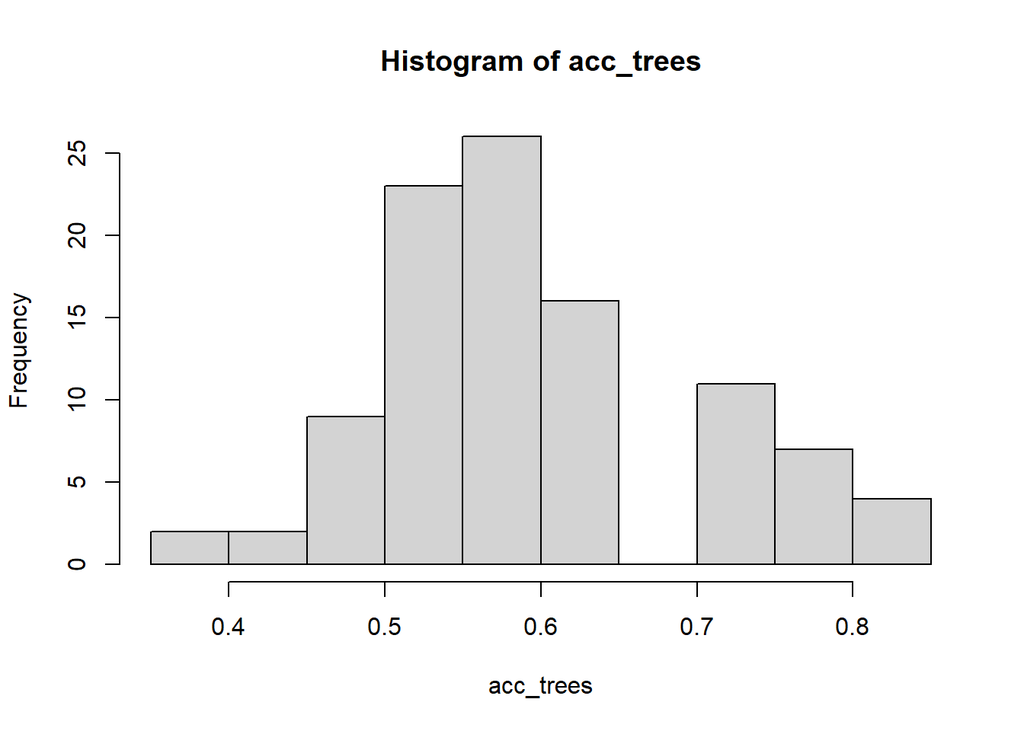

```r
# acc
acc_trees <- acc[1,]
hist(acc_trees)
```

```r
mean(acc_trees)
```

```
## [1] 0.6
```

```r
median(acc_trees)
```

```
## [1] 0.5882353
```

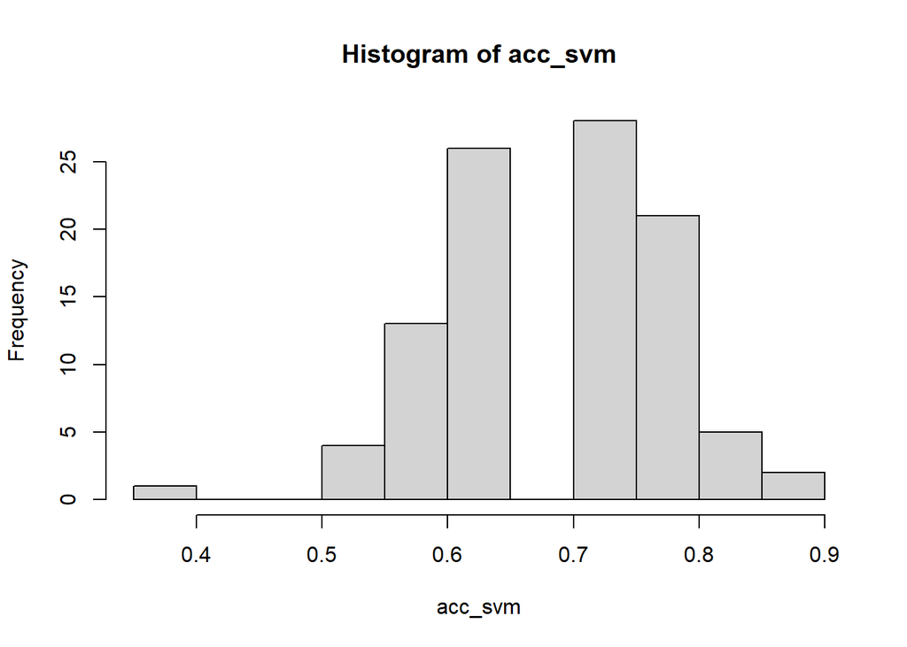

```r
acc_svm <- acc[2,]
hist(acc_svm)
```

```r
mean(acc_svm)
```

```
## [1] 0.6864706
```

```r
median(acc_svm)
```

```
## [1] 0.7058824
```

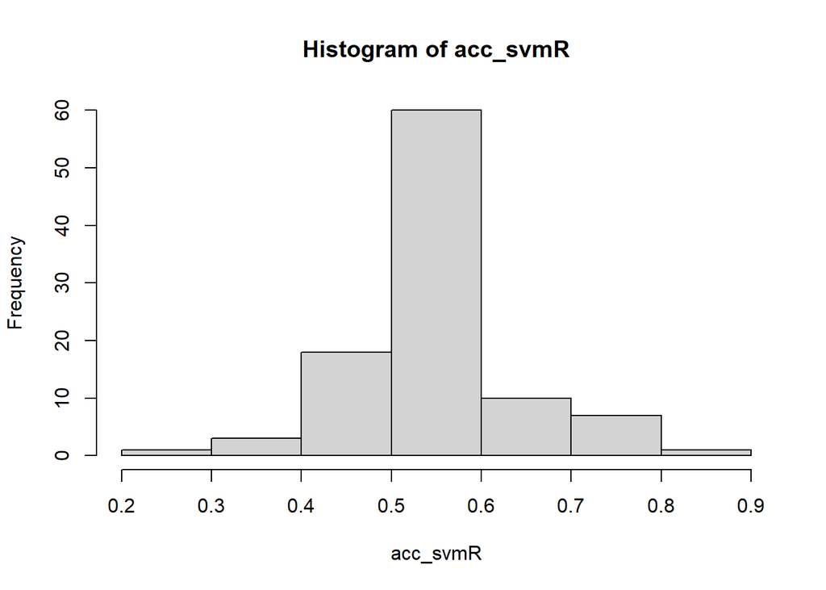

```r
acc_svmR <- acc[3,]
hist(acc_svmR)
```

```r
mean(acc_svmR)
```

```
## [1] 0.5411765
```

```r
median(acc_svmR)
```

```
## [1] 0.5294118
```